# Practical Machine Learning: predicting quality activity

LOGp

17/08/2014

```r
library(ggplot2)
library(caret)
```

## Download and load data

### Download

```r
train_url = "https://d396qusza40orc.cloudfront.net/predmachlearn/pml-training.csv"
train_file = "train.csv"
test_url = "https://d396qusza40orc.cloudfront.net/predmachlearn/pml-testing.csv"
test_file = "test.csv"

download.file(train_url, train_file, "curl")
download.file(test_url, test_file, "curl")
```

### Load data into R

```r
train = read.csv(train_file)
test = read.csv(test_file)
```

### Plot classe data

Just to see if the classes are balanced:

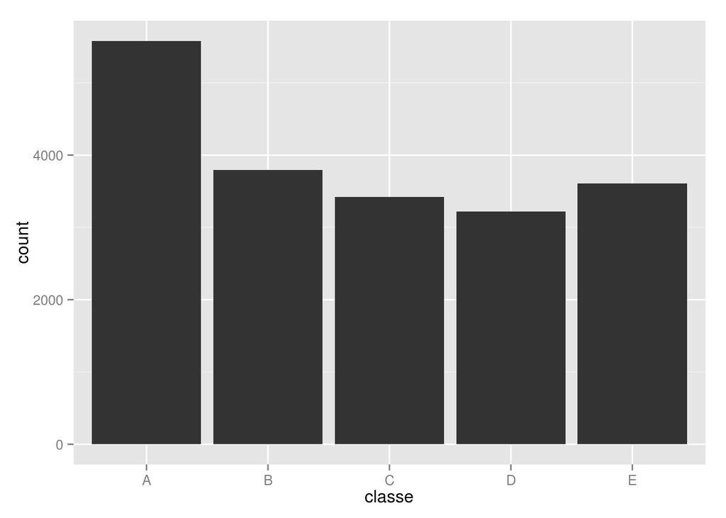

```r
qplot(classe, data=train)
```

### Clean data

Check the data types of data, and cast numerical values to numeric class.

```r
for (col in c("kurtosis_roll_belt", "kurtosis_picth_belt", "kurtosis_yaw_belt", "skewness_roll_belt",
              "skewness_roll_belt.1", "skewness_yaw_belt", "max_yaw_belt", "min_yaw_belt",
              "amplitude_yaw_belt", "kurtosis_roll_arm", "kurtosis_picth_arm", "skewness_yaw_arm",
              "kurtosis_roll_dumbbell", "kurtosis_picth_dumbbell", "kurtosis_yaw_dumbbell",
              "skewness_roll_dumbbell", "skewness_pitch_dumbbell", "skewness_yaw_dumbbell",
              "max_yaw_dumbbell", "min_yaw_dumbbell", "amplitude_yaw_dumbbell", "kurtosis_roll_forearm",
              "kurtosis_picth_forearm", "kurtosis_yaw_forearm", "skewness_roll_forearm",
              "skewness_pitch_forearm", "skewness_yaw_forearm", "max_yaw_forearm",
              "min_yaw_forearm", "amplitude_yaw_forearm", "kurtosis_yaw_arm", "skewness_roll_arm",
              "skewness_pitch_arm")) {
  train[[col]] = as.numeric(as.character(train[[col]]))
}
```

[output not shown]

Remove the first column (X) as it is only an index

```r
train = train[, -1]
test = test[, -1]
```

### Define functions for prediction

Remove features with unique values

```r
remove_unary_features = function (X) {
  cardinality = sapply(X, function(x) {length(unique(x))})
  cardinality == 1
}
```

Populate NA values: * median for numeric and values

```r
set_NA = function (x) {
  if (class(x) %in% c("numeric", "integer")) {
    m = median(x, na.rm=TRUE)
    if (class(x) == "integer") {
      m = as.integer(m)
    }
    m
  }
  else {
    NA
  }
}

get_means = function (X) {
  x = lapply(X, set_NA)
  as.data.frame(x)
}

populate_NAs = function (X, means) {
  result = mapply(function (x, y) {
    u = is.na(x)
    x[u] = y
    x
  }, X, means)
  as.data.frame(result)
}
```

## Prediction model

I will train a mutliple logistic regression model, and evaluate the prediction error via cross-validation. For that purpose, I will perform 5 regressions, for each class value, and then select the classe as the one with the hightest probability.

```r
build_predictor = function(X, alpha = 1, n.features = 1, features = NA) {
# print(paste("build:", n.features))
  p = ncol(X)
  # Remove classe column
  X = X[, -c(p-1)]
  u = names(X)
  u = u[!u == "y"]
  if (! is.na(features)) {
    tmp = strsplit(features, " \\+ ")[[1]]
    u = u[!u %in% tmp]
  }
  p = length(u)
  n.features = min(n.features, p)
  # i: number of features
  for (i in 1:n.features) {
    fit.feature = function(feature) {
    fmla = if(is.na(features))
      paste("y ~ ", feature) else paste("y ~ ", paste(feature, features, sep=" + "))
# print(fmla)
    lm.fit = glm(fmla, data=X, family=binomial)
# print(summary(lm.fit)$coefficients)
# print(summary(lm.fit)$coefficients[2, 4])
    max(summary(lm.fit)$coefficients[, 4])
    }
    significance = sort(sapply(u, fit.feature))[1]
# print(significance)
    u = u[!u == names(significance)]
    if (significance < alpha) {
      # Cbind the most significant feature to features
      features = if (is.na(features))
        names(significance) else paste(features, names(significance), sep=" + ")
    }
    else {
      break
    }
  }
  fmla = paste("y ~ ", paste(features, sep=" + "))
print(fmla)
  features = paste(features, sep=" + ")
  glm.fit = glm(fmla, data=X, family=binomial)
  list(model = glm.fit, features = features)
}
```

### Cross validation

Define 5-folds cross-validation groups:

```r
k=5
set.seed(1324)
folds = createFolds(train$classe, k=k, list=TRUE)
```

Run cross-validation

```r
compute_errors = function(n.features = 1, features = matrix(nrow = k, ncol = 5)) {
  errors = list()
   for (i in 1:k) {
    data.train = train[-folds[[i]], ]
    # Set NA values to means values, for each column
    u.means = get_means(data.train)
    data.train = populate_NAs(data.train, u.means)
    # Remove columns with unique values
    u.remove = remove_unary_features(data.train)
    data.train = data.train[, !u.remove]

    # Move predictor training to a dedicated function
    ## Split classes to build 5 predictors
    predictors = list()
    for (j in 1:5) {
      # Preprocess data for level j
      data.train$y = data.train$classe == j
      # Build predictor for level j
      answer = build_predictor(data.train, n.features=n.features, features = features[i, j])
      predictors[[j]] = answer[[1]]
      features[i, j] <- answer[[2]]
    }

    # Evaluate prediction accuracy from test data
    data.test = train[folds[[i]], ]
    ## Preprocess data
    ### NAs set to means
    data.test = populate_NAs(data.test, u.means)
    ### Columns drop
    data.test = data.test[, !u.remove]
    ## Predict
    predicted = lapply(predictors, predict, newdata=data.test)
    predicted = as.data.frame(predicted)
    ## Get the highest probability as the classe
    predictions = as.integer(apply(predicted, 1, which.max))
    ## Compute test accuracy
    errors[[i]] = 1 - sum(predictions == unclass(data.test$classe)) / nrow(data.test)
  print(errors[[i]])
  }
  list(errors = as.numeric(errors), features = features)
}
```

### Get values for different number of predictors

```r
i = 1
features = list()
set.seed(1564286)
answer = compute_errors(1)
```

```
## [1] "y ~  magnet_arm_x"
## [1] "y ~  accel_dumbbell_x"
## [1] "y ~  roll_dumbbell"
## [1] "y ~  pitch_forearm"
## [1] "y ~  magnet_belt_y"
## [1] 0.5492
## [1] "y ~  magnet_arm_x"
## [1] "y ~  accel_dumbbell_x"
## [1] "y ~  roll_dumbbell"
## [1] "y ~  pitch_forearm"
## [1] "y ~  magnet_belt_y"
## [1] 0.5588
## [1] "y ~  magnet_arm_x"
## [1] "y ~  accel_dumbbell_x"
## [1] "y ~  roll_dumbbell"
## [1] "y ~  pitch_forearm"
## [1] "y ~  magnet_belt_y"
## [1] 0.5485
## [1] "y ~  magnet_arm_x"
## [1] "y ~  accel_dumbbell_x"
## [1] "y ~  roll_dumbbell"
## [1] "y ~  pitch_forearm"
## [1] "y ~  magnet_belt_y"
## [1] 0.5484
## [1] "y ~  magnet_arm_x"
## [1] "y ~  accel_dumbbell_x"
## [1] "y ~  roll_dumbbell"
## [1] "y ~  pitch_forearm"
## [1] "y ~  magnet_belt_y"
## [1] 0.5609
```

```r
errors[, i] = answer$errors
features[[i]] = answer$features
print(features[[i]])
```

```
##      [,1]           [,2]               [,3]            [,4]
## [1,] "magnet_arm_x" "accel_dumbbell_x" "roll_dumbbell" "pitch_forearm"
## [2,] "magnet_arm_x" "accel_dumbbell_x" "roll_dumbbell" "pitch_forearm"
## [3,] "magnet_arm_x" "accel_dumbbell_x" "roll_dumbbell" "pitch_forearm"
## [4,] "magnet_arm_x" "accel_dumbbell_x" "roll_dumbbell" "pitch_forearm"
## [5,] "magnet_arm_x" "accel_dumbbell_x" "roll_dumbbell" "pitch_forearm"
##      [,5]
## [1,] "magnet_belt_y"
## [2,] "magnet_belt_y"
## [3,] "magnet_belt_y"
## [4,] "magnet_belt_y"
## [5,] "magnet_belt_y"
```

```r
print(errors[, i])
```

```
## [1] 0.5492 0.5588 0.5485 0.5484 0.5609
```

```r
i = i +1
print(i)
```

```
## [1] 2
```

```r
set.seed(1564286)
answer = compute_errors(1, features = features[[i-1]])
```

```
## [1] "y ~  magnet_arm_x + pitch_forearm"
## [1] "y ~  accel_dumbbell_x + accel_dumbbell_y"
## [1] "y ~  roll_dumbbell + yaw_dumbbell"
## [1] "y ~  pitch_forearm + roll_dumbbell"
## [1] "y ~  magnet_belt_y + magnet_arm_y"
## [1] 0.515
## [1] "y ~  magnet_arm_x + pitch_forearm"
## [1] "y ~  accel_dumbbell_x + accel_dumbbell_y"
## [1] "y ~  roll_dumbbell + yaw_dumbbell"
## [1] "y ~  pitch_forearm + roll_dumbbell"
## [1] "y ~  magnet_belt_y + magnet_arm_x"
## [1] 0.5083
## [1] "y ~  magnet_arm_x + pitch_forearm"
## [1] "y ~  accel_dumbbell_x + total_accel_dumbbell"
## [1] "y ~  roll_dumbbell + yaw_dumbbell"
## [1] "y ~  pitch_forearm + roll_dumbbell"
## [1] "y ~  magnet_belt_y + accel_dumbbell_y"
## [1] 0.5136
## [1] "y ~  magnet_arm_x + pitch_forearm"
## [1] "y ~  accel_dumbbell_x + total_accel_dumbbell"
## [1] "y ~  roll_dumbbell + yaw_dumbbell"
## [1] "y ~  pitch_forearm + roll_dumbbell"
## [1] "y ~  magnet_belt_y + magnet_arm_y"
## [1] 0.525
## [1] "y ~  magnet_arm_x + pitch_forearm"
## [1] "y ~  accel_dumbbell_x + total_accel_dumbbell"
## [1] "y ~  roll_dumbbell + yaw_dumbbell"
## [1] "y ~  pitch_forearm + roll_dumbbell"
## [1] "y ~  magnet_belt_y + magnet_arm_x"
## [1] 0.5321
```

```r
errors[, i] = answer$errors
features[[i]] = answer$features
print(features[[i]])
```

```
##      [,1]
## [1,] "magnet_arm_x + pitch_forearm"
## [2,] "magnet_arm_x + pitch_forearm"
## [3,] "magnet_arm_x + pitch_forearm"
## [4,] "magnet_arm_x + pitch_forearm"
## [5,] "magnet_arm_x + pitch_forearm"
##      [,2]
## [1,] "accel_dumbbell_x + accel_dumbbell_y"
## [2,] "accel_dumbbell_x + accel_dumbbell_y"
## [3,] "accel_dumbbell_x + total_accel_dumbbell"
## [4,] "accel_dumbbell_x + total_accel_dumbbell"
## [5,] "accel_dumbbell_x + total_accel_dumbbell"
##      [,3]                           [,4]
## [1,] "roll_dumbbell + yaw_dumbbell" "pitch_forearm + roll_dumbbell"
## [2,] "roll_dumbbell + yaw_dumbbell" "pitch_forearm + roll_dumbbell"
## [3,] "roll_dumbbell + yaw_dumbbell" "pitch_forearm + roll_dumbbell"
## [4,] "roll_dumbbell + yaw_dumbbell" "pitch_forearm + roll_dumbbell"
## [5,] "roll_dumbbell + yaw_dumbbell" "pitch_forearm + roll_dumbbell"
##      [,5]
## [1,] "magnet_belt_y + magnet_arm_y"
## [2,] "magnet_belt_y + magnet_arm_x"
## [3,] "magnet_belt_y + accel_dumbbell_y"
## [4,] "magnet_belt_y + magnet_arm_y"
## [5,] "magnet_belt_y + magnet_arm_x"
```

```r
print(errors[, i])
```

```
## [1] 0.5150 0.5083 0.5136 0.5250 0.5321
```

```r
i = i +1
print(i)
```

```
## [1] 3
```

```r
set.seed(1564286)
answer = compute_errors(1, features = features[[i-1]])
```

```
## [1] "y ~  magnet_arm_x + pitch_forearm + magnet_dumbbell_z"
## [1] "y ~  accel_dumbbell_x + accel_dumbbell_y + num_window"
## [1] "y ~  roll_dumbbell + yaw_dumbbell + roll_forearm"
## [1] "y ~  pitch_forearm + roll_dumbbell + accel_arm_x"
## [1] "y ~  magnet_belt_y + magnet_arm_y + total_accel_dumbbell"
## [1] 0.4817
## [1] "y ~  magnet_arm_x + pitch_forearm + magnet_dumbbell_z"
## [1] "y ~  accel_dumbbell_x + accel_dumbbell_y + num_window"
## [1] "y ~  roll_dumbbell + yaw_dumbbell + roll_forearm"
## [1] "y ~  pitch_forearm + roll_dumbbell + accel_arm_x"
## [1] "y ~  magnet_belt_y + magnet_arm_x + total_accel_dumbbell"
## [1] 0.4723
## [1] "y ~  magnet_arm_x + pitch_forearm + magnet_dumbbell_z"
## [1] "y ~  accel_dumbbell_x + total_accel_dumbbell + num_window"
## [1] "y ~  roll_dumbbell + yaw_dumbbell + accel_forearm_y"
## [1] "y ~  pitch_forearm + roll_dumbbell + magnet_arm_x"
## [1] "y ~  magnet_belt_y + accel_dumbbell_y + magnet_arm_y"
## [1] 0.4945
## [1] "y ~  magnet_arm_x + pitch_forearm + total_accel_forearm"
## [1] "y ~  accel_dumbbell_x + total_accel_dumbbell + num_window"
## [1] "y ~  roll_dumbbell + yaw_dumbbell + roll_forearm"
## [1] "y ~  pitch_forearm + roll_dumbbell + total_accel_forearm"
## [1] "y ~  magnet_belt_y + magnet_arm_y + total_accel_dumbbell"
## [1] 0.5048
## [1] "y ~  magnet_arm_x + pitch_forearm + total_accel_forearm"
## [1] "y ~  accel_dumbbell_x + total_accel_dumbbell + num_window"
## [1] "y ~  roll_dumbbell + yaw_dumbbell + roll_forearm"
## [1] "y ~  pitch_forearm + roll_dumbbell + magnet_arm_x"
## [1] "y ~  magnet_belt_y + magnet_arm_x + total_accel_dumbbell"
## [1] 0.5158
```

```r
errors[, i] = answer$errors
features[[i]] = answer$features
print(features[[i]])
```

```
##      [,1]
## [1,] "magnet_arm_x + pitch_forearm + magnet_dumbbell_z"
## [2,] "magnet_arm_x + pitch_forearm + magnet_dumbbell_z"
## [3,] "magnet_arm_x + pitch_forearm + magnet_dumbbell_z"
## [4,] "magnet_arm_x + pitch_forearm + total_accel_forearm"
## [5,] "magnet_arm_x + pitch_forearm + total_accel_forearm"
##      [,2]
## [1,] "accel_dumbbell_x + accel_dumbbell_y + num_window"
## [2,] "accel_dumbbell_x + accel_dumbbell_y + num_window"
## [3,] "accel_dumbbell_x + total_accel_dumbbell + num_window"
## [4,] "accel_dumbbell_x + total_accel_dumbbell + num_window"
## [5,] "accel_dumbbell_x + total_accel_dumbbell + num_window"
##      [,3]
## [1,] "roll_dumbbell + yaw_dumbbell + roll_forearm"
## [2,] "roll_dumbbell + yaw_dumbbell + roll_forearm"
## [3,] "roll_dumbbell + yaw_dumbbell + accel_forearm_y"
## [4,] "roll_dumbbell + yaw_dumbbell + roll_forearm"
## [5,] "roll_dumbbell + yaw_dumbbell + roll_forearm"
##      [,4]
## [1,] "pitch_forearm + roll_dumbbell + accel_arm_x"
## [2,] "pitch_forearm + roll_dumbbell + accel_arm_x"
## [3,] "pitch_forearm + roll_dumbbell + magnet_arm_x"
## [4,] "pitch_forearm + roll_dumbbell + total_accel_forearm"
## [5,] "pitch_forearm + roll_dumbbell + magnet_arm_x"
##      [,5]
## [1,] "magnet_belt_y + magnet_arm_y + total_accel_dumbbell"
## [2,] "magnet_belt_y + magnet_arm_x + total_accel_dumbbell"
## [3,] "magnet_belt_y + accel_dumbbell_y + magnet_arm_y"
## [4,] "magnet_belt_y + magnet_arm_y + total_accel_dumbbell"
## [5,] "magnet_belt_y + magnet_arm_x + total_accel_dumbbell"
```

```r
print(errors[, i])
```

```
## [1] 0.4817 0.4723 0.4945 0.5048 0.5158
```

```r
i = i +1
print(i)
```

```
## [1] 4
```

```r
set.seed(1564286)
answer = compute_errors(1, features = features[[i-1]])
```

```
## [1] "y ~  magnet_arm_x + pitch_forearm + magnet_dumbbell_z + raw_timestamp_part_1"
## [1] "y ~  accel_dumbbell_x + accel_dumbbell_y + num_window + magnet_arm_z"
## [1] "y ~  roll_dumbbell + yaw_dumbbell + roll_forearm + num_window"
## [1] "y ~  pitch_forearm + roll_dumbbell + accel_arm_x + magnet_arm_z"
## [1] "y ~  magnet_belt_y + magnet_arm_y + total_accel_dumbbell + accel_forearm_z"
## [1] 0.4646
## [1] "y ~  magnet_arm_x + pitch_forearm + magnet_dumbbell_z + raw_timestamp_part_1"
## [1] "y ~  accel_dumbbell_x + accel_dumbbell_y + num_window + magnet_arm_z"
## [1] "y ~  roll_dumbbell + yaw_dumbbell + roll_forearm + accel_forearm_y"
## [1] "y ~  pitch_forearm + roll_dumbbell + accel_arm_x + magnet_arm_z"
## [1] "y ~  magnet_belt_y + magnet_arm_x + total_accel_dumbbell + accel_forearm_z"
## [1] 0.4548
## [1] "y ~  magnet_arm_x + pitch_forearm + magnet_dumbbell_z + raw_timestamp_part_1"
## [1] "y ~  accel_dumbbell_x + total_accel_dumbbell + num_window + magnet_arm_z"
## [1] "y ~  roll_dumbbell + yaw_dumbbell + accel_forearm_y + magnet_belt_y"
## [1] "y ~  pitch_forearm + roll_dumbbell + magnet_arm_x + magnet_arm_z"
## [1] "y ~  magnet_belt_y + accel_dumbbell_y + magnet_arm_y + accel_forearm_z"
## [1] 0.4777
## [1] "y ~  magnet_arm_x + pitch_forearm + total_accel_forearm + magnet_dumbbell_z"
## [1] "y ~  accel_dumbbell_x + total_accel_dumbbell + num_window + magnet_arm_z"
## [1] "y ~  roll_dumbbell + yaw_dumbbell + roll_forearm + num_window"
## [1] "y ~  pitch_forearm + roll_dumbbell + total_accel_forearm + accel_arm_x"
## [1] "y ~  magnet_belt_y + magnet_arm_y + total_accel_dumbbell + accel_forearm_z"
## [1] 0.4712
## [1] "y ~  magnet_arm_x + pitch_forearm + total_accel_forearm + magnet_dumbbell_z"
## [1] "y ~  accel_dumbbell_x + total_accel_dumbbell + num_window + magnet_arm_z"
## [1] "y ~  roll_dumbbell + yaw_dumbbell + roll_forearm + accel_forearm_y"
## [1] "y ~  pitch_forearm + roll_dumbbell + magnet_arm_x + magnet_arm_z"
## [1] "y ~  magnet_belt_y + magnet_arm_x + total_accel_dumbbell + accel_forearm_z"
## [1] 0.4975
```

```r
errors[, i] = answer$errors
features[[i]] = answer$features
print(features[[i]])
```

```
##      [,1]
## [1,] "magnet_arm_x + pitch_forearm + magnet_dumbbell_z + raw_timestamp_part_1"
## [2,] "magnet_arm_x + pitch_forearm + magnet_dumbbell_z + raw_timestamp_part_1"
## [3,] "magnet_arm_x + pitch_forearm + magnet_dumbbell_z + raw_timestamp_part_1"
## [4,] "magnet_arm_x + pitch_forearm + total_accel_forearm + magnet_dumbbell_z"
## [5,] "magnet_arm_x + pitch_forearm + total_accel_forearm + magnet_dumbbell_z"
##      [,2]
## [1,] "accel_dumbbell_x + accel_dumbbell_y + num_window + magnet_arm_z"
## [2,] "accel_dumbbell_x + accel_dumbbell_y + num_window + magnet_arm_z"
## [3,] "accel_dumbbell_x + total_accel_dumbbell + num_window + magnet_arm_z"
## [4,] "accel_dumbbell_x + total_accel_dumbbell + num_window + magnet_arm_z"
## [5,] "accel_dumbbell_x + total_accel_dumbbell + num_window + magnet_arm_z"
##      [,3]
## [1,] "roll_dumbbell + yaw_dumbbell + roll_forearm + num_window"
## [2,] "roll_dumbbell + yaw_dumbbell + roll_forearm + accel_forearm_y"
## [3,] "roll_dumbbell + yaw_dumbbell + accel_forearm_y + magnet_belt_y"
## [4,] "roll_dumbbell + yaw_dumbbell + roll_forearm + num_window"
## [5,] "roll_dumbbell + yaw_dumbbell + roll_forearm + accel_forearm_y"
##      [,4]
## [1,] "pitch_forearm + roll_dumbbell + accel_arm_x + magnet_arm_z"
## [2,] "pitch_forearm + roll_dumbbell + accel_arm_x + magnet_arm_z"
## [3,] "pitch_forearm + roll_dumbbell + magnet_arm_x + magnet_arm_z"
## [4,] "pitch_forearm + roll_dumbbell + total_accel_forearm + accel_arm_x"
## [5,] "pitch_forearm + roll_dumbbell + magnet_arm_x + magnet_arm_z"
##      [,5]
## [1,] "magnet_belt_y + magnet_arm_y + total_accel_dumbbell + accel_forearm_z"
## [2,] "magnet_belt_y + magnet_arm_x + total_accel_dumbbell + accel_forearm_z"
## [3,] "magnet_belt_y + accel_dumbbell_y + magnet_arm_y + accel_forearm_z"
## [4,] "magnet_belt_y + magnet_arm_y + total_accel_dumbbell + accel_forearm_z"
## [5,] "magnet_belt_y + magnet_arm_x + total_accel_dumbbell + accel_forearm_z"
```

```r
print(errors[, i])
```

```
## [1] 0.4646 0.4548 0.4777 0.4712 0.4975
```

```r
i = i +1
print(i)
```

```
## [1] 5
```

```r
set.seed(1564286)
answer = compute_errors(1, features = features[[i-1]])
```

```
## [1] "y ~  magnet_arm_x + pitch_forearm + magnet_dumbbell_z + raw_timestamp_part_1 + yaw_dumbbell"
## [1] "y ~  accel_dumbbell_x + accel_dumbbell_y + num_window + magnet_arm_z + magnet_arm_y"
## [1] "y ~  roll_dumbbell + yaw_dumbbell + roll_forearm + num_window + accel_forearm_y"
## [1] "y ~  pitch_forearm + roll_dumbbell + accel_arm_x + magnet_arm_z + magnet_dumbbell_x"
## [1] "y ~  magnet_belt_y + magnet_arm_y + total_accel_dumbbell + accel_forearm_z + accel_arm_z"
## [1] 0.4472
## [1] "y ~  magnet_arm_x + pitch_forearm + magnet_dumbbell_z + raw_timestamp_part_1 + total_accel_forearm"
## [1] "y ~  accel_dumbbell_x + accel_dumbbell_y + num_window + magnet_arm_z + magnet_arm_y"
## [1] "y ~  roll_dumbbell + yaw_dumbbell + roll_forearm + accel_forearm_y + num_window"
## [1] "y ~  pitch_forearm + roll_dumbbell + accel_arm_x + magnet_arm_z + magnet_dumbbell_x"
## [1] "y ~  magnet_belt_y + magnet_arm_x + total_accel_dumbbell + accel_forearm_z + magnet_dumbbell_y"
## [1] 0.4456
## [1] "y ~  magnet_arm_x + pitch_forearm + magnet_dumbbell_z + raw_timestamp_part_1 + yaw_dumbbell"
## [1] "y ~  accel_dumbbell_x + total_accel_dumbbell + num_window + magnet_arm_z + magnet_arm_y"
## [1] "y ~  roll_dumbbell + yaw_dumbbell + accel_forearm_y + magnet_belt_y + magnet_dumbbell_z"
## [1] "y ~  pitch_forearm + roll_dumbbell + magnet_arm_x + magnet_arm_z + total_accel_forearm"
## [1] "y ~  magnet_belt_y + accel_dumbbell_y + magnet_arm_y + accel_forearm_z + accel_arm_z"
## [1] 0.4619
## [1] "y ~  magnet_arm_x + pitch_forearm + total_accel_forearm + magnet_dumbbell_z + raw_timestamp_part_1"
## [1] "y ~  accel_dumbbell_x + total_accel_dumbbell + num_window + magnet_arm_z + magnet_arm_y"
## [1] "y ~  roll_dumbbell + yaw_dumbbell + roll_forearm + num_window + accel_forearm_y"
## [1] "y ~  pitch_forearm + roll_dumbbell + total_accel_forearm + accel_arm_x + raw_timestamp_part_1"
## [1] "y ~  magnet_belt_y + magnet_arm_y + total_accel_dumbbell + accel_forearm_z + accel_arm_z"
## [1] 0.4771
## [1] "y ~  magnet_arm_x + pitch_forearm + total_accel_forearm + magnet_dumbbell_z + raw_timestamp_part_1"
## [1] "y ~  accel_dumbbell_x + total_accel_dumbbell + num_window + magnet_arm_z + magnet_arm_y"
## [1] "y ~  roll_dumbbell + yaw_dumbbell + roll_forearm + accel_forearm_y + num_window"
## [1] "y ~  pitch_forearm + roll_dumbbell + magnet_arm_x + magnet_arm_z + total_accel_forearm"
## [1] "y ~  magnet_belt_y + magnet_arm_x + total_accel_dumbbell + accel_forearm_z + magnet_dumbbell_y"
## [1] 0.4725
```

```r
errors[, i] = answer$errors
features[[i]] = answer$features
print(features[[i]])
```

```
##      [,1]
## [1,] "magnet_arm_x + pitch_forearm + magnet_dumbbell_z + raw_timestamp_part_1 + yaw_dumbbell"
## [2,] "magnet_arm_x + pitch_forearm + magnet_dumbbell_z + raw_timestamp_part_1 + total_accel_forearm"
## [3,] "magnet_arm_x + pitch_forearm + magnet_dumbbell_z + raw_timestamp_part_1 + yaw_dumbbell"
## [4,] "magnet_arm_x + pitch_forearm + total_accel_forearm + magnet_dumbbell_z + raw_timestamp_part_1"
## [5,] "magnet_arm_x + pitch_forearm + total_accel_forearm + magnet_dumbbell_z + raw_timestamp_part_1"
##      [,2]
## [1,] "accel_dumbbell_x + accel_dumbbell_y + num_window + magnet_arm_z + magnet_arm_y"
## [2,] "accel_dumbbell_x + accel_dumbbell_y + num_window + magnet_arm_z + magnet_arm_y"
## [3,] "accel_dumbbell_x + total_accel_dumbbell + num_window + magnet_arm_z + magnet_arm_y"
## [4,] "accel_dumbbell_x + total_accel_dumbbell + num_window + magnet_arm_z + magnet_arm_y"
## [5,] "accel_dumbbell_x + total_accel_dumbbell + num_window + magnet_arm_z + magnet_arm_y"
##      [,3]
## [1,] "roll_dumbbell + yaw_dumbbell + roll_forearm + num_window + accel_forearm_y"
## [2,] "roll_dumbbell + yaw_dumbbell + roll_forearm + accel_forearm_y + num_window"
## [3,] "roll_dumbbell + yaw_dumbbell + accel_forearm_y + magnet_belt_y + magnet_dumbbell_z"
## [4,] "roll_dumbbell + yaw_dumbbell + roll_forearm + num_window + accel_forearm_y"
## [5,] "roll_dumbbell + yaw_dumbbell + roll_forearm + accel_forearm_y + num_window"
##      [,4]
## [1,] "pitch_forearm + roll_dumbbell + accel_arm_x + magnet_arm_z + magnet_dumbbell_x"
## [2,] "pitch_forearm + roll_dumbbell + accel_arm_x + magnet_arm_z + magnet_dumbbell_x"
## [3,] "pitch_forearm + roll_dumbbell + magnet_arm_x + magnet_arm_z + total_accel_forearm"
## [4,] "pitch_forearm + roll_dumbbell + total_accel_forearm + accel_arm_x + raw_timestamp_part_1"
## [5,] "pitch_forearm + roll_dumbbell + magnet_arm_x + magnet_arm_z + total_accel_forearm"
##      [,5]
## [1,] "magnet_belt_y + magnet_arm_y + total_accel_dumbbell + accel_forearm_z + accel_arm_z"
## [2,] "magnet_belt_y + magnet_arm_x + total_accel_dumbbell + accel_forearm_z + magnet_dumbbell_y"
## [3,] "magnet_belt_y + accel_dumbbell_y + magnet_arm_y + accel_forearm_z + accel_arm_z"
## [4,] "magnet_belt_y + magnet_arm_y + total_accel_dumbbell + accel_forearm_z + accel_arm_z"
## [5,] "magnet_belt_y + magnet_arm_x + total_accel_dumbbell + accel_forearm_z + magnet_dumbbell_y"
```

```r
print(errors[, i])
```

```
## [1] 0.4472 0.4456 0.4619 0.4771 0.4725
```

```r
i = i +1
print(i)
```

```
## [1] 6
```

```r
set.seed(1564286)
answer = compute_errors(1, features = features[[i-1]])
```

```
## [1] "y ~  magnet_arm_x + pitch_forearm + magnet_dumbbell_z + raw_timestamp_part_1 + yaw_dumbbell + pitch_belt"
## [1] "y ~  accel_dumbbell_x + accel_dumbbell_y + num_window + magnet_arm_z + magnet_arm_y + magnet_belt_y"
## [1] "y ~  roll_dumbbell + yaw_dumbbell + roll_forearm + num_window + accel_forearm_y + magnet_belt_y"
## [1] "y ~  pitch_forearm + roll_dumbbell + accel_arm_x + magnet_arm_z + magnet_dumbbell_x + magnet_dumbbell_z"
## [1] "y ~  magnet_belt_y + magnet_arm_y + total_accel_dumbbell + accel_forearm_z + accel_arm_z + magnet_dumbbell_y"
## [1] 0.4294
## [1] "y ~  magnet_arm_x + pitch_forearm + magnet_dumbbell_z + raw_timestamp_part_1 + total_accel_forearm + num_window"
## [1] "y ~  accel_dumbbell_x + accel_dumbbell_y + num_window + magnet_arm_z + magnet_arm_y + accel_arm_z"
## [1] "y ~  roll_dumbbell + yaw_dumbbell + roll_forearm + accel_forearm_y + num_window + magnet_belt_y"
## [1] "y ~  pitch_forearm + roll_dumbbell + accel_arm_x + magnet_arm_z + magnet_dumbbell_x + magnet_dumbbell_z"
## [1] "y ~  magnet_belt_y + magnet_arm_x + total_accel_dumbbell + accel_forearm_z + magnet_dumbbell_y + magnet_dumbbell_z"
## [1] 0.4308
## [1] "y ~  magnet_arm_x + pitch_forearm + magnet_dumbbell_z + raw_timestamp_part_1 + yaw_dumbbell + pitch_belt"
## [1] "y ~  accel_dumbbell_x + total_accel_dumbbell + num_window + magnet_arm_z + magnet_arm_y + magnet_belt_y"
## [1] "y ~  roll_dumbbell + yaw_dumbbell + accel_forearm_y + magnet_belt_y + magnet_dumbbell_z + accel_belt_y"
## [1] "y ~  pitch_forearm + roll_dumbbell + magnet_arm_x + magnet_arm_z + total_accel_forearm + magnet_dumbbell_z"
## [1] "y ~  magnet_belt_y + accel_dumbbell_y + magnet_arm_y + accel_forearm_z + accel_arm_z + magnet_dumbbell_z"
## [1] 0.4578
## [1] "y ~  magnet_arm_x + pitch_forearm + total_accel_forearm + magnet_dumbbell_z + raw_timestamp_part_1 + num_window"
## [1] "y ~  accel_dumbbell_x + total_accel_dumbbell + num_window + magnet_arm_z + magnet_arm_y + magnet_belt_y"
## [1] "y ~  roll_dumbbell + yaw_dumbbell + roll_forearm + num_window + accel_forearm_y + magnet_dumbbell_z"
## [1] "y ~  pitch_forearm + roll_dumbbell + total_accel_forearm + accel_arm_x + raw_timestamp_part_1 + magnet_arm_z"
## [1] "y ~  magnet_belt_y + magnet_arm_y + total_accel_dumbbell + accel_forearm_z + accel_arm_z + magnet_dumbbell_y"
## [1] 0.4439
## [1] "y ~  magnet_arm_x + pitch_forearm + total_accel_forearm + magnet_dumbbell_z + raw_timestamp_part_1 + num_window"
## [1] "y ~  accel_dumbbell_x + total_accel_dumbbell + num_window + magnet_arm_z + magnet_arm_y + magnet_belt_y"
## [1] "y ~  roll_dumbbell + yaw_dumbbell + roll_forearm + accel_forearm_y + num_window + magnet_belt_y"
## [1] "y ~  pitch_forearm + roll_dumbbell + magnet_arm_x + magnet_arm_z + total_accel_forearm + magnet_dumbbell_z"
## [1] "y ~  magnet_belt_y + magnet_arm_x + total_accel_dumbbell + accel_forearm_z + magnet_dumbbell_y + total_accel_forearm"
## [1] 0.447
```

```r
errors[, i] = answer$errors
features[[i]] = answer$features
print(features[[i]])
```

```
##      [,1]
## [1,] "magnet_arm_x + pitch_forearm + magnet_dumbbell_z + raw_timestamp_part_1 + yaw_dumbbell + pitch_belt"
## [2,] "magnet_arm_x + pitch_forearm + magnet_dumbbell_z + raw_timestamp_part_1 + total_accel_forearm + num_window"
## [3,] "magnet_arm_x + pitch_forearm + magnet_dumbbell_z + raw_timestamp_part_1 + yaw_dumbbell + pitch_belt"
## [4,] "magnet_arm_x + pitch_forearm + total_accel_forearm + magnet_dumbbell_z + raw_timestamp_part_1 + num_window"
## [5,] "magnet_arm_x + pitch_forearm + total_accel_forearm + magnet_dumbbell_z + raw_timestamp_part_1 + num_window"
##      [,2]
## [1,] "accel_dumbbell_x + accel_dumbbell_y + num_window + magnet_arm_z + magnet_arm_y + magnet_belt_y"
## [2,] "accel_dumbbell_x + accel_dumbbell_y + num_window + magnet_arm_z + magnet_arm_y + accel_arm_z"
## [3,] "accel_dumbbell_x + total_accel_dumbbell + num_window + magnet_arm_z + magnet_arm_y + magnet_belt_y"
## [4,] "accel_dumbbell_x + total_accel_dumbbell + num_window + magnet_arm_z + magnet_arm_y + magnet_belt_y"
## [5,] "accel_dumbbell_x + total_accel_dumbbell + num_window + magnet_arm_z + magnet_arm_y + magnet_belt_y"
##      [,3]
## [1,] "roll_dumbbell + yaw_dumbbell + roll_forearm + num_window + accel_forearm_y + magnet_belt_y"
## [2,] "roll_dumbbell + yaw_dumbbell + roll_forearm + accel_forearm_y + num_window + magnet_belt_y"
## [3,] "roll_dumbbell + yaw_dumbbell + accel_forearm_y + magnet_belt_y + magnet_dumbbell_z + accel_belt_y"
## [4,] "roll_dumbbell + yaw_dumbbell + roll_forearm + num_window + accel_forearm_y + magnet_dumbbell_z"
## [5,] "roll_dumbbell + yaw_dumbbell + roll_forearm + accel_forearm_y + num_window + magnet_belt_y"
##      [,4]
## [1,] "pitch_forearm + roll_dumbbell + accel_arm_x + magnet_arm_z + magnet_dumbbell_x + magnet_dumbbell_z"
## [2,] "pitch_forearm + roll_dumbbell + accel_arm_x + magnet_arm_z + magnet_dumbbell_x + magnet_dumbbell_z"
## [3,] "pitch_forearm + roll_dumbbell + magnet_arm_x + magnet_arm_z + total_accel_forearm + magnet_dumbbell_z"
## [4,] "pitch_forearm + roll_dumbbell + total_accel_forearm + accel_arm_x + raw_timestamp_part_1 + magnet_arm_z"
## [5,] "pitch_forearm + roll_dumbbell + magnet_arm_x + magnet_arm_z + total_accel_forearm + magnet_dumbbell_z"
##      [,5]
## [1,] "magnet_belt_y + magnet_arm_y + total_accel_dumbbell + accel_forearm_z + accel_arm_z + magnet_dumbbell_y"
## [2,] "magnet_belt_y + magnet_arm_x + total_accel_dumbbell + accel_forearm_z + magnet_dumbbell_y + magnet_dumbbell_z"
## [3,] "magnet_belt_y + accel_dumbbell_y + magnet_arm_y + accel_forearm_z + accel_arm_z + magnet_dumbbell_z"
## [4,] "magnet_belt_y + magnet_arm_y + total_accel_dumbbell + accel_forearm_z + accel_arm_z + magnet_dumbbell_y"
## [5,] "magnet_belt_y + magnet_arm_x + total_accel_dumbbell + accel_forearm_z + magnet_dumbbell_y + total_accel_forearm"
```

```r
print(errors[, i])
```

```
## [1] 0.4294 0.4308 0.4578 0.4439 0.4470
```

```r
i = i +1
print(i)
```

```
## [1] 7
```

```r
set.seed(1564286)
answer = compute_errors(1, features = features[[i-1]])
```

```
## [1] "y ~  magnet_arm_x + pitch_forearm + magnet_dumbbell_z + raw_timestamp_part_1 + yaw_dumbbell + pitch_belt + accel_belt_z"
## [1] "y ~  accel_dumbbell_x + accel_dumbbell_y + num_window + magnet_arm_z + magnet_arm_y + magnet_belt_y + accel_arm_z"
## [1] "y ~  roll_dumbbell + yaw_dumbbell + roll_forearm + num_window + accel_forearm_y + magnet_belt_y + accel_dumbbell_y"
## [1] "y ~  pitch_forearm + roll_dumbbell + accel_arm_x + magnet_arm_z + magnet_dumbbell_x + magnet_dumbbell_z + magnet_arm_x"
## [1] "y ~  magnet_belt_y + magnet_arm_y + total_accel_dumbbell + accel_forearm_z + accel_arm_z + magnet_dumbbell_y + magnet_dumbbell_z"
## [1] 0.4215
## [1] "y ~  magnet_arm_x + pitch_forearm + magnet_dumbbell_z + raw_timestamp_part_1 + total_accel_forearm + num_window + yaw_dumbbell"
## [1] "y ~  accel_dumbbell_x + accel_dumbbell_y + num_window + magnet_arm_z + magnet_arm_y + accel_arm_z + magnet_belt_y"
## [1] "y ~  roll_dumbbell + yaw_dumbbell + roll_forearm + accel_forearm_y + num_window + magnet_belt_y + accel_dumbbell_y"
## [1] "y ~  pitch_forearm + roll_dumbbell + accel_arm_x + magnet_arm_z + magnet_dumbbell_x + magnet_dumbbell_z + magnet_arm_x"
## [1] "y ~  magnet_belt_y + magnet_arm_x + total_accel_dumbbell + accel_forearm_z + magnet_dumbbell_y + magnet_dumbbell_z + accel_arm_y"
## [1] 0.4252
## [1] "y ~  magnet_arm_x + pitch_forearm + magnet_dumbbell_z + raw_timestamp_part_1 + yaw_dumbbell + pitch_belt + accel_belt_z"
## [1] "y ~  accel_dumbbell_x + total_accel_dumbbell + num_window + magnet_arm_z + magnet_arm_y + magnet_belt_y + accel_arm_z"
## [1] "y ~  roll_dumbbell + yaw_dumbbell + accel_forearm_y + magnet_belt_y + magnet_dumbbell_z + accel_belt_y + accel_forearm_z"
## [1] "y ~  pitch_forearm + roll_dumbbell + magnet_arm_x + magnet_arm_z + total_accel_forearm + magnet_dumbbell_z + accel_dumbbell_y"
## [1] "y ~  magnet_belt_y + accel_dumbbell_y + magnet_arm_y + accel_forearm_z + accel_arm_z + magnet_dumbbell_z + accel_belt_z"
## [1] 0.4548
## [1] "y ~  magnet_arm_x + pitch_forearm + total_accel_forearm + magnet_dumbbell_z + raw_timestamp_part_1 + num_window + yaw_dumbbell"
## [1] "y ~  accel_dumbbell_x + total_accel_dumbbell + num_window + magnet_arm_z + magnet_arm_y + magnet_belt_y + accel_arm_z"
## [1] "y ~  roll_dumbbell + yaw_dumbbell + roll_forearm + num_window + accel_forearm_y + magnet_dumbbell_z + magnet_belt_y"
## [1] "y ~  pitch_forearm + roll_dumbbell + total_accel_forearm + accel_arm_x + raw_timestamp_part_1 + magnet_arm_z + magnet_dumbbell_x"
## [1] "y ~  magnet_belt_y + magnet_arm_y + total_accel_dumbbell + accel_forearm_z + accel_arm_z + magnet_dumbbell_y + magnet_dumbbell_z"
## [1] 0.4276
## [1] "y ~  magnet_arm_x + pitch_forearm + total_accel_forearm + magnet_dumbbell_z + raw_timestamp_part_1 + num_window + yaw_dumbbell"
## [1] "y ~  accel_dumbbell_x + total_accel_dumbbell + num_window + magnet_arm_z + magnet_arm_y + magnet_belt_y + total_accel_arm"
## [1] "y ~  roll_dumbbell + yaw_dumbbell + roll_forearm + accel_forearm_y + num_window + magnet_belt_y + accel_dumbbell_y"
## [1] "y ~  pitch_forearm + roll_dumbbell + magnet_arm_x + magnet_arm_z + total_accel_forearm + magnet_dumbbell_z + total_accel_arm"
## [1] "y ~  magnet_belt_y + magnet_arm_x + total_accel_dumbbell + accel_forearm_z + magnet_dumbbell_y + total_accel_forearm + cvtd_timestamp"
## [1] 0.434
```

```r
errors[, i] = answer$errors
features[[i]] = answer$features
print(features[[i]])
```

```
##      [,1]
## [1,] "magnet_arm_x + pitch_forearm + magnet_dumbbell_z + raw_timestamp_part_1 + yaw_dumbbell + pitch_belt + accel_belt_z"
## [2,] "magnet_arm_x + pitch_forearm + magnet_dumbbell_z + raw_timestamp_part_1 + total_accel_forearm + num_window + yaw_dumbbell"
## [3,] "magnet_arm_x + pitch_forearm + magnet_dumbbell_z + raw_timestamp_part_1 + yaw_dumbbell + pitch_belt + accel_belt_z"
## [4,] "magnet_arm_x + pitch_forearm + total_accel_forearm + magnet_dumbbell_z + raw_timestamp_part_1 + num_window + yaw_dumbbell"
## [5,] "magnet_arm_x + pitch_forearm + total_accel_forearm + magnet_dumbbell_z + raw_timestamp_part_1 + num_window + yaw_dumbbell"
##      [,2]
## [1,] "accel_dumbbell_x + accel_dumbbell_y + num_window + magnet_arm_z + magnet_arm_y + magnet_belt_y + accel_arm_z"
## [2,] "accel_dumbbell_x + accel_dumbbell_y + num_window + magnet_arm_z + magnet_arm_y + accel_arm_z + magnet_belt_y"
## [3,] "accel_dumbbell_x + total_accel_dumbbell + num_window + magnet_arm_z + magnet_arm_y + magnet_belt_y + accel_arm_z"
## [4,] "accel_dumbbell_x + total_accel_dumbbell + num_window + magnet_arm_z + magnet_arm_y + magnet_belt_y + accel_arm_z"
## [5,] "accel_dumbbell_x + total_accel_dumbbell + num_window + magnet_arm_z + magnet_arm_y + magnet_belt_y + total_accel_arm"
##      [,3]
## [1,] "roll_dumbbell + yaw_dumbbell + roll_forearm + num_window + accel_forearm_y + magnet_belt_y + accel_dumbbell_y"
## [2,] "roll_dumbbell + yaw_dumbbell + roll_forearm + accel_forearm_y + num_window + magnet_belt_y + accel_dumbbell_y"
## [3,] "roll_dumbbell + yaw_dumbbell + accel_forearm_y + magnet_belt_y + magnet_dumbbell_z + accel_belt_y + accel_forearm_z"
## [4,] "roll_dumbbell + yaw_dumbbell + roll_forearm + num_window + accel_forearm_y + magnet_dumbbell_z + magnet_belt_y"
## [5,] "roll_dumbbell + yaw_dumbbell + roll_forearm + accel_forearm_y + num_window + magnet_belt_y + accel_dumbbell_y"
##      [,4]
## [1,] "pitch_forearm + roll_dumbbell + accel_arm_x + magnet_arm_z + magnet_dumbbell_x + magnet_dumbbell_z + magnet_arm_x"
## [2,] "pitch_forearm + roll_dumbbell + accel_arm_x + magnet_arm_z + magnet_dumbbell_x + magnet_dumbbell_z + magnet_arm_x"
## [3,] "pitch_forearm + roll_dumbbell + magnet_arm_x + magnet_arm_z + total_accel_forearm + magnet_dumbbell_z + accel_dumbbell_y"
## [4,] "pitch_forearm + roll_dumbbell + total_accel_forearm + accel_arm_x + raw_timestamp_part_1 + magnet_arm_z + magnet_dumbbell_x"
## [5,] "pitch_forearm + roll_dumbbell + magnet_arm_x + magnet_arm_z + total_accel_forearm + magnet_dumbbell_z + total_accel_arm"
##      [,5]
## [1,] "magnet_belt_y + magnet_arm_y + total_accel_dumbbell + accel_forearm_z + accel_arm_z + magnet_dumbbell_y + magnet_dumbbell_z"
## [2,] "magnet_belt_y + magnet_arm_x + total_accel_dumbbell + accel_forearm_z + magnet_dumbbell_y + magnet_dumbbell_z + accel_arm_y"
## [3,] "magnet_belt_y + accel_dumbbell_y + magnet_arm_y + accel_forearm_z + accel_arm_z + magnet_dumbbell_z + accel_belt_z"
## [4,] "magnet_belt_y + magnet_arm_y + total_accel_dumbbell + accel_forearm_z + accel_arm_z + magnet_dumbbell_y + magnet_dumbbell_z"
## [5,] "magnet_belt_y + magnet_arm_x + total_accel_dumbbell + accel_forearm_z + magnet_dumbbell_y + total_accel_forearm + cvtd_timestamp"
```

```r
print(errors[, i])
```

```
## [1] 0.4215 0.4252 0.4548 0.4276 0.4340
```

```r
i = i +1
print(i)
```

```
## [1] 8
```

```r
set.seed(1564286)
answer = compute_errors(1, features = features[[i-1]])
```

```
## [1] "y ~  magnet_arm_x + pitch_forearm + magnet_dumbbell_z + raw_timestamp_part_1 + yaw_dumbbell + pitch_belt + accel_belt_z + accel_arm_x"
## [1] "y ~  accel_dumbbell_x + accel_dumbbell_y + num_window + magnet_arm_z + magnet_arm_y + magnet_belt_y + accel_arm_z + total_accel_belt"
## [1] "y ~  roll_dumbbell + yaw_dumbbell + roll_forearm + num_window + accel_forearm_y + magnet_belt_y + accel_dumbbell_y + magnet_dumbbell_z"
## [1] "y ~  pitch_forearm + roll_dumbbell + accel_arm_x + magnet_arm_z + magnet_dumbbell_x + magnet_dumbbell_z + magnet_arm_x + accel_forearm_x"
## [1] "y ~  magnet_belt_y + magnet_arm_y + total_accel_dumbbell + accel_forearm_z + accel_arm_z + magnet_dumbbell_y + magnet_dumbbell_z + accel_arm_y"
## [1] 0.4123
## [1] "y ~  magnet_arm_x + pitch_forearm + magnet_dumbbell_z + raw_timestamp_part_1 + total_accel_forearm + num_window + yaw_dumbbell + pitch_belt"
## [1] "y ~  accel_dumbbell_x + accel_dumbbell_y + num_window + magnet_arm_z + magnet_arm_y + accel_arm_z + magnet_belt_y + roll_arm"
## [1] "y ~  roll_dumbbell + yaw_dumbbell + roll_forearm + accel_forearm_y + num_window + magnet_belt_y + accel_dumbbell_y + magnet_dumbbell_z"
## [1] "y ~  pitch_forearm + roll_dumbbell + accel_arm_x + magnet_arm_z + magnet_dumbbell_x + magnet_dumbbell_z + magnet_arm_x + accel_forearm_x"
## [1] "y ~  magnet_belt_y + magnet_arm_x + total_accel_dumbbell + accel_forearm_z + magnet_dumbbell_y + magnet_dumbbell_z + accel_arm_y + pitch_belt"
## [1] 0.4028
## [1] "y ~  magnet_arm_x + pitch_forearm + magnet_dumbbell_z + raw_timestamp_part_1 + yaw_dumbbell + pitch_belt + accel_belt_z + accel_arm_x"
## [1] "y ~  accel_dumbbell_x + total_accel_dumbbell + num_window + magnet_arm_z + magnet_arm_y + magnet_belt_y + accel_arm_z + gyros_belt_z"
## [1] "y ~  roll_dumbbell + yaw_dumbbell + accel_forearm_y + magnet_belt_y + magnet_dumbbell_z + accel_belt_y + accel_forearm_z + total_accel_dumbbell"
## [1] "y ~  pitch_forearm + roll_dumbbell + magnet_arm_x + magnet_arm_z + total_accel_forearm + magnet_dumbbell_z + accel_dumbbell_y + accel_dumbbell_x"
## [1] "y ~  magnet_belt_y + accel_dumbbell_y + magnet_arm_y + accel_forearm_z + accel_arm_z + magnet_dumbbell_z + accel_belt_z + cvtd_timestamp"
## [1] 0.4441
## [1] "y ~  magnet_arm_x + pitch_forearm + total_accel_forearm + magnet_dumbbell_z + raw_timestamp_part_1 + num_window + yaw_dumbbell + pitch_belt"
## [1] "y ~  accel_dumbbell_x + total_accel_dumbbell + num_window + magnet_arm_z + magnet_arm_y + magnet_belt_y + accel_arm_z + gyros_belt_z"
## [1] "y ~  roll_dumbbell + yaw_dumbbell + roll_forearm + num_window + accel_forearm_y + magnet_dumbbell_z + magnet_belt_y + accel_dumbbell_y"
## [1] "y ~  pitch_forearm + roll_dumbbell + total_accel_forearm + accel_arm_x + raw_timestamp_part_1 + magnet_arm_z + magnet_dumbbell_x + magnet_arm_x"
## [1] "y ~  magnet_belt_y + magnet_arm_y + total_accel_dumbbell + accel_forearm_z + accel_arm_z + magnet_dumbbell_y + magnet_dumbbell_z + accel_arm_y"
## [1] 0.4172
## [1] "y ~  magnet_arm_x + pitch_forearm + total_accel_forearm + magnet_dumbbell_z + raw_timestamp_part_1 + num_window + yaw_dumbbell + pitch_belt"
## [1] "y ~  accel_dumbbell_x + total_accel_dumbbell + num_window + magnet_arm_z + magnet_arm_y + magnet_belt_y + total_accel_arm + roll_arm"
## [1] "y ~  roll_dumbbell + yaw_dumbbell + roll_forearm + accel_forearm_y + num_window + magnet_belt_y + accel_dumbbell_y + magnet_dumbbell_z"
## [1] "y ~  pitch_forearm + roll_dumbbell + magnet_arm_x + magnet_arm_z + total_accel_forearm + magnet_dumbbell_z + total_accel_arm + accel_dumbbell_y"
## [1] "y ~  magnet_belt_y + magnet_arm_x + total_accel_dumbbell + accel_forearm_z + magnet_dumbbell_y + total_accel_forearm + cvtd_timestamp + accel_arm_y"
## [1] 0.4284
```

```r
errors[, i] = answer$errors
features[[i]] = answer$features
print(features[[i]])
```

```
##      [,1]
## [1,] "magnet_arm_x + pitch_forearm + magnet_dumbbell_z + raw_timestamp_part_1 + yaw_dumbbell + pitch_belt + accel_belt_z + accel_arm_x"
## [2,] "magnet_arm_x + pitch_forearm + magnet_dumbbell_z + raw_timestamp_part_1 + total_accel_forearm + num_window + yaw_dumbbell + pitch_belt"
## [3,] "magnet_arm_x + pitch_forearm + magnet_dumbbell_z + raw_timestamp_part_1 + yaw_dumbbell + pitch_belt + accel_belt_z + accel_arm_x"
## [4,] "magnet_arm_x + pitch_forearm + total_accel_forearm + magnet_dumbbell_z + raw_timestamp_part_1 + num_window + yaw_dumbbell + pitch_belt"
## [5,] "magnet_arm_x + pitch_forearm + total_accel_forearm + magnet_dumbbell_z + raw_timestamp_part_1 + num_window + yaw_dumbbell + pitch_belt"
##      [,2]
## [1,] "accel_dumbbell_x + accel_dumbbell_y + num_window + magnet_arm_z + magnet_arm_y + magnet_belt_y + accel_arm_z + total_accel_belt"
## [2,] "accel_dumbbell_x + accel_dumbbell_y + num_window + magnet_arm_z + magnet_arm_y + accel_arm_z + magnet_belt_y + roll_arm"
## [3,] "accel_dumbbell_x + total_accel_dumbbell + num_window + magnet_arm_z + magnet_arm_y + magnet_belt_y + accel_arm_z + gyros_belt_z"
## [4,] "accel_dumbbell_x + total_accel_dumbbell + num_window + magnet_arm_z + magnet_arm_y + magnet_belt_y + accel_arm_z + gyros_belt_z"
## [5,] "accel_dumbbell_x + total_accel_dumbbell + num_window + magnet_arm_z + magnet_arm_y + magnet_belt_y + total_accel_arm + roll_arm"
##      [,3]
## [1,] "roll_dumbbell + yaw_dumbbell + roll_forearm + num_window + accel_forearm_y + magnet_belt_y + accel_dumbbell_y + magnet_dumbbell_z"
## [2,] "roll_dumbbell + yaw_dumbbell + roll_forearm + accel_forearm_y + num_window + magnet_belt_y + accel_dumbbell_y + magnet_dumbbell_z"
## [3,] "roll_dumbbell + yaw_dumbbell + accel_forearm_y + magnet_belt_y + magnet_dumbbell_z + accel_belt_y + accel_forearm_z + total_accel_dumbbell"
## [4,] "roll_dumbbell + yaw_dumbbell + roll_forearm + num_window + accel_forearm_y + magnet_dumbbell_z + magnet_belt_y + accel_dumbbell_y"
## [5,] "roll_dumbbell + yaw_dumbbell + roll_forearm + accel_forearm_y + num_window + magnet_belt_y + accel_dumbbell_y + magnet_dumbbell_z"
##      [,4]
## [1,] "pitch_forearm + roll_dumbbell + accel_arm_x + magnet_arm_z + magnet_dumbbell_x + magnet_dumbbell_z + magnet_arm_x + accel_forearm_x"
## [2,] "pitch_forearm + roll_dumbbell + accel_arm_x + magnet_arm_z + magnet_dumbbell_x + magnet_dumbbell_z + magnet_arm_x + accel_forearm_x"
## [3,] "pitch_forearm + roll_dumbbell + magnet_arm_x + magnet_arm_z + total_accel_forearm + magnet_dumbbell_z + accel_dumbbell_y + accel_dumbbell_x"
## [4,] "pitch_forearm + roll_dumbbell + total_accel_forearm + accel_arm_x + raw_timestamp_part_1 + magnet_arm_z + magnet_dumbbell_x + magnet_arm_x"
## [5,] "pitch_forearm + roll_dumbbell + magnet_arm_x + magnet_arm_z + total_accel_forearm + magnet_dumbbell_z + total_accel_arm + accel_dumbbell_y"
##      [,5]
## [1,] "magnet_belt_y + magnet_arm_y + total_accel_dumbbell + accel_forearm_z + accel_arm_z + magnet_dumbbell_y + magnet_dumbbell_z + accel_arm_y"
## [2,] "magnet_belt_y + magnet_arm_x + total_accel_dumbbell + accel_forearm_z + magnet_dumbbell_y + magnet_dumbbell_z + accel_arm_y + pitch_belt"
## [3,] "magnet_belt_y + accel_dumbbell_y + magnet_arm_y + accel_forearm_z + accel_arm_z + magnet_dumbbell_z + accel_belt_z + cvtd_timestamp"
## [4,] "magnet_belt_y + magnet_arm_y + total_accel_dumbbell + accel_forearm_z + accel_arm_z + magnet_dumbbell_y + magnet_dumbbell_z + accel_arm_y"
## [5,] "magnet_belt_y + magnet_arm_x + total_accel_dumbbell + accel_forearm_z + magnet_dumbbell_y + total_accel_forearm + cvtd_timestamp + accel_arm_y"
```

```r
print(errors[, i])
```

```
## [1] 0.4123 0.4028 0.4441 0.4172 0.4284
```

```r
i = i +1
print(i)
```

```
## [1] 9
```

```r
set.seed(1564286)
answer = compute_errors(1, features = features[[i-1]])
```

```
## [1] "y ~  magnet_arm_x + pitch_forearm + magnet_dumbbell_z + raw_timestamp_part_1 + yaw_dumbbell + pitch_belt + accel_belt_z + accel_arm_x + total_accel_forearm"
## [1] "y ~  accel_dumbbell_x + accel_dumbbell_y + num_window + magnet_arm_z + magnet_arm_y + magnet_belt_y + accel_arm_z + total_accel_belt + accel_belt_y"
## [1] "y ~  roll_dumbbell + yaw_dumbbell + roll_forearm + num_window + accel_forearm_y + magnet_belt_y + accel_dumbbell_y + magnet_dumbbell_z + accel_arm_z"
## [1] "y ~  pitch_forearm + roll_dumbbell + accel_arm_x + magnet_arm_z + magnet_dumbbell_x + magnet_dumbbell_z + magnet_arm_x + accel_forearm_x + total_accel_arm"
## [1] "y ~  magnet_belt_y + magnet_arm_y + total_accel_dumbbell + accel_forearm_z + accel_arm_z + magnet_dumbbell_y + magnet_dumbbell_z + accel_arm_y + pitch_belt"
## [1] 0.4027
## [1] "y ~  magnet_arm_x + pitch_forearm + magnet_dumbbell_z + raw_timestamp_part_1 + total_accel_forearm + num_window + yaw_dumbbell + pitch_belt + accel_belt_z"
## [1] "y ~  accel_dumbbell_x + accel_dumbbell_y + num_window + magnet_arm_z + magnet_arm_y + accel_arm_z + magnet_belt_y + roll_arm + gyros_belt_z"
## [1] "y ~  roll_dumbbell + yaw_dumbbell + roll_forearm + accel_forearm_y + num_window + magnet_belt_y + accel_dumbbell_y + magnet_dumbbell_z + accel_arm_z"
## [1] "y ~  pitch_forearm + roll_dumbbell + accel_arm_x + magnet_arm_z + magnet_dumbbell_x + magnet_dumbbell_z + magnet_arm_x + accel_forearm_x + total_accel_arm"
## [1] "y ~  magnet_belt_y + magnet_arm_x + total_accel_dumbbell + accel_forearm_z + magnet_dumbbell_y + magnet_dumbbell_z + accel_arm_y + pitch_belt + total_accel_forearm"
## [1] 0.39
## [1] "y ~  magnet_arm_x + pitch_forearm + magnet_dumbbell_z + raw_timestamp_part_1 + yaw_dumbbell + pitch_belt + accel_belt_z + accel_arm_x + total_accel_forearm"
## [1] "y ~  accel_dumbbell_x + total_accel_dumbbell + num_window + magnet_arm_z + magnet_arm_y + magnet_belt_y + accel_arm_z + gyros_belt_z + roll_arm"
## [1] "y ~  roll_dumbbell + yaw_dumbbell + accel_forearm_y + magnet_belt_y + magnet_dumbbell_z + accel_belt_y + accel_forearm_z + total_accel_dumbbell + yaw_belt"
## [1] "y ~  pitch_forearm + roll_dumbbell + magnet_arm_x + magnet_arm_z + total_accel_forearm + magnet_dumbbell_z + accel_dumbbell_y + accel_dumbbell_x + total_accel_arm"
## [1] "y ~  magnet_belt_y + accel_dumbbell_y + magnet_arm_y + accel_forearm_z + accel_arm_z + magnet_dumbbell_z + accel_belt_z + cvtd_timestamp + gyros_belt_z"
## [1] 0.4341
## [1] "y ~  magnet_arm_x + pitch_forearm + total_accel_forearm + magnet_dumbbell_z + raw_timestamp_part_1 + num_window + yaw_dumbbell + pitch_belt + accel_belt_z"
## [1] "y ~  accel_dumbbell_x + total_accel_dumbbell + num_window + magnet_arm_z + magnet_arm_y + magnet_belt_y + accel_arm_z + gyros_belt_z + roll_arm"
## [1] "y ~  roll_dumbbell + yaw_dumbbell + roll_forearm + num_window + accel_forearm_y + magnet_dumbbell_z + magnet_belt_y + accel_dumbbell_y + accel_arm_z"
## [1] "y ~  pitch_forearm + roll_dumbbell + total_accel_forearm + accel_arm_x + raw_timestamp_part_1 + magnet_arm_z + magnet_dumbbell_x + magnet_arm_x + total_accel_dumbbell"
## [1] "y ~  magnet_belt_y + magnet_arm_y + total_accel_dumbbell + accel_forearm_z + accel_arm_z + magnet_dumbbell_y + magnet_dumbbell_z + accel_arm_y + accel_belt_x"
## [1] 0.4088
## [1] "y ~  magnet_arm_x + pitch_forearm + total_accel_forearm + magnet_dumbbell_z + raw_timestamp_part_1 + num_window + yaw_dumbbell + pitch_belt + accel_belt_z"
## [1] "y ~  accel_dumbbell_x + total_accel_dumbbell + num_window + magnet_arm_z + magnet_arm_y + magnet_belt_y + total_accel_arm + roll_arm + pitch_arm"
## [1] "y ~  roll_dumbbell + yaw_dumbbell + roll_forearm + accel_forearm_y + num_window + magnet_belt_y + accel_dumbbell_y + magnet_dumbbell_z + accel_arm_z"
## [1] "y ~  pitch_forearm + roll_dumbbell + magnet_arm_x + magnet_arm_z + total_accel_forearm + magnet_dumbbell_z + total_accel_arm + accel_dumbbell_y + accel_dumbbell_z"
## [1] "y ~  magnet_belt_y + magnet_arm_x + total_accel_dumbbell + accel_forearm_z + magnet_dumbbell_y + total_accel_forearm + cvtd_timestamp + accel_arm_y + accel_dumbbell_x"
## [1] 0.4114
```

```r
errors[, i] = answer$errors
features[[i]] = answer$features
print(features[[i]])
```

```
##      [,1]
## [1,] "magnet_arm_x + pitch_forearm + magnet_dumbbell_z + raw_timestamp_part_1 + yaw_dumbbell + pitch_belt + accel_belt_z + accel_arm_x + total_accel_forearm"
## [2,] "magnet_arm_x + pitch_forearm + magnet_dumbbell_z + raw_timestamp_part_1 + total_accel_forearm + num_window + yaw_dumbbell + pitch_belt + accel_belt_z"
## [3,] "magnet_arm_x + pitch_forearm + magnet_dumbbell_z + raw_timestamp_part_1 + yaw_dumbbell + pitch_belt + accel_belt_z + accel_arm_x + total_accel_forearm"
## [4,] "magnet_arm_x + pitch_forearm + total_accel_forearm + magnet_dumbbell_z + raw_timestamp_part_1 + num_window + yaw_dumbbell + pitch_belt + accel_belt_z"
## [5,] "magnet_arm_x + pitch_forearm + total_accel_forearm + magnet_dumbbell_z + raw_timestamp_part_1 + num_window + yaw_dumbbell + pitch_belt + accel_belt_z"
##      [,2]
## [1,] "accel_dumbbell_x + accel_dumbbell_y + num_window + magnet_arm_z + magnet_arm_y + magnet_belt_y + accel_arm_z + total_accel_belt + accel_belt_y"
## [2,] "accel_dumbbell_x + accel_dumbbell_y + num_window + magnet_arm_z + magnet_arm_y + accel_arm_z + magnet_belt_y + roll_arm + gyros_belt_z"
## [3,] "accel_dumbbell_x + total_accel_dumbbell + num_window + magnet_arm_z + magnet_arm_y + magnet_belt_y + accel_arm_z + gyros_belt_z + roll_arm"
## [4,] "accel_dumbbell_x + total_accel_dumbbell + num_window + magnet_arm_z + magnet_arm_y + magnet_belt_y + accel_arm_z + gyros_belt_z + roll_arm"
## [5,] "accel_dumbbell_x + total_accel_dumbbell + num_window + magnet_arm_z + magnet_arm_y + magnet_belt_y + total_accel_arm + roll_arm + pitch_arm"
##      [,3]
## [1,] "roll_dumbbell + yaw_dumbbell + roll_forearm + num_window + accel_forearm_y + magnet_belt_y + accel_dumbbell_y + magnet_dumbbell_z + accel_arm_z"
## [2,] "roll_dumbbell + yaw_dumbbell + roll_forearm + accel_forearm_y + num_window + magnet_belt_y + accel_dumbbell_y + magnet_dumbbell_z + accel_arm_z"
## [3,] "roll_dumbbell + yaw_dumbbell + accel_forearm_y + magnet_belt_y + magnet_dumbbell_z + accel_belt_y + accel_forearm_z + total_accel_dumbbell + yaw_belt"
## [4,] "roll_dumbbell + yaw_dumbbell + roll_forearm + num_window + accel_forearm_y + magnet_dumbbell_z + magnet_belt_y + accel_dumbbell_y + accel_arm_z"
## [5,] "roll_dumbbell + yaw_dumbbell + roll_forearm + accel_forearm_y + num_window + magnet_belt_y + accel_dumbbell_y + magnet_dumbbell_z + accel_arm_z"
##      [,4]
## [1,] "pitch_forearm + roll_dumbbell + accel_arm_x + magnet_arm_z + magnet_dumbbell_x + magnet_dumbbell_z + magnet_arm_x + accel_forearm_x + total_accel_arm"
## [2,] "pitch_forearm + roll_dumbbell + accel_arm_x + magnet_arm_z + magnet_dumbbell_x + magnet_dumbbell_z + magnet_arm_x + accel_forearm_x + total_accel_arm"
## [3,] "pitch_forearm + roll_dumbbell + magnet_arm_x + magnet_arm_z + total_accel_forearm + magnet_dumbbell_z + accel_dumbbell_y + accel_dumbbell_x + total_accel_arm"
## [4,] "pitch_forearm + roll_dumbbell + total_accel_forearm + accel_arm_x + raw_timestamp_part_1 + magnet_arm_z + magnet_dumbbell_x + magnet_arm_x + total_accel_dumbbell"
## [5,] "pitch_forearm + roll_dumbbell + magnet_arm_x + magnet_arm_z + total_accel_forearm + magnet_dumbbell_z + total_accel_arm + accel_dumbbell_y + accel_dumbbell_z"
##      [,5]
## [1,] "magnet_belt_y + magnet_arm_y + total_accel_dumbbell + accel_forearm_z + accel_arm_z + magnet_dumbbell_y + magnet_dumbbell_z + accel_arm_y + pitch_belt"
## [2,] "magnet_belt_y + magnet_arm_x + total_accel_dumbbell + accel_forearm_z + magnet_dumbbell_y + magnet_dumbbell_z + accel_arm_y + pitch_belt + total_accel_forearm"
## [3,] "magnet_belt_y + accel_dumbbell_y + magnet_arm_y + accel_forearm_z + accel_arm_z + magnet_dumbbell_z + accel_belt_z + cvtd_timestamp + gyros_belt_z"
## [4,] "magnet_belt_y + magnet_arm_y + total_accel_dumbbell + accel_forearm_z + accel_arm_z + magnet_dumbbell_y + magnet_dumbbell_z + accel_arm_y + accel_belt_x"
## [5,] "magnet_belt_y + magnet_arm_x + total_accel_dumbbell + accel_forearm_z + magnet_dumbbell_y + total_accel_forearm + cvtd_timestamp + accel_arm_y + accel_dumbbell_x"
```

```r
print(errors[, i])
```

```
## [1] 0.4027 0.3900 0.4341 0.4088 0.4114
```

```r
i = i +1
print(i)
```

```
## [1] 10
```

```r
set.seed(1564286)
answer = compute_errors(1, features = features[[i-1]])
```

```
## [1] "y ~  magnet_arm_x + pitch_forearm + magnet_dumbbell_z + raw_timestamp_part_1 + yaw_dumbbell + pitch_belt + accel_belt_z + accel_arm_x + total_accel_forearm + magnet_arm_z"
## [1] "y ~  accel_dumbbell_x + accel_dumbbell_y + num_window + magnet_arm_z + magnet_arm_y + magnet_belt_y + accel_arm_z + total_accel_belt + accel_belt_y + accel_arm_x"
## [1] "y ~  roll_dumbbell + yaw_dumbbell + roll_forearm + num_window + accel_forearm_y + magnet_belt_y + accel_dumbbell_y + magnet_dumbbell_z + accel_arm_z + magnet_dumbbell_y"
## [1] "y ~  pitch_forearm + roll_dumbbell + accel_arm_x + magnet_arm_z + magnet_dumbbell_x + magnet_dumbbell_z + magnet_arm_x + accel_forearm_x + total_accel_arm + total_accel_dumbbell"
## [1] "y ~  magnet_belt_y + magnet_arm_y + total_accel_dumbbell + accel_forearm_z + accel_arm_z + magnet_dumbbell_y + magnet_dumbbell_z + accel_arm_y + pitch_belt + num_window"
## [1] 0.3907
## [1] "y ~  magnet_arm_x + pitch_forearm + magnet_dumbbell_z + raw_timestamp_part_1 + total_accel_forearm + num_window + yaw_dumbbell + pitch_belt + accel_belt_z + magnet_dumbbell_y"
## [1] "y ~  accel_dumbbell_x + accel_dumbbell_y + num_window + magnet_arm_z + magnet_arm_y + accel_arm_z + magnet_belt_y + roll_arm + gyros_belt_z + pitch_arm"
## [1] "y ~  roll_dumbbell + yaw_dumbbell + roll_forearm + accel_forearm_y + num_window + magnet_belt_y + accel_dumbbell_y + magnet_dumbbell_z + accel_arm_z + magnet_dumbbell_y"
## [1] "y ~  pitch_forearm + roll_dumbbell + accel_arm_x + magnet_arm_z + magnet_dumbbell_x + magnet_dumbbell_z + magnet_arm_x + accel_forearm_x + total_accel_arm + accel_forearm_y"
## [1] "y ~  magnet_belt_y + magnet_arm_x + total_accel_dumbbell + accel_forearm_z + magnet_dumbbell_y + magnet_dumbbell_z + accel_arm_y + pitch_belt + total_accel_forearm + magnet_arm_z"
## [1] 0.3867
## [1] "y ~  magnet_arm_x + pitch_forearm + magnet_dumbbell_z + raw_timestamp_part_1 + yaw_dumbbell + pitch_belt + accel_belt_z + accel_arm_x + total_accel_forearm + magnet_arm_z"
## [1] "y ~  accel_dumbbell_x + total_accel_dumbbell + num_window + magnet_arm_z + magnet_arm_y + magnet_belt_y + accel_arm_z + gyros_belt_z + roll_arm + cvtd_timestamp"
## [1] "y ~  roll_dumbbell + yaw_dumbbell + accel_forearm_y + magnet_belt_y + magnet_dumbbell_z + accel_belt_y + accel_forearm_z + total_accel_dumbbell + yaw_belt + num_window"
## [1] "y ~  pitch_forearm + roll_dumbbell + magnet_arm_x + magnet_arm_z + total_accel_forearm + magnet_dumbbell_z + accel_dumbbell_y + accel_dumbbell_x + total_accel_arm + accel_arm_y"
## [1] "y ~  magnet_belt_y + accel_dumbbell_y + magnet_arm_y + accel_forearm_z + accel_arm_z + magnet_dumbbell_z + accel_belt_z + cvtd_timestamp + gyros_belt_z + total_accel_forearm"
## [1] 0.4132
## [1] "y ~  magnet_arm_x + pitch_forearm + total_accel_forearm + magnet_dumbbell_z + raw_timestamp_part_1 + num_window + yaw_dumbbell + pitch_belt + accel_belt_z + magnet_dumbbell_y"
## [1] "y ~  accel_dumbbell_x + total_accel_dumbbell + num_window + magnet_arm_z + magnet_arm_y + magnet_belt_y + accel_arm_z + gyros_belt_z + roll_arm + cvtd_timestamp"
## [1] "y ~  roll_dumbbell + yaw_dumbbell + roll_forearm + num_window + accel_forearm_y + magnet_dumbbell_z + magnet_belt_y + accel_dumbbell_y + accel_arm_z + magnet_dumbbell_y"
## [1] "y ~  pitch_forearm + roll_dumbbell + total_accel_forearm + accel_arm_x + raw_timestamp_part_1 + magnet_arm_z + magnet_dumbbell_x + magnet_arm_x + total_accel_dumbbell + cvtd_timestamp"
## [1] "y ~  magnet_belt_y + magnet_arm_y + total_accel_dumbbell + accel_forearm_z + accel_arm_z + magnet_dumbbell_y + magnet_dumbbell_z + accel_arm_y + accel_belt_x + num_window"
## [1] 0.4024
## [1] "y ~  magnet_arm_x + pitch_forearm + total_accel_forearm + magnet_dumbbell_z + raw_timestamp_part_1 + num_window + yaw_dumbbell + pitch_belt + accel_belt_z + magnet_dumbbell_y"
## [1] "y ~  accel_dumbbell_x + total_accel_dumbbell + num_window + magnet_arm_z + magnet_arm_y + magnet_belt_y + total_accel_arm + roll_arm + pitch_arm + accel_arm_x"
## [1] "y ~  roll_dumbbell + yaw_dumbbell + roll_forearm + accel_forearm_y + num_window + magnet_belt_y + accel_dumbbell_y + magnet_dumbbell_z + accel_arm_z + magnet_dumbbell_y"
## [1] "y ~  pitch_forearm + roll_dumbbell + magnet_arm_x + magnet_arm_z + total_accel_forearm + magnet_dumbbell_z + total_accel_arm + accel_dumbbell_y + accel_dumbbell_z + magnet_dumbbell_y"
## [1] "y ~  magnet_belt_y + magnet_arm_x + total_accel_dumbbell + accel_forearm_z + magnet_dumbbell_y + total_accel_forearm + cvtd_timestamp + accel_arm_y + accel_dumbbell_x + accel_arm_z"
## [1] 0.4063
```

```r
errors[, i] = answer$errors
features[[i]] = answer$features
print(features[[i]])
```

```
##      [,1]
## [1,] "magnet_arm_x + pitch_forearm + magnet_dumbbell_z + raw_timestamp_part_1 + yaw_dumbbell + pitch_belt + accel_belt_z + accel_arm_x + total_accel_forearm + magnet_arm_z"
## [2,] "magnet_arm_x + pitch_forearm + magnet_dumbbell_z + raw_timestamp_part_1 + total_accel_forearm + num_window + yaw_dumbbell + pitch_belt + accel_belt_z + magnet_dumbbell_y"
## [3,] "magnet_arm_x + pitch_forearm + magnet_dumbbell_z + raw_timestamp_part_1 + yaw_dumbbell + pitch_belt + accel_belt_z + accel_arm_x + total_accel_forearm + magnet_arm_z"
## [4,] "magnet_arm_x + pitch_forearm + total_accel_forearm + magnet_dumbbell_z + raw_timestamp_part_1 + num_window + yaw_dumbbell + pitch_belt + accel_belt_z + magnet_dumbbell_y"
## [5,] "magnet_arm_x + pitch_forearm + total_accel_forearm + magnet_dumbbell_z + raw_timestamp_part_1 + num_window + yaw_dumbbell + pitch_belt + accel_belt_z + magnet_dumbbell_y"
##      [,2]
## [1,] "accel_dumbbell_x + accel_dumbbell_y + num_window + magnet_arm_z + magnet_arm_y + magnet_belt_y + accel_arm_z + total_accel_belt + accel_belt_y + accel_arm_x"
## [2,] "accel_dumbbell_x + accel_dumbbell_y + num_window + magnet_arm_z + magnet_arm_y + accel_arm_z + magnet_belt_y + roll_arm + gyros_belt_z + pitch_arm"
## [3,] "accel_dumbbell_x + total_accel_dumbbell + num_window + magnet_arm_z + magnet_arm_y + magnet_belt_y + accel_arm_z + gyros_belt_z + roll_arm + cvtd_timestamp"
## [4,] "accel_dumbbell_x + total_accel_dumbbell + num_window + magnet_arm_z + magnet_arm_y + magnet_belt_y + accel_arm_z + gyros_belt_z + roll_arm + cvtd_timestamp"
## [5,] "accel_dumbbell_x + total_accel_dumbbell + num_window + magnet_arm_z + magnet_arm_y + magnet_belt_y + total_accel_arm + roll_arm + pitch_arm + accel_arm_x"
##      [,3]
## [1,] "roll_dumbbell + yaw_dumbbell + roll_forearm + num_window + accel_forearm_y + magnet_belt_y + accel_dumbbell_y + magnet_dumbbell_z + accel_arm_z + magnet_dumbbell_y"
## [2,] "roll_dumbbell + yaw_dumbbell + roll_forearm + accel_forearm_y + num_window + magnet_belt_y + accel_dumbbell_y + magnet_dumbbell_z + accel_arm_z + magnet_dumbbell_y"
## [3,] "roll_dumbbell + yaw_dumbbell + accel_forearm_y + magnet_belt_y + magnet_dumbbell_z + accel_belt_y + accel_forearm_z + total_accel_dumbbell + yaw_belt + num_window"
## [4,] "roll_dumbbell + yaw_dumbbell + roll_forearm + num_window + accel_forearm_y + magnet_dumbbell_z + magnet_belt_y + accel_dumbbell_y + accel_arm_z + magnet_dumbbell_y"
## [5,] "roll_dumbbell + yaw_dumbbell + roll_forearm + accel_forearm_y + num_window + magnet_belt_y + accel_dumbbell_y + magnet_dumbbell_z + accel_arm_z + magnet_dumbbell_y"
##      [,4]
## [1,] "pitch_forearm + roll_dumbbell + accel_arm_x + magnet_arm_z + magnet_dumbbell_x + magnet_dumbbell_z + magnet_arm_x + accel_forearm_x + total_accel_arm + total_accel_dumbbell"
## [2,] "pitch_forearm + roll_dumbbell + accel_arm_x + magnet_arm_z + magnet_dumbbell_x + magnet_dumbbell_z + magnet_arm_x + accel_forearm_x + total_accel_arm + accel_forearm_y"
## [3,] "pitch_forearm + roll_dumbbell + magnet_arm_x + magnet_arm_z + total_accel_forearm + magnet_dumbbell_z + accel_dumbbell_y + accel_dumbbell_x + total_accel_arm + accel_arm_y"
## [4,] "pitch_forearm + roll_dumbbell + total_accel_forearm + accel_arm_x + raw_timestamp_part_1 + magnet_arm_z + magnet_dumbbell_x + magnet_arm_x + total_accel_dumbbell + cvtd_timestamp"
## [5,] "pitch_forearm + roll_dumbbell + magnet_arm_x + magnet_arm_z + total_accel_forearm + magnet_dumbbell_z + total_accel_arm + accel_dumbbell_y + accel_dumbbell_z + magnet_dumbbell_y"
##      [,5]
## [1,] "magnet_belt_y + magnet_arm_y + total_accel_dumbbell + accel_forearm_z + accel_arm_z + magnet_dumbbell_y + magnet_dumbbell_z + accel_arm_y + pitch_belt + num_window"
## [2,] "magnet_belt_y + magnet_arm_x + total_accel_dumbbell + accel_forearm_z + magnet_dumbbell_y + magnet_dumbbell_z + accel_arm_y + pitch_belt + total_accel_forearm + magnet_arm_z"
## [3,] "magnet_belt_y + accel_dumbbell_y + magnet_arm_y + accel_forearm_z + accel_arm_z + magnet_dumbbell_z + accel_belt_z + cvtd_timestamp + gyros_belt_z + total_accel_forearm"
## [4,] "magnet_belt_y + magnet_arm_y + total_accel_dumbbell + accel_forearm_z + accel_arm_z + magnet_dumbbell_y + magnet_dumbbell_z + accel_arm_y + accel_belt_x + num_window"
## [5,] "magnet_belt_y + magnet_arm_x + total_accel_dumbbell + accel_forearm_z + magnet_dumbbell_y + total_accel_forearm + cvtd_timestamp + accel_arm_y + accel_dumbbell_x + accel_arm_z"
```

```r
print(errors[, i])
```

```
## [1] 0.3907 0.3867 0.4132 0.4024 0.4063
```

```r
i = i +1
print(i)
```

```
## [1] 11
```

```r
set.seed(1564286)
answer = compute_errors(1, features = features[[i-1]])
```

```
## [1] "y ~  magnet_arm_x + pitch_forearm + magnet_dumbbell_z + raw_timestamp_part_1 + yaw_dumbbell + pitch_belt + accel_belt_z + accel_arm_x + total_accel_forearm + magnet_arm_z + accel_arm_z"
## [1] "y ~  accel_dumbbell_x + accel_dumbbell_y + num_window + magnet_arm_z + magnet_arm_y + magnet_belt_y + accel_arm_z + total_accel_belt + accel_belt_y + accel_arm_x + roll_arm"
## [1] "y ~  roll_dumbbell + yaw_dumbbell + roll_forearm + num_window + accel_forearm_y + magnet_belt_y + accel_dumbbell_y + magnet_dumbbell_z + accel_arm_z + magnet_dumbbell_y + magnet_belt_z"
## [1] "y ~  pitch_forearm + roll_dumbbell + accel_arm_x + magnet_arm_z + magnet_dumbbell_x + magnet_dumbbell_z + magnet_arm_x + accel_forearm_x + total_accel_arm + total_accel_dumbbell + magnet_forearm_z"
## [1] "y ~  magnet_belt_y + magnet_arm_y + total_accel_dumbbell + accel_forearm_z + accel_arm_z + magnet_dumbbell_y + magnet_dumbbell_z + accel_arm_y + pitch_belt + num_window + magnet_dumbbell_x"
## [1] 0.3818
## [1] "y ~  magnet_arm_x + pitch_forearm + magnet_dumbbell_z + raw_timestamp_part_1 + total_accel_forearm + num_window + yaw_dumbbell + pitch_belt + accel_belt_z + magnet_dumbbell_y + total_accel_dumbbell"
## [1] "y ~  accel_dumbbell_x + accel_dumbbell_y + num_window + magnet_arm_z + magnet_arm_y + accel_arm_z + magnet_belt_y + roll_arm + gyros_belt_z + pitch_arm + total_accel_arm"
## [1] "y ~  roll_dumbbell + yaw_dumbbell + roll_forearm + accel_forearm_y + num_window + magnet_belt_y + accel_dumbbell_y + magnet_dumbbell_z + accel_arm_z + magnet_dumbbell_y + magnet_belt_z"
## [1] "y ~  pitch_forearm + roll_dumbbell + accel_arm_x + magnet_arm_z + magnet_dumbbell_x + magnet_dumbbell_z + magnet_arm_x + accel_forearm_x + total_accel_arm + accel_forearm_y + magnet_belt_x"
## [1] "y ~  magnet_belt_y + magnet_arm_x + total_accel_dumbbell + accel_forearm_z + magnet_dumbbell_y + magnet_dumbbell_z + accel_arm_y + pitch_belt + total_accel_forearm + magnet_arm_z + magnet_forearm_y"
## [1] 0.3747
## [1] "y ~  magnet_arm_x + pitch_forearm + magnet_dumbbell_z + raw_timestamp_part_1 + yaw_dumbbell + pitch_belt + accel_belt_z + accel_arm_x + total_accel_forearm + magnet_arm_z + accel_arm_z"
## [1] "y ~  accel_dumbbell_x + total_accel_dumbbell + num_window + magnet_arm_z + magnet_arm_y + magnet_belt_y + accel_arm_z + gyros_belt_z + roll_arm + cvtd_timestamp + magnet_belt_x"
## [1] "y ~  roll_dumbbell + yaw_dumbbell + accel_forearm_y + magnet_belt_y + magnet_dumbbell_z + accel_belt_y + accel_forearm_z + total_accel_dumbbell + yaw_belt + num_window + magnet_arm_y"
## [1] "y ~  pitch_forearm + roll_dumbbell + magnet_arm_x + magnet_arm_z + total_accel_forearm + magnet_dumbbell_z + accel_dumbbell_y + accel_dumbbell_x + total_accel_arm + accel_arm_y + cvtd_timestamp"
## [1] "y ~  magnet_belt_y + accel_dumbbell_y + magnet_arm_y + accel_forearm_z + accel_arm_z + magnet_dumbbell_z + accel_belt_z + cvtd_timestamp + gyros_belt_z + total_accel_forearm + accel_forearm_y"
## [1] 0.3857
## [1] "y ~  magnet_arm_x + pitch_forearm + total_accel_forearm + magnet_dumbbell_z + raw_timestamp_part_1 + num_window + yaw_dumbbell + pitch_belt + accel_belt_z + magnet_dumbbell_y + total_accel_dumbbell"
## [1] "y ~  accel_dumbbell_x + total_accel_dumbbell + num_window + magnet_arm_z + magnet_arm_y + magnet_belt_y + accel_arm_z + gyros_belt_z + roll_arm + cvtd_timestamp + magnet_belt_x"
## [1] "y ~  roll_dumbbell + yaw_dumbbell + roll_forearm + num_window + accel_forearm_y + magnet_dumbbell_z + magnet_belt_y + accel_dumbbell_y + accel_arm_z + magnet_dumbbell_y + gyros_dumbbell_y"
## [1] "y ~  pitch_forearm + roll_dumbbell + total_accel_forearm + accel_arm_x + raw_timestamp_part_1 + magnet_arm_z + magnet_dumbbell_x + magnet_arm_x + total_accel_dumbbell + cvtd_timestamp + user_name"
## [1] "y ~  magnet_belt_y + magnet_arm_y + total_accel_dumbbell + accel_forearm_z + accel_arm_z + magnet_dumbbell_y + magnet_dumbbell_z + accel_arm_y + accel_belt_x + num_window + total_accel_forearm"
## [1] 0.3856
## [1] "y ~  magnet_arm_x + pitch_forearm + total_accel_forearm + magnet_dumbbell_z + raw_timestamp_part_1 + num_window + yaw_dumbbell + pitch_belt + accel_belt_z + magnet_dumbbell_y + total_accel_dumbbell"
## [1] "y ~  accel_dumbbell_x + total_accel_dumbbell + num_window + magnet_arm_z + magnet_arm_y + magnet_belt_y + total_accel_arm + roll_arm + pitch_arm + accel_arm_x + magnet_dumbbell_z"
## [1] "y ~  roll_dumbbell + yaw_dumbbell + roll_forearm + accel_forearm_y + num_window + magnet_belt_y + accel_dumbbell_y + magnet_dumbbell_z + accel_arm_z + magnet_dumbbell_y + magnet_belt_z"
## [1] "y ~  pitch_forearm + roll_dumbbell + magnet_arm_x + magnet_arm_z + total_accel_forearm + magnet_dumbbell_z + total_accel_arm + accel_dumbbell_y + accel_dumbbell_z + magnet_dumbbell_y + magnet_belt_z"
## [1] "y ~  magnet_belt_y + magnet_arm_x + total_accel_dumbbell + accel_forearm_z + magnet_dumbbell_y + total_accel_forearm + cvtd_timestamp + accel_arm_y + accel_dumbbell_x + accel_arm_z + pitch_dumbbell"
## [1] 0.3986
```

```r
errors[, i] = answer$errors
features[[i]] = answer$features
print(features[[i]])
```

```
##      [,1]
## [1,] "magnet_arm_x + pitch_forearm + magnet_dumbbell_z + raw_timestamp_part_1 + yaw_dumbbell + pitch_belt + accel_belt_z + accel_arm_x + total_accel_forearm + magnet_arm_z + accel_arm_z"
## [2,] "magnet_arm_x + pitch_forearm + magnet_dumbbell_z + raw_timestamp_part_1 + total_accel_forearm + num_window + yaw_dumbbell + pitch_belt + accel_belt_z + magnet_dumbbell_y + total_accel_dumbbell"
## [3,] "magnet_arm_x + pitch_forearm + magnet_dumbbell_z + raw_timestamp_part_1 + yaw_dumbbell + pitch_belt + accel_belt_z + accel_arm_x + total_accel_forearm + magnet_arm_z + accel_arm_z"
## [4,] "magnet_arm_x + pitch_forearm + total_accel_forearm + magnet_dumbbell_z + raw_timestamp_part_1 + num_window + yaw_dumbbell + pitch_belt + accel_belt_z + magnet_dumbbell_y + total_accel_dumbbell"
## [5,] "magnet_arm_x + pitch_forearm + total_accel_forearm + magnet_dumbbell_z + raw_timestamp_part_1 + num_window + yaw_dumbbell + pitch_belt + accel_belt_z + magnet_dumbbell_y + total_accel_dumbbell"
##      [,2]
## [1,] "accel_dumbbell_x + accel_dumbbell_y + num_window + magnet_arm_z + magnet_arm_y + magnet_belt_y + accel_arm_z + total_accel_belt + accel_belt_y + accel_arm_x + roll_arm"
## [2,] "accel_dumbbell_x + accel_dumbbell_y + num_window + magnet_arm_z + magnet_arm_y + accel_arm_z + magnet_belt_y + roll_arm + gyros_belt_z + pitch_arm + total_accel_arm"
## [3,] "accel_dumbbell_x + total_accel_dumbbell + num_window + magnet_arm_z + magnet_arm_y + magnet_belt_y + accel_arm_z + gyros_belt_z + roll_arm + cvtd_timestamp + magnet_belt_x"
## [4,] "accel_dumbbell_x + total_accel_dumbbell + num_window + magnet_arm_z + magnet_arm_y + magnet_belt_y + accel_arm_z + gyros_belt_z + roll_arm + cvtd_timestamp + magnet_belt_x"
## [5,] "accel_dumbbell_x + total_accel_dumbbell + num_window + magnet_arm_z + magnet_arm_y + magnet_belt_y + total_accel_arm + roll_arm + pitch_arm + accel_arm_x + magnet_dumbbell_z"
##      [,3]
## [1,] "roll_dumbbell + yaw_dumbbell + roll_forearm + num_window + accel_forearm_y + magnet_belt_y + accel_dumbbell_y + magnet_dumbbell_z + accel_arm_z + magnet_dumbbell_y + magnet_belt_z"
## [2,] "roll_dumbbell + yaw_dumbbell + roll_forearm + accel_forearm_y + num_window + magnet_belt_y + accel_dumbbell_y + magnet_dumbbell_z + accel_arm_z + magnet_dumbbell_y + magnet_belt_z"
## [3,] "roll_dumbbell + yaw_dumbbell + accel_forearm_y + magnet_belt_y + magnet_dumbbell_z + accel_belt_y + accel_forearm_z + total_accel_dumbbell + yaw_belt + num_window + magnet_arm_y"
## [4,] "roll_dumbbell + yaw_dumbbell + roll_forearm + num_window + accel_forearm_y + magnet_dumbbell_z + magnet_belt_y + accel_dumbbell_y + accel_arm_z + magnet_dumbbell_y + gyros_dumbbell_y"
## [5,] "roll_dumbbell + yaw_dumbbell + roll_forearm + accel_forearm_y + num_window + magnet_belt_y + accel_dumbbell_y + magnet_dumbbell_z + accel_arm_z + magnet_dumbbell_y + magnet_belt_z"
##      [,4]
## [1,] "pitch_forearm + roll_dumbbell + accel_arm_x + magnet_arm_z + magnet_dumbbell_x + magnet_dumbbell_z + magnet_arm_x + accel_forearm_x + total_accel_arm + total_accel_dumbbell + magnet_forearm_z"
## [2,] "pitch_forearm + roll_dumbbell + accel_arm_x + magnet_arm_z + magnet_dumbbell_x + magnet_dumbbell_z + magnet_arm_x + accel_forearm_x + total_accel_arm + accel_forearm_y + magnet_belt_x"
## [3,] "pitch_forearm + roll_dumbbell + magnet_arm_x + magnet_arm_z + total_accel_forearm + magnet_dumbbell_z + accel_dumbbell_y + accel_dumbbell_x + total_accel_arm + accel_arm_y + cvtd_timestamp"
## [4,] "pitch_forearm + roll_dumbbell + total_accel_forearm + accel_arm_x + raw_timestamp_part_1 + magnet_arm_z + magnet_dumbbell_x + magnet_arm_x + total_accel_dumbbell + cvtd_timestamp + user_name"
## [5,] "pitch_forearm + roll_dumbbell + magnet_arm_x + magnet_arm_z + total_accel_forearm + magnet_dumbbell_z + total_accel_arm + accel_dumbbell_y + accel_dumbbell_z + magnet_dumbbell_y + magnet_belt_z"
##      [,5]
## [1,] "magnet_belt_y + magnet_arm_y + total_accel_dumbbell + accel_forearm_z + accel_arm_z + magnet_dumbbell_y + magnet_dumbbell_z + accel_arm_y + pitch_belt + num_window + magnet_dumbbell_x"
## [2,] "magnet_belt_y + magnet_arm_x + total_accel_dumbbell + accel_forearm_z + magnet_dumbbell_y + magnet_dumbbell_z + accel_arm_y + pitch_belt + total_accel_forearm + magnet_arm_z + magnet_forearm_y"
## [3,] "magnet_belt_y + accel_dumbbell_y + magnet_arm_y + accel_forearm_z + accel_arm_z + magnet_dumbbell_z + accel_belt_z + cvtd_timestamp + gyros_belt_z + total_accel_forearm + accel_forearm_y"
## [4,] "magnet_belt_y + magnet_arm_y + total_accel_dumbbell + accel_forearm_z + accel_arm_z + magnet_dumbbell_y + magnet_dumbbell_z + accel_arm_y + accel_belt_x + num_window + total_accel_forearm"
## [5,] "magnet_belt_y + magnet_arm_x + total_accel_dumbbell + accel_forearm_z + magnet_dumbbell_y + total_accel_forearm + cvtd_timestamp + accel_arm_y + accel_dumbbell_x + accel_arm_z + pitch_dumbbell"
```

```r
print(errors[, i])
```

```
## [1] 0.3818 0.3747 0.3857 0.3856 0.3986
```

```r
i = i +1
print(i)
```

```
## [1] 12
```

```r
set.seed(1564286)
answer = compute_errors(1, features = features[[i-1]])
```

```
## [1] "y ~  magnet_arm_x + pitch_forearm + magnet_dumbbell_z + raw_timestamp_part_1 + yaw_dumbbell + pitch_belt + accel_belt_z + accel_arm_x + total_accel_forearm + magnet_arm_z + accel_arm_z + accel_dumbbell_y"
## [1] "y ~  accel_dumbbell_x + accel_dumbbell_y + num_window + magnet_arm_z + magnet_arm_y + magnet_belt_y + accel_arm_z + total_accel_belt + accel_belt_y + accel_arm_x + roll_arm + cvtd_timestamp"
## [1] "y ~  roll_dumbbell + yaw_dumbbell + roll_forearm + num_window + accel_forearm_y + magnet_belt_y + accel_dumbbell_y + magnet_dumbbell_z + accel_arm_z + magnet_dumbbell_y + magnet_belt_z + pitch_forearm"
## [1] "y ~  pitch_forearm + roll_dumbbell + accel_arm_x + magnet_arm_z + magnet_dumbbell_x + magnet_dumbbell_z + magnet_arm_x + accel_forearm_x + total_accel_arm + total_accel_dumbbell + magnet_forearm_z + cvtd_timestamp"
## [1] "y ~  magnet_belt_y + magnet_arm_y + total_accel_dumbbell + accel_forearm_z + accel_arm_z + magnet_dumbbell_y + magnet_dumbbell_z + accel_arm_y + pitch_belt + num_window + magnet_dumbbell_x + total_accel_forearm"
## [1] 0.3644
## [1] "y ~  magnet_arm_x + pitch_forearm + magnet_dumbbell_z + raw_timestamp_part_1 + total_accel_forearm + num_window + yaw_dumbbell + pitch_belt + accel_belt_z + magnet_dumbbell_y + total_accel_dumbbell + roll_forearm"
## [1] "y ~  accel_dumbbell_x + accel_dumbbell_y + num_window + magnet_arm_z + magnet_arm_y + accel_arm_z + magnet_belt_y + roll_arm + gyros_belt_z + pitch_arm + total_accel_arm + accel_arm_x"
## [1] "y ~  roll_dumbbell + yaw_dumbbell + roll_forearm + accel_forearm_y + num_window + magnet_belt_y + accel_dumbbell_y + magnet_dumbbell_z + accel_arm_z + magnet_dumbbell_y + magnet_belt_z + pitch_forearm"
## [1] "y ~  pitch_forearm + roll_dumbbell + accel_arm_x + magnet_arm_z + magnet_dumbbell_x + magnet_dumbbell_z + magnet_arm_x + accel_forearm_x + total_accel_arm + accel_forearm_y + magnet_belt_x + magnet_forearm_x"
## [1] "y ~  magnet_belt_y + magnet_arm_x + total_accel_dumbbell + accel_forearm_z + magnet_dumbbell_y + magnet_dumbbell_z + accel_arm_y + pitch_belt + total_accel_forearm + magnet_arm_z + magnet_forearm_y + num_window"
## [1] 0.3643
## [1] "y ~  magnet_arm_x + pitch_forearm + magnet_dumbbell_z + raw_timestamp_part_1 + yaw_dumbbell + pitch_belt + accel_belt_z + accel_arm_x + total_accel_forearm + magnet_arm_z + accel_arm_z + total_accel_dumbbell"
## [1] "y ~  accel_dumbbell_x + total_accel_dumbbell + num_window + magnet_arm_z + magnet_arm_y + magnet_belt_y + accel_arm_z + gyros_belt_z + roll_arm + cvtd_timestamp + magnet_belt_x + magnet_forearm_z"
## [1] "y ~  roll_dumbbell + yaw_dumbbell + accel_forearm_y + magnet_belt_y + magnet_dumbbell_z + accel_belt_y + accel_forearm_z + total_accel_dumbbell + yaw_belt + num_window + magnet_arm_y + accel_dumbbell_y"
## [1] "y ~  pitch_forearm + roll_dumbbell + magnet_arm_x + magnet_arm_z + total_accel_forearm + magnet_dumbbell_z + accel_dumbbell_y + accel_dumbbell_x + total_accel_arm + accel_arm_y + cvtd_timestamp + magnet_belt_z"
## [1] "y ~  magnet_belt_y + accel_dumbbell_y + magnet_arm_y + accel_forearm_z + accel_arm_z + magnet_dumbbell_z + accel_belt_z + cvtd_timestamp + gyros_belt_z + total_accel_forearm + accel_forearm_y + magnet_arm_x"
## [1] 0.3804
## [1] "y ~  magnet_arm_x + pitch_forearm + total_accel_forearm + magnet_dumbbell_z + raw_timestamp_part_1 + num_window + yaw_dumbbell + pitch_belt + accel_belt_z + magnet_dumbbell_y + total_accel_dumbbell + roll_forearm"
## [1] "y ~  accel_dumbbell_x + total_accel_dumbbell + num_window + magnet_arm_z + magnet_arm_y + magnet_belt_y + accel_arm_z + gyros_belt_z + roll_arm + cvtd_timestamp + magnet_belt_x + magnet_forearm_z"
## [1] "y ~  roll_dumbbell + yaw_dumbbell + roll_forearm + num_window + accel_forearm_y + magnet_dumbbell_z + magnet_belt_y + accel_dumbbell_y + accel_arm_z + magnet_dumbbell_y + gyros_dumbbell_y + pitch_forearm"
## [1] "y ~  pitch_forearm + roll_dumbbell + total_accel_forearm + accel_arm_x + raw_timestamp_part_1 + magnet_arm_z + magnet_dumbbell_x + magnet_arm_x + total_accel_dumbbell + cvtd_timestamp + user_name + accel_belt_y"
## [1] "y ~  magnet_belt_y + magnet_arm_y + total_accel_dumbbell + accel_forearm_z + accel_arm_z + magnet_dumbbell_y + magnet_dumbbell_z + accel_arm_y + accel_belt_x + num_window + total_accel_forearm + magnet_forearm_y"
## [1] 0.3772
## [1] "y ~  magnet_arm_x + pitch_forearm + total_accel_forearm + magnet_dumbbell_z + raw_timestamp_part_1 + num_window + yaw_dumbbell + pitch_belt + accel_belt_z + magnet_dumbbell_y + total_accel_dumbbell + roll_forearm"
## [1] "y ~  accel_dumbbell_x + total_accel_dumbbell + num_window + magnet_arm_z + magnet_arm_y + magnet_belt_y + total_accel_arm + roll_arm + pitch_arm + accel_arm_x + magnet_dumbbell_z + magnet_arm_x"
## [1] "y ~  roll_dumbbell + yaw_dumbbell + roll_forearm + accel_forearm_y + num_window + magnet_belt_y + accel_dumbbell_y + magnet_dumbbell_z + accel_arm_z + magnet_dumbbell_y + magnet_belt_z + pitch_forearm"
## [1] "y ~  pitch_forearm + roll_dumbbell + magnet_arm_x + magnet_arm_z + total_accel_forearm + magnet_dumbbell_z + total_accel_arm + accel_dumbbell_y + accel_dumbbell_z + magnet_dumbbell_y + magnet_belt_z + accel_arm_y"
## [1] "y ~  magnet_belt_y + magnet_arm_x + total_accel_dumbbell + accel_forearm_z + magnet_dumbbell_y + total_accel_forearm + cvtd_timestamp + accel_arm_y + accel_dumbbell_x + accel_arm_z + pitch_dumbbell + num_window"
## [1] 0.3892
```

```r
errors[, i] = answer$errors
features[[i]] = answer$features
print(features[[i]])
```

```
##      [,1]
## [1,] "magnet_arm_x + pitch_forearm + magnet_dumbbell_z + raw_timestamp_part_1 + yaw_dumbbell + pitch_belt + accel_belt_z + accel_arm_x + total_accel_forearm + magnet_arm_z + accel_arm_z + accel_dumbbell_y"
## [2,] "magnet_arm_x + pitch_forearm + magnet_dumbbell_z + raw_timestamp_part_1 + total_accel_forearm + num_window + yaw_dumbbell + pitch_belt + accel_belt_z + magnet_dumbbell_y + total_accel_dumbbell + roll_forearm"
## [3,] "magnet_arm_x + pitch_forearm + magnet_dumbbell_z + raw_timestamp_part_1 + yaw_dumbbell + pitch_belt + accel_belt_z + accel_arm_x + total_accel_forearm + magnet_arm_z + accel_arm_z + total_accel_dumbbell"
## [4,] "magnet_arm_x + pitch_forearm + total_accel_forearm + magnet_dumbbell_z + raw_timestamp_part_1 + num_window + yaw_dumbbell + pitch_belt + accel_belt_z + magnet_dumbbell_y + total_accel_dumbbell + roll_forearm"
## [5,] "magnet_arm_x + pitch_forearm + total_accel_forearm + magnet_dumbbell_z + raw_timestamp_part_1 + num_window + yaw_dumbbell + pitch_belt + accel_belt_z + magnet_dumbbell_y + total_accel_dumbbell + roll_forearm"
##      [,2]
## [1,] "accel_dumbbell_x + accel_dumbbell_y + num_window + magnet_arm_z + magnet_arm_y + magnet_belt_y + accel_arm_z + total_accel_belt + accel_belt_y + accel_arm_x + roll_arm + cvtd_timestamp"
## [2,] "accel_dumbbell_x + accel_dumbbell_y + num_window + magnet_arm_z + magnet_arm_y + accel_arm_z + magnet_belt_y + roll_arm + gyros_belt_z + pitch_arm + total_accel_arm + accel_arm_x"
## [3,] "accel_dumbbell_x + total_accel_dumbbell + num_window + magnet_arm_z + magnet_arm_y + magnet_belt_y + accel_arm_z + gyros_belt_z + roll_arm + cvtd_timestamp + magnet_belt_x + magnet_forearm_z"
## [4,] "accel_dumbbell_x + total_accel_dumbbell + num_window + magnet_arm_z + magnet_arm_y + magnet_belt_y + accel_arm_z + gyros_belt_z + roll_arm + cvtd_timestamp + magnet_belt_x + magnet_forearm_z"
## [5,] "accel_dumbbell_x + total_accel_dumbbell + num_window + magnet_arm_z + magnet_arm_y + magnet_belt_y + total_accel_arm + roll_arm + pitch_arm + accel_arm_x + magnet_dumbbell_z + magnet_arm_x"
##      [,3]
## [1,] "roll_dumbbell + yaw_dumbbell + roll_forearm + num_window + accel_forearm_y + magnet_belt_y + accel_dumbbell_y + magnet_dumbbell_z + accel_arm_z + magnet_dumbbell_y + magnet_belt_z + pitch_forearm"
## [2,] "roll_dumbbell + yaw_dumbbell + roll_forearm + accel_forearm_y + num_window + magnet_belt_y + accel_dumbbell_y + magnet_dumbbell_z + accel_arm_z + magnet_dumbbell_y + magnet_belt_z + pitch_forearm"
## [3,] "roll_dumbbell + yaw_dumbbell + accel_forearm_y + magnet_belt_y + magnet_dumbbell_z + accel_belt_y + accel_forearm_z + total_accel_dumbbell + yaw_belt + num_window + magnet_arm_y + accel_dumbbell_y"
## [4,] "roll_dumbbell + yaw_dumbbell + roll_forearm + num_window + accel_forearm_y + magnet_dumbbell_z + magnet_belt_y + accel_dumbbell_y + accel_arm_z + magnet_dumbbell_y + gyros_dumbbell_y + pitch_forearm"
## [5,] "roll_dumbbell + yaw_dumbbell + roll_forearm + accel_forearm_y + num_window + magnet_belt_y + accel_dumbbell_y + magnet_dumbbell_z + accel_arm_z + magnet_dumbbell_y + magnet_belt_z + pitch_forearm"
##      [,4]
## [1,] "pitch_forearm + roll_dumbbell + accel_arm_x + magnet_arm_z + magnet_dumbbell_x + magnet_dumbbell_z + magnet_arm_x + accel_forearm_x + total_accel_arm + total_accel_dumbbell + magnet_forearm_z + cvtd_timestamp"
## [2,] "pitch_forearm + roll_dumbbell + accel_arm_x + magnet_arm_z + magnet_dumbbell_x + magnet_dumbbell_z + magnet_arm_x + accel_forearm_x + total_accel_arm + accel_forearm_y + magnet_belt_x + magnet_forearm_x"
## [3,] "pitch_forearm + roll_dumbbell + magnet_arm_x + magnet_arm_z + total_accel_forearm + magnet_dumbbell_z + accel_dumbbell_y + accel_dumbbell_x + total_accel_arm + accel_arm_y + cvtd_timestamp + magnet_belt_z"
## [4,] "pitch_forearm + roll_dumbbell + total_accel_forearm + accel_arm_x + raw_timestamp_part_1 + magnet_arm_z + magnet_dumbbell_x + magnet_arm_x + total_accel_dumbbell + cvtd_timestamp + user_name + accel_belt_y"
## [5,] "pitch_forearm + roll_dumbbell + magnet_arm_x + magnet_arm_z + total_accel_forearm + magnet_dumbbell_z + total_accel_arm + accel_dumbbell_y + accel_dumbbell_z + magnet_dumbbell_y + magnet_belt_z + accel_arm_y"
##      [,5]
## [1,] "magnet_belt_y + magnet_arm_y + total_accel_dumbbell + accel_forearm_z + accel_arm_z + magnet_dumbbell_y + magnet_dumbbell_z + accel_arm_y + pitch_belt + num_window + magnet_dumbbell_x + total_accel_forearm"
## [2,] "magnet_belt_y + magnet_arm_x + total_accel_dumbbell + accel_forearm_z + magnet_dumbbell_y + magnet_dumbbell_z + accel_arm_y + pitch_belt + total_accel_forearm + magnet_arm_z + magnet_forearm_y + num_window"
## [3,] "magnet_belt_y + accel_dumbbell_y + magnet_arm_y + accel_forearm_z + accel_arm_z + magnet_dumbbell_z + accel_belt_z + cvtd_timestamp + gyros_belt_z + total_accel_forearm + accel_forearm_y + magnet_arm_x"
## [4,] "magnet_belt_y + magnet_arm_y + total_accel_dumbbell + accel_forearm_z + accel_arm_z + magnet_dumbbell_y + magnet_dumbbell_z + accel_arm_y + accel_belt_x + num_window + total_accel_forearm + magnet_forearm_y"
## [5,] "magnet_belt_y + magnet_arm_x + total_accel_dumbbell + accel_forearm_z + magnet_dumbbell_y + total_accel_forearm + cvtd_timestamp + accel_arm_y + accel_dumbbell_x + accel_arm_z + pitch_dumbbell + num_window"
```

```r
print(errors[, i])
```

```
## [1] 0.3644 0.3643 0.3804 0.3772 0.3892
```

```r
i = i +1
print(i)
```

```
## [1] 13
```

```r
set.seed(1564286)
answer = compute_errors(1, features = features[[i-1]])
```

```
## [1] "y ~  magnet_arm_x + pitch_forearm + magnet_dumbbell_z + raw_timestamp_part_1 + yaw_dumbbell + pitch_belt + accel_belt_z + accel_arm_x + total_accel_forearm + magnet_arm_z + accel_arm_z + accel_dumbbell_y + num_window"
## [1] "y ~  accel_dumbbell_x + accel_dumbbell_y + num_window + magnet_arm_z + magnet_arm_y + magnet_belt_y + accel_arm_z + total_accel_belt + accel_belt_y + accel_arm_x + roll_arm + cvtd_timestamp + accel_forearm_z"
## [1] "y ~  roll_dumbbell + yaw_dumbbell + roll_forearm + num_window + accel_forearm_y + magnet_belt_y + accel_dumbbell_y + magnet_dumbbell_z + accel_arm_z + magnet_dumbbell_y + magnet_belt_z + pitch_forearm + accel_forearm_z"
## [1] "y ~  pitch_forearm + roll_dumbbell + accel_arm_x + magnet_arm_z + magnet_dumbbell_x + magnet_dumbbell_z + magnet_arm_x + accel_forearm_x + total_accel_arm + total_accel_dumbbell + magnet_forearm_z + cvtd_timestamp + roll_forearm"
## [1] "y ~  magnet_belt_y + magnet_arm_y + total_accel_dumbbell + accel_forearm_z + accel_arm_z + magnet_dumbbell_y + magnet_dumbbell_z + accel_arm_y + pitch_belt + num_window + magnet_dumbbell_x + total_accel_forearm + magnet_forearm_y"
## [1] 0.356
## [1] "y ~  magnet_arm_x + pitch_forearm + magnet_dumbbell_z + raw_timestamp_part_1 + total_accel_forearm + num_window + yaw_dumbbell + pitch_belt + accel_belt_z + magnet_dumbbell_y + total_accel_dumbbell + roll_forearm + accel_arm_x"
## [1] "y ~  accel_dumbbell_x + accel_dumbbell_y + num_window + magnet_arm_z + magnet_arm_y + accel_arm_z + magnet_belt_y + roll_arm + gyros_belt_z + pitch_arm + total_accel_arm + accel_arm_x + accel_dumbbell_z"
## [1] "y ~  roll_dumbbell + yaw_dumbbell + roll_forearm + accel_forearm_y + num_window + magnet_belt_y + accel_dumbbell_y + magnet_dumbbell_z + accel_arm_z + magnet_dumbbell_y + magnet_belt_z + pitch_forearm + accel_forearm_z"
## [1] "y ~  pitch_forearm + roll_dumbbell + accel_arm_x + magnet_arm_z + magnet_dumbbell_x + magnet_dumbbell_z + magnet_arm_x + accel_forearm_x + total_accel_arm + accel_forearm_y + magnet_belt_x + magnet_forearm_x + accel_forearm_z"
## [1] "y ~  magnet_belt_y + magnet_arm_x + total_accel_dumbbell + accel_forearm_z + magnet_dumbbell_y + magnet_dumbbell_z + accel_arm_y + pitch_belt + total_accel_forearm + magnet_arm_z + magnet_forearm_y + num_window + roll_forearm"
## [1] 0.3597
## [1] "y ~  magnet_arm_x + pitch_forearm + magnet_dumbbell_z + raw_timestamp_part_1 + yaw_dumbbell + pitch_belt + accel_belt_z + accel_arm_x + total_accel_forearm + magnet_arm_z + accel_arm_z + total_accel_dumbbell + num_window"
## [1] "y ~  accel_dumbbell_x + total_accel_dumbbell + num_window + magnet_arm_z + magnet_arm_y + magnet_belt_y + accel_arm_z + gyros_belt_z + roll_arm + cvtd_timestamp + magnet_belt_x + magnet_forearm_z + accel_belt_x"
## [1] "y ~  roll_dumbbell + yaw_dumbbell + accel_forearm_y + magnet_belt_y + magnet_dumbbell_z + accel_belt_y + accel_forearm_z + total_accel_dumbbell + yaw_belt + num_window + magnet_arm_y + accel_dumbbell_y + magnet_forearm_z"
## [1] "y ~  pitch_forearm + roll_dumbbell + magnet_arm_x + magnet_arm_z + total_accel_forearm + magnet_dumbbell_z + accel_dumbbell_y + accel_dumbbell_x + total_accel_arm + accel_arm_y + cvtd_timestamp + magnet_belt_z + yaw_arm"
## [1] "y ~  magnet_belt_y + accel_dumbbell_y + magnet_arm_y + accel_forearm_z + accel_arm_z + magnet_dumbbell_z + accel_belt_z + cvtd_timestamp + gyros_belt_z + total_accel_forearm + accel_forearm_y + magnet_arm_x + roll_belt"
## [1] 0.3508
## [1] "y ~  magnet_arm_x + pitch_forearm + total_accel_forearm + magnet_dumbbell_z + raw_timestamp_part_1 + num_window + yaw_dumbbell + pitch_belt + accel_belt_z + magnet_dumbbell_y + total_accel_dumbbell + roll_forearm + accel_arm_x"
## [1] "y ~  accel_dumbbell_x + total_accel_dumbbell + num_window + magnet_arm_z + magnet_arm_y + magnet_belt_y + accel_arm_z + gyros_belt_z + roll_arm + cvtd_timestamp + magnet_belt_x + magnet_forearm_z + accel_belt_x"
## [1] "y ~  roll_dumbbell + yaw_dumbbell + roll_forearm + num_window + accel_forearm_y + magnet_dumbbell_z + magnet_belt_y + accel_dumbbell_y + accel_arm_z + magnet_dumbbell_y + gyros_dumbbell_y + pitch_forearm + magnet_belt_z"
## [1] "y ~  pitch_forearm + roll_dumbbell + total_accel_forearm + accel_arm_x + raw_timestamp_part_1 + magnet_arm_z + magnet_dumbbell_x + magnet_arm_x + total_accel_dumbbell + cvtd_timestamp + user_name + accel_belt_y + gyros_dumbbell_x"
## [1] "y ~  magnet_belt_y + magnet_arm_y + total_accel_dumbbell + accel_forearm_z + accel_arm_z + magnet_dumbbell_y + magnet_dumbbell_z + accel_arm_y + accel_belt_x + num_window + total_accel_forearm + magnet_forearm_y + magnet_dumbbell_x"
## [1] 0.3716
## [1] "y ~  magnet_arm_x + pitch_forearm + total_accel_forearm + magnet_dumbbell_z + raw_timestamp_part_1 + num_window + yaw_dumbbell + pitch_belt + accel_belt_z + magnet_dumbbell_y + total_accel_dumbbell + roll_forearm + gyros_belt_x"
## [1] "y ~  accel_dumbbell_x + total_accel_dumbbell + num_window + magnet_arm_z + magnet_arm_y + magnet_belt_y + total_accel_arm + roll_arm + pitch_arm + accel_arm_x + magnet_dumbbell_z + magnet_arm_x + accel_dumbbell_z"
## [1] "y ~  roll_dumbbell + yaw_dumbbell + roll_forearm + accel_forearm_y + num_window + magnet_belt_y + accel_dumbbell_y + magnet_dumbbell_z + accel_arm_z + magnet_dumbbell_y + magnet_belt_z + pitch_forearm + accel_forearm_z"
## [1] "y ~  pitch_forearm + roll_dumbbell + magnet_arm_x + magnet_arm_z + total_accel_forearm + magnet_dumbbell_z + total_accel_arm + accel_dumbbell_y + accel_dumbbell_z + magnet_dumbbell_y + magnet_belt_z + accel_arm_y + magnet_belt_x"
## [1] "y ~  magnet_belt_y + magnet_arm_x + total_accel_dumbbell + accel_forearm_z + magnet_dumbbell_y + total_accel_forearm + cvtd_timestamp + accel_arm_y + accel_dumbbell_x + accel_arm_z + pitch_dumbbell + num_window + gyros_belt_x"
## [1] 0.3767
```

```r
errors[, i] = answer$errors
features[[i]] = answer$features
print(features[[i]])
```

```
##      [,1]
## [1,] "magnet_arm_x + pitch_forearm + magnet_dumbbell_z + raw_timestamp_part_1 + yaw_dumbbell + pitch_belt + accel_belt_z + accel_arm_x + total_accel_forearm + magnet_arm_z + accel_arm_z + accel_dumbbell_y + num_window"
## [2,] "magnet_arm_x + pitch_forearm + magnet_dumbbell_z + raw_timestamp_part_1 + total_accel_forearm + num_window + yaw_dumbbell + pitch_belt + accel_belt_z + magnet_dumbbell_y + total_accel_dumbbell + roll_forearm + accel_arm_x"
## [3,] "magnet_arm_x + pitch_forearm + magnet_dumbbell_z + raw_timestamp_part_1 + yaw_dumbbell + pitch_belt + accel_belt_z + accel_arm_x + total_accel_forearm + magnet_arm_z + accel_arm_z + total_accel_dumbbell + num_window"
## [4,] "magnet_arm_x + pitch_forearm + total_accel_forearm + magnet_dumbbell_z + raw_timestamp_part_1 + num_window + yaw_dumbbell + pitch_belt + accel_belt_z + magnet_dumbbell_y + total_accel_dumbbell + roll_forearm + accel_arm_x"
## [5,] "magnet_arm_x + pitch_forearm + total_accel_forearm + magnet_dumbbell_z + raw_timestamp_part_1 + num_window + yaw_dumbbell + pitch_belt + accel_belt_z + magnet_dumbbell_y + total_accel_dumbbell + roll_forearm + gyros_belt_x"
##      [,2]
## [1,] "accel_dumbbell_x + accel_dumbbell_y + num_window + magnet_arm_z + magnet_arm_y + magnet_belt_y + accel_arm_z + total_accel_belt + accel_belt_y + accel_arm_x + roll_arm + cvtd_timestamp + accel_forearm_z"
## [2,] "accel_dumbbell_x + accel_dumbbell_y + num_window + magnet_arm_z + magnet_arm_y + accel_arm_z + magnet_belt_y + roll_arm + gyros_belt_z + pitch_arm + total_accel_arm + accel_arm_x + accel_dumbbell_z"
## [3,] "accel_dumbbell_x + total_accel_dumbbell + num_window + magnet_arm_z + magnet_arm_y + magnet_belt_y + accel_arm_z + gyros_belt_z + roll_arm + cvtd_timestamp + magnet_belt_x + magnet_forearm_z + accel_belt_x"
## [4,] "accel_dumbbell_x + total_accel_dumbbell + num_window + magnet_arm_z + magnet_arm_y + magnet_belt_y + accel_arm_z + gyros_belt_z + roll_arm + cvtd_timestamp + magnet_belt_x + magnet_forearm_z + accel_belt_x"
## [5,] "accel_dumbbell_x + total_accel_dumbbell + num_window + magnet_arm_z + magnet_arm_y + magnet_belt_y + total_accel_arm + roll_arm + pitch_arm + accel_arm_x + magnet_dumbbell_z + magnet_arm_x + accel_dumbbell_z"
##      [,3]
## [1,] "roll_dumbbell + yaw_dumbbell + roll_forearm + num_window + accel_forearm_y + magnet_belt_y + accel_dumbbell_y + magnet_dumbbell_z + accel_arm_z + magnet_dumbbell_y + magnet_belt_z + pitch_forearm + accel_forearm_z"
## [2,] "roll_dumbbell + yaw_dumbbell + roll_forearm + accel_forearm_y + num_window + magnet_belt_y + accel_dumbbell_y + magnet_dumbbell_z + accel_arm_z + magnet_dumbbell_y + magnet_belt_z + pitch_forearm + accel_forearm_z"
## [3,] "roll_dumbbell + yaw_dumbbell + accel_forearm_y + magnet_belt_y + magnet_dumbbell_z + accel_belt_y + accel_forearm_z + total_accel_dumbbell + yaw_belt + num_window + magnet_arm_y + accel_dumbbell_y + magnet_forearm_z"
## [4,] "roll_dumbbell + yaw_dumbbell + roll_forearm + num_window + accel_forearm_y + magnet_dumbbell_z + magnet_belt_y + accel_dumbbell_y + accel_arm_z + magnet_dumbbell_y + gyros_dumbbell_y + pitch_forearm + magnet_belt_z"
## [5,] "roll_dumbbell + yaw_dumbbell + roll_forearm + accel_forearm_y + num_window + magnet_belt_y + accel_dumbbell_y + magnet_dumbbell_z + accel_arm_z + magnet_dumbbell_y + magnet_belt_z + pitch_forearm + accel_forearm_z"
##      [,4]
## [1,] "pitch_forearm + roll_dumbbell + accel_arm_x + magnet_arm_z + magnet_dumbbell_x + magnet_dumbbell_z + magnet_arm_x + accel_forearm_x + total_accel_arm + total_accel_dumbbell + magnet_forearm_z + cvtd_timestamp + roll_forearm"
## [2,] "pitch_forearm + roll_dumbbell + accel_arm_x + magnet_arm_z + magnet_dumbbell_x + magnet_dumbbell_z + magnet_arm_x + accel_forearm_x + total_accel_arm + accel_forearm_y + magnet_belt_x + magnet_forearm_x + accel_forearm_z"
## [3,] "pitch_forearm + roll_dumbbell + magnet_arm_x + magnet_arm_z + total_accel_forearm + magnet_dumbbell_z + accel_dumbbell_y + accel_dumbbell_x + total_accel_arm + accel_arm_y + cvtd_timestamp + magnet_belt_z + yaw_arm"
## [4,] "pitch_forearm + roll_dumbbell + total_accel_forearm + accel_arm_x + raw_timestamp_part_1 + magnet_arm_z + magnet_dumbbell_x + magnet_arm_x + total_accel_dumbbell + cvtd_timestamp + user_name + accel_belt_y + gyros_dumbbell_x"
## [5,] "pitch_forearm + roll_dumbbell + magnet_arm_x + magnet_arm_z + total_accel_forearm + magnet_dumbbell_z + total_accel_arm + accel_dumbbell_y + accel_dumbbell_z + magnet_dumbbell_y + magnet_belt_z + accel_arm_y + magnet_belt_x"
##      [,5]
## [1,] "magnet_belt_y + magnet_arm_y + total_accel_dumbbell + accel_forearm_z + accel_arm_z + magnet_dumbbell_y + magnet_dumbbell_z + accel_arm_y + pitch_belt + num_window + magnet_dumbbell_x + total_accel_forearm + magnet_forearm_y"
## [2,] "magnet_belt_y + magnet_arm_x + total_accel_dumbbell + accel_forearm_z + magnet_dumbbell_y + magnet_dumbbell_z + accel_arm_y + pitch_belt + total_accel_forearm + magnet_arm_z + magnet_forearm_y + num_window + roll_forearm"
## [3,] "magnet_belt_y + accel_dumbbell_y + magnet_arm_y + accel_forearm_z + accel_arm_z + magnet_dumbbell_z + accel_belt_z + cvtd_timestamp + gyros_belt_z + total_accel_forearm + accel_forearm_y + magnet_arm_x + roll_belt"
## [4,] "magnet_belt_y + magnet_arm_y + total_accel_dumbbell + accel_forearm_z + accel_arm_z + magnet_dumbbell_y + magnet_dumbbell_z + accel_arm_y + accel_belt_x + num_window + total_accel_forearm + magnet_forearm_y + magnet_dumbbell_x"
## [5,] "magnet_belt_y + magnet_arm_x + total_accel_dumbbell + accel_forearm_z + magnet_dumbbell_y + total_accel_forearm + cvtd_timestamp + accel_arm_y + accel_dumbbell_x + accel_arm_z + pitch_dumbbell + num_window + gyros_belt_x"
```

```r
print(errors[, i])
```

```
## [1] 0.3560 0.3597 0.3508 0.3716 0.3767
```

```r
i = i +1
print(i)
```

```
## [1] 14
```

```r
set.seed(1564286)
answer = compute_errors(1, features = features[[i-1]])
```

```
## [1] "y ~  magnet_arm_x + pitch_forearm + magnet_dumbbell_z + raw_timestamp_part_1 + yaw_dumbbell + pitch_belt + accel_belt_z + accel_arm_x + total_accel_forearm + magnet_arm_z + accel_arm_z + accel_dumbbell_y + num_window + roll_forearm"
## [1] "y ~  accel_dumbbell_x + accel_dumbbell_y + num_window + magnet_arm_z + magnet_arm_y + magnet_belt_y + accel_arm_z + total_accel_belt + accel_belt_y + accel_arm_x + roll_arm + cvtd_timestamp + accel_forearm_z + pitch_arm"
## [1] "y ~  roll_dumbbell + yaw_dumbbell + roll_forearm + num_window + accel_forearm_y + magnet_belt_y + accel_dumbbell_y + magnet_dumbbell_z + accel_arm_z + magnet_dumbbell_y + magnet_belt_z + pitch_forearm + accel_forearm_z + roll_arm"
## [1] "y ~  pitch_forearm + roll_dumbbell + accel_arm_x + magnet_arm_z + magnet_dumbbell_x + magnet_dumbbell_z + magnet_arm_x + accel_forearm_x + total_accel_arm + total_accel_dumbbell + magnet_forearm_z + cvtd_timestamp + roll_forearm + total_accel_belt"
## [1] "y ~  magnet_belt_y + magnet_arm_y + total_accel_dumbbell + accel_forearm_z + accel_arm_z + magnet_dumbbell_y + magnet_dumbbell_z + accel_arm_y + pitch_belt + num_window + magnet_dumbbell_x + total_accel_forearm + magnet_forearm_y + roll_forearm"
## [1] 0.3491
## [1] "y ~  magnet_arm_x + pitch_forearm + magnet_dumbbell_z + raw_timestamp_part_1 + total_accel_forearm + num_window + yaw_dumbbell + pitch_belt + accel_belt_z + magnet_dumbbell_y + total_accel_dumbbell + roll_forearm + accel_arm_x + pitch_arm"
## [1] "y ~  accel_dumbbell_x + accel_dumbbell_y + num_window + magnet_arm_z + magnet_arm_y + accel_arm_z + magnet_belt_y + roll_arm + gyros_belt_z + pitch_arm + total_accel_arm + accel_arm_x + accel_dumbbell_z + magnet_arm_x"
## [1] "y ~  roll_dumbbell + yaw_dumbbell + roll_forearm + accel_forearm_y + num_window + magnet_belt_y + accel_dumbbell_y + magnet_dumbbell_z + accel_arm_z + magnet_dumbbell_y + magnet_belt_z + pitch_forearm + accel_forearm_z + roll_arm"
## [1] "y ~  pitch_forearm + roll_dumbbell + accel_arm_x + magnet_arm_z + magnet_dumbbell_x + magnet_dumbbell_z + magnet_arm_x + accel_forearm_x + total_accel_arm + accel_forearm_y + magnet_belt_x + magnet_forearm_x + accel_forearm_z + yaw_dumbbell"
## [1] "y ~  magnet_belt_y + magnet_arm_x + total_accel_dumbbell + accel_forearm_z + magnet_dumbbell_y + magnet_dumbbell_z + accel_arm_y + pitch_belt + total_accel_forearm + magnet_arm_z + magnet_forearm_y + num_window + roll_forearm + magnet_belt_x"
## [1] 0.3589
## [1] "y ~  magnet_arm_x + pitch_forearm + magnet_dumbbell_z + raw_timestamp_part_1 + yaw_dumbbell + pitch_belt + accel_belt_z + accel_arm_x + total_accel_forearm + magnet_arm_z + accel_arm_z + total_accel_dumbbell + num_window + roll_forearm"
## [1] "y ~  accel_dumbbell_x + total_accel_dumbbell + num_window + magnet_arm_z + magnet_arm_y + magnet_belt_y + accel_arm_z + gyros_belt_z + roll_arm + cvtd_timestamp + magnet_belt_x + magnet_forearm_z + accel_belt_x + magnet_belt_z"
## [1] "y ~  roll_dumbbell + yaw_dumbbell + accel_forearm_y + magnet_belt_y + magnet_dumbbell_z + accel_belt_y + accel_forearm_z + total_accel_dumbbell + yaw_belt + num_window + magnet_arm_y + accel_dumbbell_y + magnet_forearm_z + accel_dumbbell_z"
## [1] "y ~  pitch_forearm + roll_dumbbell + magnet_arm_x + magnet_arm_z + total_accel_forearm + magnet_dumbbell_z + accel_dumbbell_y + accel_dumbbell_x + total_accel_arm + accel_arm_y + cvtd_timestamp + magnet_belt_z + yaw_arm + accel_forearm_x"
## [1] "y ~  magnet_belt_y + accel_dumbbell_y + magnet_arm_y + accel_forearm_z + accel_arm_z + magnet_dumbbell_z + accel_belt_z + cvtd_timestamp + gyros_belt_z + total_accel_forearm + accel_forearm_y + magnet_arm_x + roll_belt + num_window"
## [1] 0.3432
## [1] "y ~  magnet_arm_x + pitch_forearm + total_accel_forearm + magnet_dumbbell_z + raw_timestamp_part_1 + num_window + yaw_dumbbell + pitch_belt + accel_belt_z + magnet_dumbbell_y + total_accel_dumbbell + roll_forearm + accel_arm_x + pitch_arm"
## [1] "y ~  accel_dumbbell_x + total_accel_dumbbell + num_window + magnet_arm_z + magnet_arm_y + magnet_belt_y + accel_arm_z + gyros_belt_z + roll_arm + cvtd_timestamp + magnet_belt_x + magnet_forearm_z + accel_belt_x + magnet_belt_z"
```

[output cut: 10 more lines]

```r
errors[, i] = answer$errors
features[[i]] = answer$features
print(features[[i]])
```

```
##      [,1]
## [1,] "magnet_arm_x + pitch_forearm + magnet_dumbbell_z + raw_timestamp_part_1 + yaw_dumbbell + pitch_belt + accel_belt_z + accel_arm_x + total_accel_forearm + magnet_arm_z + accel_arm_z + accel_dumbbell_y + num_window + roll_forearm"
## [2,] "magnet_arm_x + pitch_forearm + magnet_dumbbell_z + raw_timestamp_part_1 + total_accel_forearm + num_window + yaw_dumbbell + pitch_belt + accel_belt_z + magnet_dumbbell_y + total_accel_dumbbell + roll_forearm + accel_arm_x + pitch_arm"
## [3,] "magnet_arm_x + pitch_forearm + magnet_dumbbell_z + raw_timestamp_part_1 + yaw_dumbbell + pitch_belt + accel_belt_z + accel_arm_x + total_accel_forearm + magnet_arm_z + accel_arm_z + total_accel_dumbbell + num_window + roll_forearm"
## [4,] "magnet_arm_x + pitch_forearm + total_accel_forearm + magnet_dumbbell_z + raw_timestamp_part_1 + num_window + yaw_dumbbell + pitch_belt + accel_belt_z + magnet_dumbbell_y + total_accel_dumbbell + roll_forearm + accel_arm_x + pitch_arm"
## [5,] "magnet_arm_x + pitch_forearm + total_accel_forearm + magnet_dumbbell_z + raw_timestamp_part_1 + num_window + yaw_dumbbell + pitch_belt + accel_belt_z + magnet_dumbbell_y + total_accel_dumbbell + roll_forearm + gyros_belt_x + pitch_arm"
##      [,2]
## [1,] "accel_dumbbell_x + accel_dumbbell_y + num_window + magnet_arm_z + magnet_arm_y + magnet_belt_y + accel_arm_z + total_accel_belt + accel_belt_y + accel_arm_x + roll_arm + cvtd_timestamp + accel_forearm_z + pitch_arm"
## [2,] "accel_dumbbell_x + accel_dumbbell_y + num_window + magnet_arm_z + magnet_arm_y + accel_arm_z + magnet_belt_y + roll_arm + gyros_belt_z + pitch_arm + total_accel_arm + accel_arm_x + accel_dumbbell_z + magnet_arm_x"
## [3,] "accel_dumbbell_x + total_accel_dumbbell + num_window + magnet_arm_z + magnet_arm_y + magnet_belt_y + accel_arm_z + gyros_belt_z + roll_arm + cvtd_timestamp + magnet_belt_x + magnet_forearm_z + accel_belt_x + magnet_belt_z"
## [4,] "accel_dumbbell_x + total_accel_dumbbell + num_window + magnet_arm_z + magnet_arm_y + magnet_belt_y + accel_arm_z + gyros_belt_z + roll_arm + cvtd_timestamp + magnet_belt_x + magnet_forearm_z + accel_belt_x + magnet_belt_z"
## [5,] "accel_dumbbell_x + total_accel_dumbbell + num_window + magnet_arm_z + magnet_arm_y + magnet_belt_y + total_accel_arm + roll_arm + pitch_arm + accel_arm_x + magnet_dumbbell_z + magnet_arm_x + accel_dumbbell_z + accel_arm_z"
##      [,3]
## [1,] "roll_dumbbell + yaw_dumbbell + roll_forearm + num_window + accel_forearm_y + magnet_belt_y + accel_dumbbell_y + magnet_dumbbell_z + accel_arm_z + magnet_dumbbell_y + magnet_belt_z + pitch_forearm + accel_forearm_z + roll_arm"
## [2,] "roll_dumbbell + yaw_dumbbell + roll_forearm + accel_forearm_y + num_window + magnet_belt_y + accel_dumbbell_y + magnet_dumbbell_z + accel_arm_z + magnet_dumbbell_y + magnet_belt_z + pitch_forearm + accel_forearm_z + roll_arm"
## [3,] "roll_dumbbell + yaw_dumbbell + accel_forearm_y + magnet_belt_y + magnet_dumbbell_z + accel_belt_y + accel_forearm_z + total_accel_dumbbell + yaw_belt + num_window + magnet_arm_y + accel_dumbbell_y + magnet_forearm_z + accel_dumbbell_z"
## [4,] "roll_dumbbell + yaw_dumbbell + roll_forearm + num_window + accel_forearm_y + magnet_dumbbell_z + magnet_belt_y + accel_dumbbell_y + accel_arm_z + magnet_dumbbell_y + gyros_dumbbell_y + pitch_forearm + magnet_belt_z + accel_forearm_z"
## [5,] "roll_dumbbell + yaw_dumbbell + roll_forearm + accel_forearm_y + num_window + magnet_belt_y + accel_dumbbell_y + magnet_dumbbell_z + accel_arm_z + magnet_dumbbell_y + magnet_belt_z + pitch_forearm + accel_forearm_z + roll_arm"
##      [,4]
## [1,] "pitch_forearm + roll_dumbbell + accel_arm_x + magnet_arm_z + magnet_dumbbell_x + magnet_dumbbell_z + magnet_arm_x + accel_forearm_x + total_accel_arm + total_accel_dumbbell + magnet_forearm_z + cvtd_timestamp + roll_forearm + total_accel_belt"
```

[output cut: 10 more lines]

```r
print(errors[, i])
```

```
## [1] 0.3491 0.3589 0.3432 0.3570 0.3721
```

```r
i = i +1
print(i)
```

```
## [1] 15
```

```r
set.seed(1564286)
answer = compute_errors(1, features = features[[i-1]])
```

```
## [1] "y ~  magnet_arm_x + pitch_forearm + magnet_dumbbell_z + raw_timestamp_part_1 + yaw_dumbbell + pitch_belt + accel_belt_z + accel_arm_x + total_accel_forearm + magnet_arm_z + accel_arm_z + accel_dumbbell_y + num_window + roll_forearm + gyros_arm_x"
## [1] "y ~  accel_dumbbell_x + accel_dumbbell_y + num_window + magnet_arm_z + magnet_arm_y + magnet_belt_y + accel_arm_z + total_accel_belt + accel_belt_y + accel_arm_x + roll_arm + cvtd_timestamp + accel_forearm_z + pitch_arm + magnet_dumbbell_y"
## [1] "y ~  roll_dumbbell + yaw_dumbbell + roll_forearm + num_window + accel_forearm_y + magnet_belt_y + accel_dumbbell_y + magnet_dumbbell_z + accel_arm_z + magnet_dumbbell_y + magnet_belt_z + pitch_forearm + accel_forearm_z + roll_arm + gyros_belt_y"
## [1] "y ~  pitch_forearm + roll_dumbbell + accel_arm_x + magnet_arm_z + magnet_dumbbell_x + magnet_dumbbell_z + magnet_arm_x + accel_forearm_x + total_accel_arm + total_accel_dumbbell + magnet_forearm_z + cvtd_timestamp + roll_forearm + total_accel_belt + total_accel_forearm"
## [1] "y ~  magnet_belt_y + magnet_arm_y + total_accel_dumbbell + accel_forearm_z + accel_arm_z + magnet_dumbbell_y + magnet_dumbbell_z + accel_arm_y + pitch_belt + num_window + magnet_dumbbell_x + total_accel_forearm + magnet_forearm_y + roll_forearm + raw_timestamp_part_1"
## [1] 0.3507
## [1] "y ~  magnet_arm_x + pitch_forearm + magnet_dumbbell_z + raw_timestamp_part_1 + total_accel_forearm + num_window + yaw_dumbbell + pitch_belt + accel_belt_z + magnet_dumbbell_y + total_accel_dumbbell + roll_forearm + accel_arm_x + pitch_arm + roll_arm"
## [1] "y ~  accel_dumbbell_x + accel_dumbbell_y + num_window + magnet_arm_z + magnet_arm_y + accel_arm_z + magnet_belt_y + roll_arm + gyros_belt_z + pitch_arm + total_accel_arm + accel_arm_x + accel_dumbbell_z + magnet_arm_x + magnet_dumbbell_z"
## [1] "y ~  roll_dumbbell + yaw_dumbbell + roll_forearm + accel_forearm_y + num_window + magnet_belt_y + accel_dumbbell_y + magnet_dumbbell_z + accel_arm_z + magnet_dumbbell_y + magnet_belt_z + pitch_forearm + accel_forearm_z + roll_arm + gyros_belt_y"
## [1] "y ~  pitch_forearm + roll_dumbbell + accel_arm_x + magnet_arm_z + magnet_dumbbell_x + magnet_dumbbell_z + magnet_arm_x + accel_forearm_x + total_accel_arm + accel_forearm_y + magnet_belt_x + magnet_forearm_x + accel_forearm_z + yaw_dumbbell + total_accel_dumbbell"
## [1] "y ~  magnet_belt_y + magnet_arm_x + total_accel_dumbbell + accel_forearm_z + magnet_dumbbell_y + magnet_dumbbell_z + accel_arm_y + pitch_belt + total_accel_forearm + magnet_arm_z + magnet_forearm_y + num_window + roll_forearm + magnet_belt_x + accel_belt_y"
## [1] 0.3617
## [1] "y ~  magnet_arm_x + pitch_forearm + magnet_dumbbell_z + raw_timestamp_part_1 + yaw_dumbbell + pitch_belt + accel_belt_z + accel_arm_x + total_accel_forearm + magnet_arm_z + accel_arm_z + total_accel_dumbbell + num_window + roll_forearm + gyros_arm_x"
## [1] "y ~  accel_dumbbell_x + total_accel_dumbbell + num_window + magnet_arm_z + magnet_arm_y + magnet_belt_y + accel_arm_z + gyros_belt_z + roll_arm + cvtd_timestamp + magnet_belt_x + magnet_forearm_z + accel_belt_x + magnet_belt_z + accel_dumbbell_y"
## [1] "y ~  roll_dumbbell + yaw_dumbbell + accel_forearm_y + magnet_belt_y + magnet_dumbbell_z + accel_belt_y + accel_forearm_z + total_accel_dumbbell + yaw_belt + num_window + magnet_arm_y + accel_dumbbell_y + magnet_forearm_z + accel_dumbbell_z + pitch_forearm"
## [1] "y ~  pitch_forearm + roll_dumbbell + magnet_arm_x + magnet_arm_z + total_accel_forearm + magnet_dumbbell_z + accel_dumbbell_y + accel_dumbbell_x + total_accel_arm + accel_arm_y + cvtd_timestamp + magnet_belt_z + yaw_arm + accel_forearm_x + magnet_forearm_z"
## [1] "y ~  magnet_belt_y + accel_dumbbell_y + magnet_arm_y + accel_forearm_z + accel_arm_z + magnet_dumbbell_z + accel_belt_z + cvtd_timestamp + gyros_belt_z + total_accel_forearm + accel_forearm_y + magnet_arm_x + roll_belt + num_window + magnet_forearm_z"
## [1] 0.3424
## [1] "y ~  magnet_arm_x + pitch_forearm + total_accel_forearm + magnet_dumbbell_z + raw_timestamp_part_1 + num_window + yaw_dumbbell + pitch_belt + accel_belt_z + magnet_dumbbell_y + total_accel_dumbbell + roll_forearm + accel_arm_x + pitch_arm + roll_arm"
## [1] "y ~  accel_dumbbell_x + total_accel_dumbbell + num_window + magnet_arm_z + magnet_arm_y + magnet_belt_y + accel_arm_z + gyros_belt_z + roll_arm + cvtd_timestamp + magnet_belt_x + magnet_forearm_z + accel_belt_x + magnet_belt_z + accel_dumbbell_y"
```

[output cut: 10 more lines]

```r
errors[, i] = answer$errors
features[[i]] = answer$features
print(features[[i]])
```

```
##      [,1]
## [1,] "magnet_arm_x + pitch_forearm + magnet_dumbbell_z + raw_timestamp_part_1 + yaw_dumbbell + pitch_belt + accel_belt_z + accel_arm_x + total_accel_forearm + magnet_arm_z + accel_arm_z + accel_dumbbell_y + num_window + roll_forearm + gyros_arm_x"
## [2,] "magnet_arm_x + pitch_forearm + magnet_dumbbell_z + raw_timestamp_part_1 + total_accel_forearm + num_window + yaw_dumbbell + pitch_belt + accel_belt_z + magnet_dumbbell_y + total_accel_dumbbell + roll_forearm + accel_arm_x + pitch_arm + roll_arm"
## [3,] "magnet_arm_x + pitch_forearm + magnet_dumbbell_z + raw_timestamp_part_1 + yaw_dumbbell + pitch_belt + accel_belt_z + accel_arm_x + total_accel_forearm + magnet_arm_z + accel_arm_z + total_accel_dumbbell + num_window + roll_forearm + gyros_arm_x"
## [4,] "magnet_arm_x + pitch_forearm + total_accel_forearm + magnet_dumbbell_z + raw_timestamp_part_1 + num_window + yaw_dumbbell + pitch_belt + accel_belt_z + magnet_dumbbell_y + total_accel_dumbbell + roll_forearm + accel_arm_x + pitch_arm + roll_arm"
## [5,] "magnet_arm_x + pitch_forearm + total_accel_forearm + magnet_dumbbell_z + raw_timestamp_part_1 + num_window + yaw_dumbbell + pitch_belt + accel_belt_z + magnet_dumbbell_y + total_accel_dumbbell + roll_forearm + gyros_belt_x + pitch_arm + roll_arm"
##      [,2]
## [1,] "accel_dumbbell_x + accel_dumbbell_y + num_window + magnet_arm_z + magnet_arm_y + magnet_belt_y + accel_arm_z + total_accel_belt + accel_belt_y + accel_arm_x + roll_arm + cvtd_timestamp + accel_forearm_z + pitch_arm + magnet_dumbbell_y"
## [2,] "accel_dumbbell_x + accel_dumbbell_y + num_window + magnet_arm_z + magnet_arm_y + accel_arm_z + magnet_belt_y + roll_arm + gyros_belt_z + pitch_arm + total_accel_arm + accel_arm_x + accel_dumbbell_z + magnet_arm_x + magnet_dumbbell_z"
## [3,] "accel_dumbbell_x + total_accel_dumbbell + num_window + magnet_arm_z + magnet_arm_y + magnet_belt_y + accel_arm_z + gyros_belt_z + roll_arm + cvtd_timestamp + magnet_belt_x + magnet_forearm_z + accel_belt_x + magnet_belt_z + accel_dumbbell_y"
## [4,] "accel_dumbbell_x + total_accel_dumbbell + num_window + magnet_arm_z + magnet_arm_y + magnet_belt_y + accel_arm_z + gyros_belt_z + roll_arm + cvtd_timestamp + magnet_belt_x + magnet_forearm_z + accel_belt_x + magnet_belt_z + accel_dumbbell_y"
## [5,] "accel_dumbbell_x + total_accel_dumbbell + num_window + magnet_arm_z + magnet_arm_y + magnet_belt_y + total_accel_arm + roll_arm + pitch_arm + accel_arm_x + magnet_dumbbell_z + magnet_arm_x + accel_dumbbell_z + accel_arm_z + magnet_forearm_z"
##      [,3]
## [1,] "roll_dumbbell + yaw_dumbbell + roll_forearm + num_window + accel_forearm_y + magnet_belt_y + accel_dumbbell_y + magnet_dumbbell_z + accel_arm_z + magnet_dumbbell_y + magnet_belt_z + pitch_forearm + accel_forearm_z + roll_arm + gyros_belt_y"
## [2,] "roll_dumbbell + yaw_dumbbell + roll_forearm + accel_forearm_y + num_window + magnet_belt_y + accel_dumbbell_y + magnet_dumbbell_z + accel_arm_z + magnet_dumbbell_y + magnet_belt_z + pitch_forearm + accel_forearm_z + roll_arm + gyros_belt_y"
## [3,] "roll_dumbbell + yaw_dumbbell + accel_forearm_y + magnet_belt_y + magnet_dumbbell_z + accel_belt_y + accel_forearm_z + total_accel_dumbbell + yaw_belt + num_window + magnet_arm_y + accel_dumbbell_y + magnet_forearm_z + accel_dumbbell_z + pitch_forearm"
## [4,] "roll_dumbbell + yaw_dumbbell + roll_forearm + num_window + accel_forearm_y + magnet_dumbbell_z + magnet_belt_y + accel_dumbbell_y + accel_arm_z + magnet_dumbbell_y + gyros_dumbbell_y + pitch_forearm + magnet_belt_z + accel_forearm_z + gyros_belt_y"
## [5,] "roll_dumbbell + yaw_dumbbell + roll_forearm + accel_forearm_y + num_window + magnet_belt_y + accel_dumbbell_y + magnet_dumbbell_z + accel_arm_z + magnet_dumbbell_y + magnet_belt_z + pitch_forearm + accel_forearm_z + roll_arm + gyros_belt_z"
##      [,4]
## [1,] "pitch_forearm + roll_dumbbell + accel_arm_x + magnet_arm_z + magnet_dumbbell_x + magnet_dumbbell_z + magnet_arm_x + accel_forearm_x + total_accel_arm + total_accel_dumbbell + magnet_forearm_z + cvtd_timestamp + roll_forearm + total_accel_belt + total_accel_forearm"
```

[output cut: 10 more lines]

```r
print(errors[, i])
```

```
## [1] 0.3507 0.3617 0.3424 0.3568 0.3630
```

```r
i = i +1
print(i)
```

```
## [1] 16
```

```r
set.seed(1564286)
answer = compute_errors(1, features = features[[i-1]])
```

```
## [1] "y ~  magnet_arm_x + pitch_forearm + magnet_dumbbell_z + raw_timestamp_part_1 + yaw_dumbbell + pitch_belt + accel_belt_z + accel_arm_x + total_accel_forearm + magnet_arm_z + accel_arm_z + accel_dumbbell_y + num_window + roll_forearm + gyros_arm_x + pitch_dumbbell"
## [1] "y ~  accel_dumbbell_x + accel_dumbbell_y + num_window + magnet_arm_z + magnet_arm_y + magnet_belt_y + accel_arm_z + total_accel_belt + accel_belt_y + accel_arm_x + roll_arm + cvtd_timestamp + accel_forearm_z + pitch_arm + magnet_dumbbell_y + pitch_belt"
## [1] "y ~  roll_dumbbell + yaw_dumbbell + roll_forearm + num_window + accel_forearm_y + magnet_belt_y + accel_dumbbell_y + magnet_dumbbell_z + accel_arm_z + magnet_dumbbell_y + magnet_belt_z + pitch_forearm + accel_forearm_z + roll_arm + gyros_belt_y + gyros_dumbbell_y"
## [1] "y ~  pitch_forearm + roll_dumbbell + accel_arm_x + magnet_arm_z + magnet_dumbbell_x + magnet_dumbbell_z + magnet_arm_x + accel_forearm_x + total_accel_arm + total_accel_dumbbell + magnet_forearm_z + cvtd_timestamp + roll_forearm + total_accel_belt + total_accel_forearm + accel_forearm_z"
## [1] "y ~  magnet_belt_y + magnet_arm_y + total_accel_dumbbell + accel_forearm_z + accel_arm_z + magnet_dumbbell_y + magnet_dumbbell_z + accel_arm_y + pitch_belt + num_window + magnet_dumbbell_x + total_accel_forearm + magnet_forearm_y + roll_forearm + raw_timestamp_part_1 + magnet_belt_x"
## [1] 0.3412
## [1] "y ~  magnet_arm_x + pitch_forearm + magnet_dumbbell_z + raw_timestamp_part_1 + total_accel_forearm + num_window + yaw_dumbbell + pitch_belt + accel_belt_z + magnet_dumbbell_y + total_accel_dumbbell + roll_forearm + accel_arm_x + pitch_arm + roll_arm + yaw_belt"
## [1] "y ~  accel_dumbbell_x + accel_dumbbell_y + num_window + magnet_arm_z + magnet_arm_y + accel_arm_z + magnet_belt_y + roll_arm + gyros_belt_z + pitch_arm + total_accel_arm + accel_arm_x + accel_dumbbell_z + magnet_arm_x + magnet_dumbbell_z + magnet_forearm_z"
## [1] "y ~  roll_dumbbell + yaw_dumbbell + roll_forearm + accel_forearm_y + num_window + magnet_belt_y + accel_dumbbell_y + magnet_dumbbell_z + accel_arm_z + magnet_dumbbell_y + magnet_belt_z + pitch_forearm + accel_forearm_z + roll_arm + gyros_belt_y + gyros_dumbbell_y"
## [1] "y ~  pitch_forearm + roll_dumbbell + accel_arm_x + magnet_arm_z + magnet_dumbbell_x + magnet_dumbbell_z + magnet_arm_x + accel_forearm_x + total_accel_arm + accel_forearm_y + magnet_belt_x + magnet_forearm_x + accel_forearm_z + yaw_dumbbell + total_accel_dumbbell + accel_dumbbell_x"
## [1] "y ~  magnet_belt_y + magnet_arm_x + total_accel_dumbbell + accel_forearm_z + magnet_dumbbell_y + magnet_dumbbell_z + accel_arm_y + pitch_belt + total_accel_forearm + magnet_arm_z + magnet_forearm_y + num_window + roll_forearm + magnet_belt_x + accel_belt_y + raw_timestamp_part_1"
## [1] 0.3479
## [1] "y ~  magnet_arm_x + pitch_forearm + magnet_dumbbell_z + raw_timestamp_part_1 + yaw_dumbbell + pitch_belt + accel_belt_z + accel_arm_x + total_accel_forearm + magnet_arm_z + accel_arm_z + total_accel_dumbbell + num_window + roll_forearm + gyros_arm_x + gyros_belt_x"
## [1] "y ~  accel_dumbbell_x + total_accel_dumbbell + num_window + magnet_arm_z + magnet_arm_y + magnet_belt_y + accel_arm_z + gyros_belt_z + roll_arm + cvtd_timestamp + magnet_belt_x + magnet_forearm_z + accel_belt_x + magnet_belt_z + accel_dumbbell_y + pitch_arm"
## [1] "y ~  roll_dumbbell + yaw_dumbbell + accel_forearm_y + magnet_belt_y + magnet_dumbbell_z + accel_belt_y + accel_forearm_z + total_accel_dumbbell + yaw_belt + num_window + magnet_arm_y + accel_dumbbell_y + magnet_forearm_z + accel_dumbbell_z + pitch_forearm + magnet_dumbbell_y"
## [1] "y ~  pitch_forearm + roll_dumbbell + magnet_arm_x + magnet_arm_z + total_accel_forearm + magnet_dumbbell_z + accel_dumbbell_y + accel_dumbbell_x + total_accel_arm + accel_arm_y + cvtd_timestamp + magnet_belt_z + yaw_arm + accel_forearm_x + magnet_forearm_z + accel_arm_x"
## [1] "y ~  magnet_belt_y + accel_dumbbell_y + magnet_arm_y + accel_forearm_z + accel_arm_z + magnet_dumbbell_z + accel_belt_z + cvtd_timestamp + gyros_belt_z + total_accel_forearm + accel_forearm_y + magnet_arm_x + roll_belt + num_window + magnet_forearm_z + gyros_arm_y"
## [1] 0.3419
## [1] "y ~  magnet_arm_x + pitch_forearm + total_accel_forearm + magnet_dumbbell_z + raw_timestamp_part_1 + num_window + yaw_dumbbell + pitch_belt + accel_belt_z + magnet_dumbbell_y + total_accel_dumbbell + roll_forearm + accel_arm_x + pitch_arm + roll_arm + gyros_belt_z"
## [1] "y ~  accel_dumbbell_x + total_accel_dumbbell + num_window + magnet_arm_z + magnet_arm_y + magnet_belt_y + accel_arm_z + gyros_belt_z + roll_arm + cvtd_timestamp + magnet_belt_x + magnet_forearm_z + accel_belt_x + magnet_belt_z + accel_dumbbell_y + pitch_arm"
```

[output cut: 10 more lines]

```r
errors[, i] = answer$errors
features[[i]] = answer$features
print(features[[i]])
```

```
##      [,1]
## [1,] "magnet_arm_x + pitch_forearm + magnet_dumbbell_z + raw_timestamp_part_1 + yaw_dumbbell + pitch_belt + accel_belt_z + accel_arm_x + total_accel_forearm + magnet_arm_z + accel_arm_z + accel_dumbbell_y + num_window + roll_forearm + gyros_arm_x + pitch_dumbbell"
## [2,] "magnet_arm_x + pitch_forearm + magnet_dumbbell_z + raw_timestamp_part_1 + total_accel_forearm + num_window + yaw_dumbbell + pitch_belt + accel_belt_z + magnet_dumbbell_y + total_accel_dumbbell + roll_forearm + accel_arm_x + pitch_arm + roll_arm + yaw_belt"
## [3,] "magnet_arm_x + pitch_forearm + magnet_dumbbell_z + raw_timestamp_part_1 + yaw_dumbbell + pitch_belt + accel_belt_z + accel_arm_x + total_accel_forearm + magnet_arm_z + accel_arm_z + total_accel_dumbbell + num_window + roll_forearm + gyros_arm_x + gyros_belt_x"
## [4,] "magnet_arm_x + pitch_forearm + total_accel_forearm + magnet_dumbbell_z + raw_timestamp_part_1 + num_window + yaw_dumbbell + pitch_belt + accel_belt_z + magnet_dumbbell_y + total_accel_dumbbell + roll_forearm + accel_arm_x + pitch_arm + roll_arm + gyros_belt_z"
## [5,] "magnet_arm_x + pitch_forearm + total_accel_forearm + magnet_dumbbell_z + raw_timestamp_part_1 + num_window + yaw_dumbbell + pitch_belt + accel_belt_z + magnet_dumbbell_y + total_accel_dumbbell + roll_forearm + gyros_belt_x + pitch_arm + roll_arm + gyros_belt_z"
##      [,2]
## [1,] "accel_dumbbell_x + accel_dumbbell_y + num_window + magnet_arm_z + magnet_arm_y + magnet_belt_y + accel_arm_z + total_accel_belt + accel_belt_y + accel_arm_x + roll_arm + cvtd_timestamp + accel_forearm_z + pitch_arm + magnet_dumbbell_y + pitch_belt"
## [2,] "accel_dumbbell_x + accel_dumbbell_y + num_window + magnet_arm_z + magnet_arm_y + accel_arm_z + magnet_belt_y + roll_arm + gyros_belt_z + pitch_arm + total_accel_arm + accel_arm_x + accel_dumbbell_z + magnet_arm_x + magnet_dumbbell_z + magnet_forearm_z"
## [3,] "accel_dumbbell_x + total_accel_dumbbell + num_window + magnet_arm_z + magnet_arm_y + magnet_belt_y + accel_arm_z + gyros_belt_z + roll_arm + cvtd_timestamp + magnet_belt_x + magnet_forearm_z + accel_belt_x + magnet_belt_z + accel_dumbbell_y + pitch_arm"
## [4,] "accel_dumbbell_x + total_accel_dumbbell + num_window + magnet_arm_z + magnet_arm_y + magnet_belt_y + accel_arm_z + gyros_belt_z + roll_arm + cvtd_timestamp + magnet_belt_x + magnet_forearm_z + accel_belt_x + magnet_belt_z + accel_dumbbell_y + pitch_arm"
## [5,] "accel_dumbbell_x + total_accel_dumbbell + num_window + magnet_arm_z + magnet_arm_y + magnet_belt_y + total_accel_arm + roll_arm + pitch_arm + accel_arm_x + magnet_dumbbell_z + magnet_arm_x + accel_dumbbell_z + accel_arm_z + magnet_forearm_z + gyros_belt_z"
##      [,3]
## [1,] "roll_dumbbell + yaw_dumbbell + roll_forearm + num_window + accel_forearm_y + magnet_belt_y + accel_dumbbell_y + magnet_dumbbell_z + accel_arm_z + magnet_dumbbell_y + magnet_belt_z + pitch_forearm + accel_forearm_z + roll_arm + gyros_belt_y + gyros_dumbbell_y"
## [2,] "roll_dumbbell + yaw_dumbbell + roll_forearm + accel_forearm_y + num_window + magnet_belt_y + accel_dumbbell_y + magnet_dumbbell_z + accel_arm_z + magnet_dumbbell_y + magnet_belt_z + pitch_forearm + accel_forearm_z + roll_arm + gyros_belt_y + gyros_dumbbell_y"
## [3,] "roll_dumbbell + yaw_dumbbell + accel_forearm_y + magnet_belt_y + magnet_dumbbell_z + accel_belt_y + accel_forearm_z + total_accel_dumbbell + yaw_belt + num_window + magnet_arm_y + accel_dumbbell_y + magnet_forearm_z + accel_dumbbell_z + pitch_forearm + magnet_dumbbell_y"
## [4,] "roll_dumbbell + yaw_dumbbell + roll_forearm + num_window + accel_forearm_y + magnet_dumbbell_z + magnet_belt_y + accel_dumbbell_y + accel_arm_z + magnet_dumbbell_y + gyros_dumbbell_y + pitch_forearm + magnet_belt_z + accel_forearm_z + gyros_belt_y + accel_dumbbell_z"
## [5,] "roll_dumbbell + yaw_dumbbell + roll_forearm + accel_forearm_y + num_window + magnet_belt_y + accel_dumbbell_y + magnet_dumbbell_z + accel_arm_z + magnet_dumbbell_y + magnet_belt_z + pitch_forearm + accel_forearm_z + roll_arm + gyros_belt_z + accel_arm_x"
##      [,4]
## [1,] "pitch_forearm + roll_dumbbell + accel_arm_x + magnet_arm_z + magnet_dumbbell_x + magnet_dumbbell_z + magnet_arm_x + accel_forearm_x + total_accel_arm + total_accel_dumbbell + magnet_forearm_z + cvtd_timestamp + roll_forearm + total_accel_belt + total_accel_forearm + accel_forearm_z"
```

[output cut: 10 more lines]

```r
print(errors[, i])
```

```
## [1] 0.3412 0.3479 0.3419 0.3565 0.3594
```

```r
i = i +1
print(i)
```

```
## [1] 17
```

```r
set.seed(1564286)
answer = compute_errors(1, features = features[[i-1]])
```

```
## [1] "y ~  magnet_arm_x + pitch_forearm + magnet_dumbbell_z + raw_timestamp_part_1 + yaw_dumbbell + pitch_belt + accel_belt_z + accel_arm_x + total_accel_forearm + magnet_arm_z + accel_arm_z + accel_dumbbell_y + num_window + roll_forearm + gyros_arm_x + pitch_dumbbell + gyros_belt_x"
## [1] "y ~  accel_dumbbell_x + accel_dumbbell_y + num_window + magnet_arm_z + magnet_arm_y + magnet_belt_y + accel_arm_z + total_accel_belt + accel_belt_y + accel_arm_x + roll_arm + cvtd_timestamp + accel_forearm_z + pitch_arm + magnet_dumbbell_y + pitch_belt + magnet_arm_x"
## [1] "y ~  roll_dumbbell + yaw_dumbbell + roll_forearm + num_window + accel_forearm_y + magnet_belt_y + accel_dumbbell_y + magnet_dumbbell_z + accel_arm_z + magnet_dumbbell_y + magnet_belt_z + pitch_forearm + accel_forearm_z + roll_arm + gyros_belt_y + gyros_dumbbell_y + gyros_forearm_z"
## [1] "y ~  pitch_forearm + roll_dumbbell + accel_arm_x + magnet_arm_z + magnet_dumbbell_x + magnet_dumbbell_z + magnet_arm_x + accel_forearm_x + total_accel_arm + total_accel_dumbbell + magnet_forearm_z + cvtd_timestamp + roll_forearm + total_accel_belt + total_accel_forearm + accel_forearm_z + ya…
## [1] "y ~  magnet_belt_y + magnet_arm_y + total_accel_dumbbell + accel_forearm_z + accel_arm_z + magnet_dumbbell_y + magnet_dumbbell_z + accel_arm_y + pitch_belt + num_window + magnet_dumbbell_x + total_accel_forearm + magnet_forearm_y + roll_forearm + raw_timestamp_part_1 + magnet_belt_x + pitch_…
## [1] 0.3361
## [1] "y ~  magnet_arm_x + pitch_forearm + magnet_dumbbell_z + raw_timestamp_part_1 + total_accel_forearm + num_window + yaw_dumbbell + pitch_belt + accel_belt_z + magnet_dumbbell_y + total_accel_dumbbell + roll_forearm + accel_arm_x + pitch_arm + roll_arm + yaw_belt + gyros_arm_y"
## [1] "y ~  accel_dumbbell_x + accel_dumbbell_y + num_window + magnet_arm_z + magnet_arm_y + accel_arm_z + magnet_belt_y + roll_arm + gyros_belt_z + pitch_arm + total_accel_arm + accel_arm_x + accel_dumbbell_z + magnet_arm_x + magnet_dumbbell_z + magnet_forearm_z + roll_dumbbell"
## [1] "y ~  roll_dumbbell + yaw_dumbbell + roll_forearm + accel_forearm_y + num_window + magnet_belt_y + accel_dumbbell_y + magnet_dumbbell_z + accel_arm_z + magnet_dumbbell_y + magnet_belt_z + pitch_forearm + accel_forearm_z + roll_arm + gyros_belt_y + gyros_dumbbell_y + total_accel_dumbbell"
## [1] "y ~  pitch_forearm + roll_dumbbell + accel_arm_x + magnet_arm_z + magnet_dumbbell_x + magnet_dumbbell_z + magnet_arm_x + accel_forearm_x + total_accel_arm + accel_forearm_y + magnet_belt_x + magnet_forearm_x + accel_forearm_z + yaw_dumbbell + total_accel_dumbbell + accel_dumbbell_x + yaw_for…
## [1] "y ~  magnet_belt_y + magnet_arm_x + total_accel_dumbbell + accel_forearm_z + magnet_dumbbell_y + magnet_dumbbell_z + accel_arm_y + pitch_belt + total_accel_forearm + magnet_arm_z + magnet_forearm_y + num_window + roll_forearm + magnet_belt_x + accel_belt_y + raw_timestamp_part_1 + magnet_bel…
## [1] 0.3444
## [1] "y ~  magnet_arm_x + pitch_forearm + magnet_dumbbell_z + raw_timestamp_part_1 + yaw_dumbbell + pitch_belt + accel_belt_z + accel_arm_x + total_accel_forearm + magnet_arm_z + accel_arm_z + total_accel_dumbbell + num_window + roll_forearm + gyros_arm_x + gyros_belt_x + accel_belt_x"
## [1] "y ~  accel_dumbbell_x + total_accel_dumbbell + num_window + magnet_arm_z + magnet_arm_y + magnet_belt_y + accel_arm_z + gyros_belt_z + roll_arm + cvtd_timestamp + magnet_belt_x + magnet_forearm_z + accel_belt_x + magnet_belt_z + accel_dumbbell_y + pitch_arm + accel_arm_x"
## [1] "y ~  roll_dumbbell + yaw_dumbbell + accel_forearm_y + magnet_belt_y + magnet_dumbbell_z + accel_belt_y + accel_forearm_z + total_accel_dumbbell + yaw_belt + num_window + magnet_arm_y + accel_dumbbell_y + magnet_forearm_z + accel_dumbbell_z + pitch_forearm + magnet_dumbbell_y + raw_timestamp_…
## [1] "y ~  pitch_forearm + roll_dumbbell + magnet_arm_x + magnet_arm_z + total_accel_forearm + magnet_dumbbell_z + accel_dumbbell_y + accel_dumbbell_x + total_accel_arm + accel_arm_y + cvtd_timestamp + magnet_belt_z + yaw_arm + accel_forearm_x + magnet_forearm_z + accel_arm_x + roll_forearm"
## [1] "y ~  magnet_belt_y + accel_dumbbell_y + magnet_arm_y + accel_forearm_z + accel_arm_z + magnet_dumbbell_z + accel_belt_z + cvtd_timestamp + gyros_belt_z + total_accel_forearm + accel_forearm_y + magnet_arm_x + roll_belt + num_window + magnet_forearm_z + gyros_arm_y + magnet_belt_z"
## [1] 0.3386
## [1] "y ~  magnet_arm_x + pitch_forearm + total_accel_forearm + magnet_dumbbell_z + raw_timestamp_part_1 + num_window + yaw_dumbbell + pitch_belt + accel_belt_z + magnet_dumbbell_y + total_accel_dumbbell + roll_forearm + accel_arm_x + pitch_arm + roll_arm + gyros_belt_z + gyros_dumbbell_y"
## [1] "y ~  accel_dumbbell_x + total_accel_dumbbell + num_window + magnet_arm_z + magnet_arm_y + magnet_belt_y + accel_arm_z + gyros_belt_z + roll_arm + cvtd_timestamp + magnet_belt_x + magnet_forearm_z + accel_belt_x + magnet_belt_z + accel_dumbbell_y + pitch_arm + roll_dumbbell"
```

[output cut: 10 more lines]

```r
errors[, i] = answer$errors
features[[i]] = answer$features
print(features[[i]])
```

```
##      [,1]
## [1,] "magnet_arm_x + pitch_forearm + magnet_dumbbell_z + raw_timestamp_part_1 + yaw_dumbbell + pitch_belt + accel_belt_z + accel_arm_x + total_accel_forearm + magnet_arm_z + accel_arm_z + accel_dumbbell_y + num_window + roll_forearm + gyros_arm_x + pitch_dumbbell + gyros_belt_x"
## [2,] "magnet_arm_x + pitch_forearm + magnet_dumbbell_z + raw_timestamp_part_1 + total_accel_forearm + num_window + yaw_dumbbell + pitch_belt + accel_belt_z + magnet_dumbbell_y + total_accel_dumbbell + roll_forearm + accel_arm_x + pitch_arm + roll_arm + yaw_belt + gyros_arm_y"
## [3,] "magnet_arm_x + pitch_forearm + magnet_dumbbell_z + raw_timestamp_part_1 + yaw_dumbbell + pitch_belt + accel_belt_z + accel_arm_x + total_accel_forearm + magnet_arm_z + accel_arm_z + total_accel_dumbbell + num_window + roll_forearm + gyros_arm_x + gyros_belt_x + accel_belt_x"
## [4,] "magnet_arm_x + pitch_forearm + total_accel_forearm + magnet_dumbbell_z + raw_timestamp_part_1 + num_window + yaw_dumbbell + pitch_belt + accel_belt_z + magnet_dumbbell_y + total_accel_dumbbell + roll_forearm + accel_arm_x + pitch_arm + roll_arm + gyros_belt_z + gyros_dumbbell_y"
## [5,] "magnet_arm_x + pitch_forearm + total_accel_forearm + magnet_dumbbell_z + raw_timestamp_part_1 + num_window + yaw_dumbbell + pitch_belt + accel_belt_z + magnet_dumbbell_y + total_accel_dumbbell + roll_forearm + gyros_belt_x + pitch_arm + roll_arm + gyros_belt_z + magnet_belt_x"
##      [,2]
## [1,] "accel_dumbbell_x + accel_dumbbell_y + num_window + magnet_arm_z + magnet_arm_y + magnet_belt_y + accel_arm_z + total_accel_belt + accel_belt_y + accel_arm_x + roll_arm + cvtd_timestamp + accel_forearm_z + pitch_arm + magnet_dumbbell_y + pitch_belt + magnet_arm_x"
## [2,] "accel_dumbbell_x + accel_dumbbell_y + num_window + magnet_arm_z + magnet_arm_y + accel_arm_z + magnet_belt_y + roll_arm + gyros_belt_z + pitch_arm + total_accel_arm + accel_arm_x + accel_dumbbell_z + magnet_arm_x + magnet_dumbbell_z + magnet_forearm_z + roll_dumbbell"
## [3,] "accel_dumbbell_x + total_accel_dumbbell + num_window + magnet_arm_z + magnet_arm_y + magnet_belt_y + accel_arm_z + gyros_belt_z + roll_arm + cvtd_timestamp + magnet_belt_x + magnet_forearm_z + accel_belt_x + magnet_belt_z + accel_dumbbell_y + pitch_arm + accel_arm_x"
## [4,] "accel_dumbbell_x + total_accel_dumbbell + num_window + magnet_arm_z + magnet_arm_y + magnet_belt_y + accel_arm_z + gyros_belt_z + roll_arm + cvtd_timestamp + magnet_belt_x + magnet_forearm_z + accel_belt_x + magnet_belt_z + accel_dumbbell_y + pitch_arm + roll_dumbbell"
## [5,] "accel_dumbbell_x + total_accel_dumbbell + num_window + magnet_arm_z + magnet_arm_y + magnet_belt_y + total_accel_arm + roll_arm + pitch_arm + accel_arm_x + magnet_dumbbell_z + magnet_arm_x + accel_dumbbell_z + accel_arm_z + magnet_forearm_z + gyros_belt_z + magnet_dumbbell_x"
##      [,3]
## [1,] "roll_dumbbell + yaw_dumbbell + roll_forearm + num_window + accel_forearm_y + magnet_belt_y + accel_dumbbell_y + magnet_dumbbell_z + accel_arm_z + magnet_dumbbell_y + magnet_belt_z + pitch_forearm + accel_forearm_z + roll_arm + gyros_belt_y + gyros_dumbbell_y + gyros_forearm_z"
## [2,] "roll_dumbbell + yaw_dumbbell + roll_forearm + accel_forearm_y + num_window + magnet_belt_y + accel_dumbbell_y + magnet_dumbbell_z + accel_arm_z + magnet_dumbbell_y + magnet_belt_z + pitch_forearm + accel_forearm_z + roll_arm + gyros_belt_y + gyros_dumbbell_y + total_accel_dumbbell"
## [3,] "roll_dumbbell + yaw_dumbbell + accel_forearm_y + magnet_belt_y + magnet_dumbbell_z + accel_belt_y + accel_forearm_z + total_accel_dumbbell + yaw_belt + num_window + magnet_arm_y + accel_dumbbell_y + magnet_forearm_z + accel_dumbbell_z + pitch_forearm + magnet_dumbbell_y + raw_timestamp_part…
## [4,] "roll_dumbbell + yaw_dumbbell + roll_forearm + num_window + accel_forearm_y + magnet_dumbbell_z + magnet_belt_y + accel_dumbbell_y + accel_arm_z + magnet_dumbbell_y + gyros_dumbbell_y + pitch_forearm + magnet_belt_z + accel_forearm_z + gyros_belt_y + accel_dumbbell_z + total_accel_dumbbell"
## [5,] "roll_dumbbell + yaw_dumbbell + roll_forearm + accel_forearm_y + num_window + magnet_belt_y + accel_dumbbell_y + magnet_dumbbell_z + accel_arm_z + magnet_dumbbell_y + magnet_belt_z + pitch_forearm + accel_forearm_z + roll_arm + gyros_belt_z + accel_arm_x + total_accel_dumbbell"
##      [,4]
## [1,] "pitch_forearm + roll_dumbbell + accel_arm_x + magnet_arm_z + magnet_dumbbell_x + magnet_dumbbell_z + magnet_arm_x + accel_forearm_x + total_accel_arm + total_accel_dumbbell + magnet_forearm_z + cvtd_timestamp + roll_forearm + total_accel_belt + total_accel_forearm + accel_forearm_z + yaw_du…
```

[output cut: 10 more lines]

```r
print(errors[, i])
```

```
## [1] 0.3361 0.3444 0.3386 0.3507 0.3584
```

```r
i = i +1
print(i)
```

```
## [1] 18
```

```r
set.seed(1564286)
answer = compute_errors(1, features = features[[i-1]])
```

```
## [1] "y ~  magnet_arm_x + pitch_forearm + magnet_dumbbell_z + raw_timestamp_part_1 + yaw_dumbbell + pitch_belt + accel_belt_z + accel_arm_x + total_accel_forearm + magnet_arm_z + accel_arm_z + accel_dumbbell_y + num_window + roll_forearm + gyros_arm_x + pitch_dumbbell + gyros_belt_x + accel_belt_x…
## [1] "y ~  accel_dumbbell_x + accel_dumbbell_y + num_window + magnet_arm_z + magnet_arm_y + magnet_belt_y + accel_arm_z + total_accel_belt + accel_belt_y + accel_arm_x + roll_arm + cvtd_timestamp + accel_forearm_z + pitch_arm + magnet_dumbbell_y + pitch_belt + magnet_arm_x + total_accel_dumbbell"
## [1] "y ~  roll_dumbbell + yaw_dumbbell + roll_forearm + num_window + accel_forearm_y + magnet_belt_y + accel_dumbbell_y + magnet_dumbbell_z + accel_arm_z + magnet_dumbbell_y + magnet_belt_z + pitch_forearm + accel_forearm_z + roll_arm + gyros_belt_y + gyros_dumbbell_y + gyros_forearm_z + total_ac…
## [1] "y ~  pitch_forearm + roll_dumbbell + accel_arm_x + magnet_arm_z + magnet_dumbbell_x + magnet_dumbbell_z + magnet_arm_x + accel_forearm_x + total_accel_arm + total_accel_dumbbell + magnet_forearm_z + cvtd_timestamp + roll_forearm + total_accel_belt + total_accel_forearm + accel_forearm_z + ya…
## [1] "y ~  magnet_belt_y + magnet_arm_y + total_accel_dumbbell + accel_forearm_z + accel_arm_z + magnet_dumbbell_y + magnet_dumbbell_z + accel_arm_y + pitch_belt + num_window + magnet_dumbbell_x + total_accel_forearm + magnet_forearm_y + roll_forearm + raw_timestamp_part_1 + magnet_belt_x + pitch_…
## [1] 0.33
## [1] "y ~  magnet_arm_x + pitch_forearm + magnet_dumbbell_z + raw_timestamp_part_1 + total_accel_forearm + num_window + yaw_dumbbell + pitch_belt + accel_belt_z + magnet_dumbbell_y + total_accel_dumbbell + roll_forearm + accel_arm_x + pitch_arm + roll_arm + yaw_belt + gyros_arm_y + total_accel_arm…
## [1] "y ~  accel_dumbbell_x + accel_dumbbell_y + num_window + magnet_arm_z + magnet_arm_y + accel_arm_z + magnet_belt_y + roll_arm + gyros_belt_z + pitch_arm + total_accel_arm + accel_arm_x + accel_dumbbell_z + magnet_arm_x + magnet_dumbbell_z + magnet_forearm_z + roll_dumbbell + yaw_arm"
## [1] "y ~  roll_dumbbell + yaw_dumbbell + roll_forearm + accel_forearm_y + num_window + magnet_belt_y + accel_dumbbell_y + magnet_dumbbell_z + accel_arm_z + magnet_dumbbell_y + magnet_belt_z + pitch_forearm + accel_forearm_z + roll_arm + gyros_belt_y + gyros_dumbbell_y + total_accel_dumbbell + gyr…
## [1] "y ~  pitch_forearm + roll_dumbbell + accel_arm_x + magnet_arm_z + magnet_dumbbell_x + magnet_dumbbell_z + magnet_arm_x + accel_forearm_x + total_accel_arm + accel_forearm_y + magnet_belt_x + magnet_forearm_x + accel_forearm_z + yaw_dumbbell + total_accel_dumbbell + accel_dumbbell_x + yaw_for…
## [1] "y ~  magnet_belt_y + magnet_arm_x + total_accel_dumbbell + accel_forearm_z + magnet_dumbbell_y + magnet_dumbbell_z + accel_arm_y + pitch_belt + total_accel_forearm + magnet_arm_z + magnet_forearm_y + num_window + roll_forearm + magnet_belt_x + accel_belt_y + raw_timestamp_part_1 + magnet_bel…
## [1] 0.3426
## [1] "y ~  magnet_arm_x + pitch_forearm + magnet_dumbbell_z + raw_timestamp_part_1 + yaw_dumbbell + pitch_belt + accel_belt_z + accel_arm_x + total_accel_forearm + magnet_arm_z + accel_arm_z + total_accel_dumbbell + num_window + roll_forearm + gyros_arm_x + gyros_belt_x + accel_belt_x + magnet_bel…
## [1] "y ~  accel_dumbbell_x + total_accel_dumbbell + num_window + magnet_arm_z + magnet_arm_y + magnet_belt_y + accel_arm_z + gyros_belt_z + roll_arm + cvtd_timestamp + magnet_belt_x + magnet_forearm_z + accel_belt_x + magnet_belt_z + accel_dumbbell_y + pitch_arm + accel_arm_x + gyros_belt_y"
## [1] "y ~  roll_dumbbell + yaw_dumbbell + accel_forearm_y + magnet_belt_y + magnet_dumbbell_z + accel_belt_y + accel_forearm_z + total_accel_dumbbell + yaw_belt + num_window + magnet_arm_y + accel_dumbbell_y + magnet_forearm_z + accel_dumbbell_z + pitch_forearm + magnet_dumbbell_y + raw_timestamp_…
## [1] "y ~  pitch_forearm + roll_dumbbell + magnet_arm_x + magnet_arm_z + total_accel_forearm + magnet_dumbbell_z + accel_dumbbell_y + accel_dumbbell_x + total_accel_arm + accel_arm_y + cvtd_timestamp + magnet_belt_z + yaw_arm + accel_forearm_x + magnet_forearm_z + accel_arm_x + roll_forearm + num_…
## [1] "y ~  magnet_belt_y + accel_dumbbell_y + magnet_arm_y + accel_forearm_z + accel_arm_z + magnet_dumbbell_z + accel_belt_z + cvtd_timestamp + gyros_belt_z + total_accel_forearm + accel_forearm_y + magnet_arm_x + roll_belt + num_window + magnet_forearm_z + gyros_arm_y + magnet_belt_z + accel_arm…
## [1] 0.3315
## [1] "y ~  magnet_arm_x + pitch_forearm + total_accel_forearm + magnet_dumbbell_z + raw_timestamp_part_1 + num_window + yaw_dumbbell + pitch_belt + accel_belt_z + magnet_dumbbell_y + total_accel_dumbbell + roll_forearm + accel_arm_x + pitch_arm + roll_arm + gyros_belt_z + gyros_dumbbell_y + yaw_ar…
## [1] "y ~  accel_dumbbell_x + total_accel_dumbbell + num_window + magnet_arm_z + magnet_arm_y + magnet_belt_y + accel_arm_z + gyros_belt_z + roll_arm + cvtd_timestamp + magnet_belt_x + magnet_forearm_z + accel_belt_x + magnet_belt_z + accel_dumbbell_y + pitch_arm + roll_dumbbell + gyros_belt_y"
```

[output cut: 10 more lines]

```r
errors[, i] = answer$errors
features[[i]] = answer$features
print(features[[i]])
```

```
##      [,1]
## [1,] "magnet_arm_x + pitch_forearm + magnet_dumbbell_z + raw_timestamp_part_1 + yaw_dumbbell + pitch_belt + accel_belt_z + accel_arm_x + total_accel_forearm + magnet_arm_z + accel_arm_z + accel_dumbbell_y + num_window + roll_forearm + gyros_arm_x + pitch_dumbbell + gyros_belt_x + accel_belt_x"
## [2,] "magnet_arm_x + pitch_forearm + magnet_dumbbell_z + raw_timestamp_part_1 + total_accel_forearm + num_window + yaw_dumbbell + pitch_belt + accel_belt_z + magnet_dumbbell_y + total_accel_dumbbell + roll_forearm + accel_arm_x + pitch_arm + roll_arm + yaw_belt + gyros_arm_y + total_accel_arm"
## [3,] "magnet_arm_x + pitch_forearm + magnet_dumbbell_z + raw_timestamp_part_1 + yaw_dumbbell + pitch_belt + accel_belt_z + accel_arm_x + total_accel_forearm + magnet_arm_z + accel_arm_z + total_accel_dumbbell + num_window + roll_forearm + gyros_arm_x + gyros_belt_x + accel_belt_x + magnet_belt_x"
## [4,] "magnet_arm_x + pitch_forearm + total_accel_forearm + magnet_dumbbell_z + raw_timestamp_part_1 + num_window + yaw_dumbbell + pitch_belt + accel_belt_z + magnet_dumbbell_y + total_accel_dumbbell + roll_forearm + accel_arm_x + pitch_arm + roll_arm + gyros_belt_z + gyros_dumbbell_y + yaw_arm"
## [5,] "magnet_arm_x + pitch_forearm + total_accel_forearm + magnet_dumbbell_z + raw_timestamp_part_1 + num_window + yaw_dumbbell + pitch_belt + accel_belt_z + magnet_dumbbell_y + total_accel_dumbbell + roll_forearm + gyros_belt_x + pitch_arm + roll_arm + gyros_belt_z + magnet_belt_x + yaw_arm"
##      [,2]
## [1,] "accel_dumbbell_x + accel_dumbbell_y + num_window + magnet_arm_z + magnet_arm_y + magnet_belt_y + accel_arm_z + total_accel_belt + accel_belt_y + accel_arm_x + roll_arm + cvtd_timestamp + accel_forearm_z + pitch_arm + magnet_dumbbell_y + pitch_belt + magnet_arm_x + total_accel_dumbbell"
## [2,] "accel_dumbbell_x + accel_dumbbell_y + num_window + magnet_arm_z + magnet_arm_y + accel_arm_z + magnet_belt_y + roll_arm + gyros_belt_z + pitch_arm + total_accel_arm + accel_arm_x + accel_dumbbell_z + magnet_arm_x + magnet_dumbbell_z + magnet_forearm_z + roll_dumbbell + yaw_arm"
## [3,] "accel_dumbbell_x + total_accel_dumbbell + num_window + magnet_arm_z + magnet_arm_y + magnet_belt_y + accel_arm_z + gyros_belt_z + roll_arm + cvtd_timestamp + magnet_belt_x + magnet_forearm_z + accel_belt_x + magnet_belt_z + accel_dumbbell_y + pitch_arm + accel_arm_x + gyros_belt_y"
## [4,] "accel_dumbbell_x + total_accel_dumbbell + num_window + magnet_arm_z + magnet_arm_y + magnet_belt_y + accel_arm_z + gyros_belt_z + roll_arm + cvtd_timestamp + magnet_belt_x + magnet_forearm_z + accel_belt_x + magnet_belt_z + accel_dumbbell_y + pitch_arm + roll_dumbbell + gyros_belt_y"
## [5,] "accel_dumbbell_x + total_accel_dumbbell + num_window + magnet_arm_z + magnet_arm_y + magnet_belt_y + total_accel_arm + roll_arm + pitch_arm + accel_arm_x + magnet_dumbbell_z + magnet_arm_x + accel_dumbbell_z + accel_arm_z + magnet_forearm_z + gyros_belt_z + magnet_dumbbell_x + accel_belt_x"
##      [,3]
## [1,] "roll_dumbbell + yaw_dumbbell + roll_forearm + num_window + accel_forearm_y + magnet_belt_y + accel_dumbbell_y + magnet_dumbbell_z + accel_arm_z + magnet_dumbbell_y + magnet_belt_z + pitch_forearm + accel_forearm_z + roll_arm + gyros_belt_y + gyros_dumbbell_y + gyros_forearm_z + total_accel_…
## [2,] "roll_dumbbell + yaw_dumbbell + roll_forearm + accel_forearm_y + num_window + magnet_belt_y + accel_dumbbell_y + magnet_dumbbell_z + accel_arm_z + magnet_dumbbell_y + magnet_belt_z + pitch_forearm + accel_forearm_z + roll_arm + gyros_belt_y + gyros_dumbbell_y + total_accel_dumbbell + gyros_f…
## [3,] "roll_dumbbell + yaw_dumbbell + accel_forearm_y + magnet_belt_y + magnet_dumbbell_z + accel_belt_y + accel_forearm_z + total_accel_dumbbell + yaw_belt + num_window + magnet_arm_y + accel_dumbbell_y + magnet_forearm_z + accel_dumbbell_z + pitch_forearm + magnet_dumbbell_y + raw_timestamp_part…
## [4,] "roll_dumbbell + yaw_dumbbell + roll_forearm + num_window + accel_forearm_y + magnet_dumbbell_z + magnet_belt_y + accel_dumbbell_y + accel_arm_z + magnet_dumbbell_y + gyros_dumbbell_y + pitch_forearm + magnet_belt_z + accel_forearm_z + gyros_belt_y + accel_dumbbell_z + total_accel_dumbbell +…
## [5,] "roll_dumbbell + yaw_dumbbell + roll_forearm + accel_forearm_y + num_window + magnet_belt_y + accel_dumbbell_y + magnet_dumbbell_z + accel_arm_z + magnet_dumbbell_y + magnet_belt_z + pitch_forearm + accel_forearm_z + roll_arm + gyros_belt_z + accel_arm_x + total_accel_dumbbell + pitch_dumbbe…
##      [,4]
## [1,] "pitch_forearm + roll_dumbbell + accel_arm_x + magnet_arm_z + magnet_dumbbell_x + magnet_dumbbell_z + magnet_arm_x + accel_forearm_x + total_accel_arm + total_accel_dumbbell + magnet_forearm_z + cvtd_timestamp + roll_forearm + total_accel_belt + total_accel_forearm + accel_forearm_z + yaw_du…
```

[output cut: 10 more lines]

```r
print(errors[, i])
```

```
## [1] 0.3300 0.3426 0.3315 0.3502 0.3525
```

```r
i = i +1
print(i)
```

```
## [1] 19
```

```r
set.seed(1564286)
answer = compute_errors(1, features = features[[i-1]])
```

```
## [1] "y ~  magnet_arm_x + pitch_forearm + magnet_dumbbell_z + raw_timestamp_part_1 + yaw_dumbbell + pitch_belt + accel_belt_z + accel_arm_x + total_accel_forearm + magnet_arm_z + accel_arm_z + accel_dumbbell_y + num_window + roll_forearm + gyros_arm_x + pitch_dumbbell + gyros_belt_x + accel_belt_x…
## [1] "y ~  accel_dumbbell_x + accel_dumbbell_y + num_window + magnet_arm_z + magnet_arm_y + magnet_belt_y + accel_arm_z + total_accel_belt + accel_belt_y + accel_arm_x + roll_arm + cvtd_timestamp + accel_forearm_z + pitch_arm + magnet_dumbbell_y + pitch_belt + magnet_arm_x + total_accel_dumbbell +…
## [1] "y ~  roll_dumbbell + yaw_dumbbell + roll_forearm + num_window + accel_forearm_y + magnet_belt_y + accel_dumbbell_y + magnet_dumbbell_z + accel_arm_z + magnet_dumbbell_y + magnet_belt_z + pitch_forearm + accel_forearm_z + roll_arm + gyros_belt_y + gyros_dumbbell_y + gyros_forearm_z + total_ac…
## [1] "y ~  pitch_forearm + roll_dumbbell + accel_arm_x + magnet_arm_z + magnet_dumbbell_x + magnet_dumbbell_z + magnet_arm_x + accel_forearm_x + total_accel_arm + total_accel_dumbbell + magnet_forearm_z + cvtd_timestamp + roll_forearm + total_accel_belt + total_accel_forearm + accel_forearm_z + ya…
## [1] "y ~  magnet_belt_y + magnet_arm_y + total_accel_dumbbell + accel_forearm_z + accel_arm_z + magnet_dumbbell_y + magnet_dumbbell_z + accel_arm_y + pitch_belt + num_window + magnet_dumbbell_x + total_accel_forearm + magnet_forearm_y + roll_forearm + raw_timestamp_part_1 + magnet_belt_x + pitch_…
## [1] 0.3247
## [1] "y ~  magnet_arm_x + pitch_forearm + magnet_dumbbell_z + raw_timestamp_part_1 + total_accel_forearm + num_window + yaw_dumbbell + pitch_belt + accel_belt_z + magnet_dumbbell_y + total_accel_dumbbell + roll_forearm + accel_arm_x + pitch_arm + roll_arm + yaw_belt + gyros_arm_y + total_accel_arm…
## [1] "y ~  accel_dumbbell_x + accel_dumbbell_y + num_window + magnet_arm_z + magnet_arm_y + accel_arm_z + magnet_belt_y + roll_arm + gyros_belt_z + pitch_arm + total_accel_arm + accel_arm_x + accel_dumbbell_z + magnet_arm_x + magnet_dumbbell_z + magnet_forearm_z + roll_dumbbell + yaw_arm + accel_f…
## [1] "y ~  roll_dumbbell + yaw_dumbbell + roll_forearm + accel_forearm_y + num_window + magnet_belt_y + accel_dumbbell_y + magnet_dumbbell_z + accel_arm_z + magnet_dumbbell_y + magnet_belt_z + pitch_forearm + accel_forearm_z + roll_arm + gyros_belt_y + gyros_dumbbell_y + total_accel_dumbbell + gyr…
## [1] "y ~  pitch_forearm + roll_dumbbell + accel_arm_x + magnet_arm_z + magnet_dumbbell_x + magnet_dumbbell_z + magnet_arm_x + accel_forearm_x + total_accel_arm + accel_forearm_y + magnet_belt_x + magnet_forearm_x + accel_forearm_z + yaw_dumbbell + total_accel_dumbbell + accel_dumbbell_x + yaw_for…
## [1] "y ~  magnet_belt_y + magnet_arm_x + total_accel_dumbbell + accel_forearm_z + magnet_dumbbell_y + magnet_dumbbell_z + accel_arm_y + pitch_belt + total_accel_forearm + magnet_arm_z + magnet_forearm_y + num_window + roll_forearm + magnet_belt_x + accel_belt_y + raw_timestamp_part_1 + magnet_bel…
## [1] 0.3423
## [1] "y ~  magnet_arm_x + pitch_forearm + magnet_dumbbell_z + raw_timestamp_part_1 + yaw_dumbbell + pitch_belt + accel_belt_z + accel_arm_x + total_accel_forearm + magnet_arm_z + accel_arm_z + total_accel_dumbbell + num_window + roll_forearm + gyros_arm_x + gyros_belt_x + accel_belt_x + magnet_bel…
## [1] "y ~  accel_dumbbell_x + total_accel_dumbbell + num_window + magnet_arm_z + magnet_arm_y + magnet_belt_y + accel_arm_z + gyros_belt_z + roll_arm + cvtd_timestamp + magnet_belt_x + magnet_forearm_z + accel_belt_x + magnet_belt_z + accel_dumbbell_y + pitch_arm + accel_arm_x + gyros_belt_y + tot…
## [1] "y ~  roll_dumbbell + yaw_dumbbell + accel_forearm_y + magnet_belt_y + magnet_dumbbell_z + accel_belt_y + accel_forearm_z + total_accel_dumbbell + yaw_belt + num_window + magnet_arm_y + accel_dumbbell_y + magnet_forearm_z + accel_dumbbell_z + pitch_forearm + magnet_dumbbell_y + raw_timestamp_…
## [1] "y ~  pitch_forearm + roll_dumbbell + magnet_arm_x + magnet_arm_z + total_accel_forearm + magnet_dumbbell_z + accel_dumbbell_y + accel_dumbbell_x + total_accel_arm + accel_arm_y + cvtd_timestamp + magnet_belt_z + yaw_arm + accel_forearm_x + magnet_forearm_z + accel_arm_x + roll_forearm + num_…
## [1] "y ~  magnet_belt_y + accel_dumbbell_y + magnet_arm_y + accel_forearm_z + accel_arm_z + magnet_dumbbell_z + accel_belt_z + cvtd_timestamp + gyros_belt_z + total_accel_forearm + accel_forearm_y + magnet_arm_x + roll_belt + num_window + magnet_forearm_z + gyros_arm_y + magnet_belt_z + accel_arm…
## [1] 0.3289
## [1] "y ~  magnet_arm_x + pitch_forearm + total_accel_forearm + magnet_dumbbell_z + raw_timestamp_part_1 + num_window + yaw_dumbbell + pitch_belt + accel_belt_z + magnet_dumbbell_y + total_accel_dumbbell + roll_forearm + accel_arm_x + pitch_arm + roll_arm + gyros_belt_z + gyros_dumbbell_y + yaw_ar…
## [1] "y ~  accel_dumbbell_x + total_accel_dumbbell + num_window + magnet_arm_z + magnet_arm_y + magnet_belt_y + accel_arm_z + gyros_belt_z + roll_arm + cvtd_timestamp + magnet_belt_x + magnet_forearm_z + accel_belt_x + magnet_belt_z + accel_dumbbell_y + pitch_arm + roll_dumbbell + gyros_belt_y + a…
```

[output cut: 10 more lines]

```r
errors[, i] = answer$errors
features[[i]] = answer$features
print(features[[i]])
```

```
##      [,1]
## [1,] "magnet_arm_x + pitch_forearm + magnet_dumbbell_z + raw_timestamp_part_1 + yaw_dumbbell + pitch_belt + accel_belt_z + accel_arm_x + total_accel_forearm + magnet_arm_z + accel_arm_z + accel_dumbbell_y + num_window + roll_forearm + gyros_arm_x + pitch_dumbbell + gyros_belt_x + accel_belt_x + m…
## [2,] "magnet_arm_x + pitch_forearm + magnet_dumbbell_z + raw_timestamp_part_1 + total_accel_forearm + num_window + yaw_dumbbell + pitch_belt + accel_belt_z + magnet_dumbbell_y + total_accel_dumbbell + roll_forearm + accel_arm_x + pitch_arm + roll_arm + yaw_belt + gyros_arm_y + total_accel_arm + y…
## [3,] "magnet_arm_x + pitch_forearm + magnet_dumbbell_z + raw_timestamp_part_1 + yaw_dumbbell + pitch_belt + accel_belt_z + accel_arm_x + total_accel_forearm + magnet_arm_z + accel_arm_z + total_accel_dumbbell + num_window + roll_forearm + gyros_arm_x + gyros_belt_x + accel_belt_x + magnet_belt_x …
## [4,] "magnet_arm_x + pitch_forearm + total_accel_forearm + magnet_dumbbell_z + raw_timestamp_part_1 + num_window + yaw_dumbbell + pitch_belt + accel_belt_z + magnet_dumbbell_y + total_accel_dumbbell + roll_forearm + accel_arm_x + pitch_arm + roll_arm + gyros_belt_z + gyros_dumbbell_y + yaw_arm + …
## [5,] "magnet_arm_x + pitch_forearm + total_accel_forearm + magnet_dumbbell_z + raw_timestamp_part_1 + num_window + yaw_dumbbell + pitch_belt + accel_belt_z + magnet_dumbbell_y + total_accel_dumbbell + roll_forearm + gyros_belt_x + pitch_arm + roll_arm + gyros_belt_z + magnet_belt_x + yaw_arm + ac…
##      [,2]
## [1,] "accel_dumbbell_x + accel_dumbbell_y + num_window + magnet_arm_z + magnet_arm_y + magnet_belt_y + accel_arm_z + total_accel_belt + accel_belt_y + accel_arm_x + roll_arm + cvtd_timestamp + accel_forearm_z + pitch_arm + magnet_dumbbell_y + pitch_belt + magnet_arm_x + total_accel_dumbbell + tot…
## [2,] "accel_dumbbell_x + accel_dumbbell_y + num_window + magnet_arm_z + magnet_arm_y + accel_arm_z + magnet_belt_y + roll_arm + gyros_belt_z + pitch_arm + total_accel_arm + accel_arm_x + accel_dumbbell_z + magnet_arm_x + magnet_dumbbell_z + magnet_forearm_z + roll_dumbbell + yaw_arm + accel_forea…
## [3,] "accel_dumbbell_x + total_accel_dumbbell + num_window + magnet_arm_z + magnet_arm_y + magnet_belt_y + accel_arm_z + gyros_belt_z + roll_arm + cvtd_timestamp + magnet_belt_x + magnet_forearm_z + accel_belt_x + magnet_belt_z + accel_dumbbell_y + pitch_arm + accel_arm_x + gyros_belt_y + total_a…
## [4,] "accel_dumbbell_x + total_accel_dumbbell + num_window + magnet_arm_z + magnet_arm_y + magnet_belt_y + accel_arm_z + gyros_belt_z + roll_arm + cvtd_timestamp + magnet_belt_x + magnet_forearm_z + accel_belt_x + magnet_belt_z + accel_dumbbell_y + pitch_arm + roll_dumbbell + gyros_belt_y + accel…
## [5,] "accel_dumbbell_x + total_accel_dumbbell + num_window + magnet_arm_z + magnet_arm_y + magnet_belt_y + total_accel_arm + roll_arm + pitch_arm + accel_arm_x + magnet_dumbbell_z + magnet_arm_x + accel_dumbbell_z + accel_arm_z + magnet_forearm_z + gyros_belt_z + magnet_dumbbell_x + accel_belt_x …
##      [,3]
## [1,] "roll_dumbbell + yaw_dumbbell + roll_forearm + num_window + accel_forearm_y + magnet_belt_y + accel_dumbbell_y + magnet_dumbbell_z + accel_arm_z + magnet_dumbbell_y + magnet_belt_z + pitch_forearm + accel_forearm_z + roll_arm + gyros_belt_y + gyros_dumbbell_y + gyros_forearm_z + total_accel_…
## [2,] "roll_dumbbell + yaw_dumbbell + roll_forearm + accel_forearm_y + num_window + magnet_belt_y + accel_dumbbell_y + magnet_dumbbell_z + accel_arm_z + magnet_dumbbell_y + magnet_belt_z + pitch_forearm + accel_forearm_z + roll_arm + gyros_belt_y + gyros_dumbbell_y + total_accel_dumbbell + gyros_f…
## [3,] "roll_dumbbell + yaw_dumbbell + accel_forearm_y + magnet_belt_y + magnet_dumbbell_z + accel_belt_y + accel_forearm_z + total_accel_dumbbell + yaw_belt + num_window + magnet_arm_y + accel_dumbbell_y + magnet_forearm_z + accel_dumbbell_z + pitch_forearm + magnet_dumbbell_y + raw_timestamp_part…
## [4,] "roll_dumbbell + yaw_dumbbell + roll_forearm + num_window + accel_forearm_y + magnet_dumbbell_z + magnet_belt_y + accel_dumbbell_y + accel_arm_z + magnet_dumbbell_y + gyros_dumbbell_y + pitch_forearm + magnet_belt_z + accel_forearm_z + gyros_belt_y + accel_dumbbell_z + total_accel_dumbbell +…
## [5,] "roll_dumbbell + yaw_dumbbell + roll_forearm + accel_forearm_y + num_window + magnet_belt_y + accel_dumbbell_y + magnet_dumbbell_z + accel_arm_z + magnet_dumbbell_y + magnet_belt_z + pitch_forearm + accel_forearm_z + roll_arm + gyros_belt_z + accel_arm_x + total_accel_dumbbell + pitch_dumbbe…
##      [,4]
## [1,] "pitch_forearm + roll_dumbbell + accel_arm_x + magnet_arm_z + magnet_dumbbell_x + magnet_dumbbell_z + magnet_arm_x + accel_forearm_x + total_accel_arm + total_accel_dumbbell + magnet_forearm_z + cvtd_timestamp + roll_forearm + total_accel_belt + total_accel_forearm + accel_forearm_z + yaw_du…
```

[output cut: 10 more lines]

```r
print(errors[, i])
```

```
## [1] 0.3247 0.3423 0.3289 0.3517 0.3444
```

```r
i = i +1
print(i)
```

```
## [1] 20
```

```r
set.seed(1564286)
answer = compute_errors(1, features = features[[i-1]])
```

```
## [1] "y ~  magnet_arm_x + pitch_forearm + magnet_dumbbell_z + raw_timestamp_part_1 + yaw_dumbbell + pitch_belt + accel_belt_z + accel_arm_x + total_accel_forearm + magnet_arm_z + accel_arm_z + accel_dumbbell_y + num_window + roll_forearm + gyros_arm_x + pitch_dumbbell + gyros_belt_x + accel_belt_x…
## [1] "y ~  accel_dumbbell_x + accel_dumbbell_y + num_window + magnet_arm_z + magnet_arm_y + magnet_belt_y + accel_arm_z + total_accel_belt + accel_belt_y + accel_arm_x + roll_arm + cvtd_timestamp + accel_forearm_z + pitch_arm + magnet_dumbbell_y + pitch_belt + magnet_arm_x + total_accel_dumbbell +…
## [1] "y ~  roll_dumbbell + yaw_dumbbell + roll_forearm + num_window + accel_forearm_y + magnet_belt_y + accel_dumbbell_y + magnet_dumbbell_z + accel_arm_z + magnet_dumbbell_y + magnet_belt_z + pitch_forearm + accel_forearm_z + roll_arm + gyros_belt_y + gyros_dumbbell_y + gyros_forearm_z + total_ac…
## [1] "y ~  pitch_forearm + roll_dumbbell + accel_arm_x + magnet_arm_z + magnet_dumbbell_x + magnet_dumbbell_z + magnet_arm_x + accel_forearm_x + total_accel_arm + total_accel_dumbbell + magnet_forearm_z + cvtd_timestamp + roll_forearm + total_accel_belt + total_accel_forearm + accel_forearm_z + ya…
## [1] "y ~  magnet_belt_y + magnet_arm_y + total_accel_dumbbell + accel_forearm_z + accel_arm_z + magnet_dumbbell_y + magnet_dumbbell_z + accel_arm_y + pitch_belt + num_window + magnet_dumbbell_x + total_accel_forearm + magnet_forearm_y + roll_forearm + raw_timestamp_part_1 + magnet_belt_x + pitch_…
## [1] 0.3272
## [1] "y ~  magnet_arm_x + pitch_forearm + magnet_dumbbell_z + raw_timestamp_part_1 + total_accel_forearm + num_window + yaw_dumbbell + pitch_belt + accel_belt_z + magnet_dumbbell_y + total_accel_dumbbell + roll_forearm + accel_arm_x + pitch_arm + roll_arm + yaw_belt + gyros_arm_y + total_accel_arm…
## [1] "y ~  accel_dumbbell_x + accel_dumbbell_y + num_window + magnet_arm_z + magnet_arm_y + accel_arm_z + magnet_belt_y + roll_arm + gyros_belt_z + pitch_arm + total_accel_arm + accel_arm_x + accel_dumbbell_z + magnet_arm_x + magnet_dumbbell_z + magnet_forearm_z + roll_dumbbell + yaw_arm + accel_f…
## [1] "y ~  roll_dumbbell + yaw_dumbbell + roll_forearm + accel_forearm_y + num_window + magnet_belt_y + accel_dumbbell_y + magnet_dumbbell_z + accel_arm_z + magnet_dumbbell_y + magnet_belt_z + pitch_forearm + accel_forearm_z + roll_arm + gyros_belt_y + gyros_dumbbell_y + total_accel_dumbbell + gyr…
## [1] "y ~  pitch_forearm + roll_dumbbell + accel_arm_x + magnet_arm_z + magnet_dumbbell_x + magnet_dumbbell_z + magnet_arm_x + accel_forearm_x + total_accel_arm + accel_forearm_y + magnet_belt_x + magnet_forearm_x + accel_forearm_z + yaw_dumbbell + total_accel_dumbbell + accel_dumbbell_x + yaw_for…
## [1] "y ~  magnet_belt_y + magnet_arm_x + total_accel_dumbbell + accel_forearm_z + magnet_dumbbell_y + magnet_dumbbell_z + accel_arm_y + pitch_belt + total_accel_forearm + magnet_arm_z + magnet_forearm_y + num_window + roll_forearm + magnet_belt_x + accel_belt_y + raw_timestamp_part_1 + magnet_bel…
## [1] 0.3357
## [1] "y ~  magnet_arm_x + pitch_forearm + magnet_dumbbell_z + raw_timestamp_part_1 + yaw_dumbbell + pitch_belt + accel_belt_z + accel_arm_x + total_accel_forearm + magnet_arm_z + accel_arm_z + total_accel_dumbbell + num_window + roll_forearm + gyros_arm_x + gyros_belt_x + accel_belt_x + magnet_bel…
## [1] "y ~  accel_dumbbell_x + total_accel_dumbbell + num_window + magnet_arm_z + magnet_arm_y + magnet_belt_y + accel_arm_z + gyros_belt_z + roll_arm + cvtd_timestamp + magnet_belt_x + magnet_forearm_z + accel_belt_x + magnet_belt_z + accel_dumbbell_y + pitch_arm + accel_arm_x + gyros_belt_y + tot…
## [1] "y ~  roll_dumbbell + yaw_dumbbell + accel_forearm_y + magnet_belt_y + magnet_dumbbell_z + accel_belt_y + accel_forearm_z + total_accel_dumbbell + yaw_belt + num_window + magnet_arm_y + accel_dumbbell_y + magnet_forearm_z + accel_dumbbell_z + pitch_forearm + magnet_dumbbell_y + raw_timestamp_…
## [1] "y ~  pitch_forearm + roll_dumbbell + magnet_arm_x + magnet_arm_z + total_accel_forearm + magnet_dumbbell_z + accel_dumbbell_y + accel_dumbbell_x + total_accel_arm + accel_arm_y + cvtd_timestamp + magnet_belt_z + yaw_arm + accel_forearm_x + magnet_forearm_z + accel_arm_x + roll_forearm + num_…
## [1] "y ~  magnet_belt_y + accel_dumbbell_y + magnet_arm_y + accel_forearm_z + accel_arm_z + magnet_dumbbell_z + accel_belt_z + cvtd_timestamp + gyros_belt_z + total_accel_forearm + accel_forearm_y + magnet_arm_x + roll_belt + num_window + magnet_forearm_z + gyros_arm_y + magnet_belt_z + accel_arm…
## [1] 0.3256
## [1] "y ~  magnet_arm_x + pitch_forearm + total_accel_forearm + magnet_dumbbell_z + raw_timestamp_part_1 + num_window + yaw_dumbbell + pitch_belt + accel_belt_z + magnet_dumbbell_y + total_accel_dumbbell + roll_forearm + accel_arm_x + pitch_arm + roll_arm + gyros_belt_z + gyros_dumbbell_y + yaw_ar…
## [1] "y ~  accel_dumbbell_x + total_accel_dumbbell + num_window + magnet_arm_z + magnet_arm_y + magnet_belt_y + accel_arm_z + gyros_belt_z + roll_arm + cvtd_timestamp + magnet_belt_x + magnet_forearm_z + accel_belt_x + magnet_belt_z + accel_dumbbell_y + pitch_arm + roll_dumbbell + gyros_belt_y + a…
```

[output cut: 10 more lines]

```r
errors[, i] = answer$errors
features[[i]] = answer$features
print(features[[i]])
```

```
##      [,1]
## [1,] "magnet_arm_x + pitch_forearm + magnet_dumbbell_z + raw_timestamp_part_1 + yaw_dumbbell + pitch_belt + accel_belt_z + accel_arm_x + total_accel_forearm + magnet_arm_z + accel_arm_z + accel_dumbbell_y + num_window + roll_forearm + gyros_arm_x + pitch_dumbbell + gyros_belt_x + accel_belt_x + m…
## [2,] "magnet_arm_x + pitch_forearm + magnet_dumbbell_z + raw_timestamp_part_1 + total_accel_forearm + num_window + yaw_dumbbell + pitch_belt + accel_belt_z + magnet_dumbbell_y + total_accel_dumbbell + roll_forearm + accel_arm_x + pitch_arm + roll_arm + yaw_belt + gyros_arm_y + total_accel_arm + y…
## [3,] "magnet_arm_x + pitch_forearm + magnet_dumbbell_z + raw_timestamp_part_1 + yaw_dumbbell + pitch_belt + accel_belt_z + accel_arm_x + total_accel_forearm + magnet_arm_z + accel_arm_z + total_accel_dumbbell + num_window + roll_forearm + gyros_arm_x + gyros_belt_x + accel_belt_x + magnet_belt_x …
## [4,] "magnet_arm_x + pitch_forearm + total_accel_forearm + magnet_dumbbell_z + raw_timestamp_part_1 + num_window + yaw_dumbbell + pitch_belt + accel_belt_z + magnet_dumbbell_y + total_accel_dumbbell + roll_forearm + accel_arm_x + pitch_arm + roll_arm + gyros_belt_z + gyros_dumbbell_y + yaw_arm + …
## [5,] "magnet_arm_x + pitch_forearm + total_accel_forearm + magnet_dumbbell_z + raw_timestamp_part_1 + num_window + yaw_dumbbell + pitch_belt + accel_belt_z + magnet_dumbbell_y + total_accel_dumbbell + roll_forearm + gyros_belt_x + pitch_arm + roll_arm + gyros_belt_z + magnet_belt_x + yaw_arm + ac…
##      [,2]
## [1,] "accel_dumbbell_x + accel_dumbbell_y + num_window + magnet_arm_z + magnet_arm_y + magnet_belt_y + accel_arm_z + total_accel_belt + accel_belt_y + accel_arm_x + roll_arm + cvtd_timestamp + accel_forearm_z + pitch_arm + magnet_dumbbell_y + pitch_belt + magnet_arm_x + total_accel_dumbbell + tot…
## [2,] "accel_dumbbell_x + accel_dumbbell_y + num_window + magnet_arm_z + magnet_arm_y + accel_arm_z + magnet_belt_y + roll_arm + gyros_belt_z + pitch_arm + total_accel_arm + accel_arm_x + accel_dumbbell_z + magnet_arm_x + magnet_dumbbell_z + magnet_forearm_z + roll_dumbbell + yaw_arm + accel_forea…
## [3,] "accel_dumbbell_x + total_accel_dumbbell + num_window + magnet_arm_z + magnet_arm_y + magnet_belt_y + accel_arm_z + gyros_belt_z + roll_arm + cvtd_timestamp + magnet_belt_x + magnet_forearm_z + accel_belt_x + magnet_belt_z + accel_dumbbell_y + pitch_arm + accel_arm_x + gyros_belt_y + total_a…
## [4,] "accel_dumbbell_x + total_accel_dumbbell + num_window + magnet_arm_z + magnet_arm_y + magnet_belt_y + accel_arm_z + gyros_belt_z + roll_arm + cvtd_timestamp + magnet_belt_x + magnet_forearm_z + accel_belt_x + magnet_belt_z + accel_dumbbell_y + pitch_arm + roll_dumbbell + gyros_belt_y + accel…
## [5,] "accel_dumbbell_x + total_accel_dumbbell + num_window + magnet_arm_z + magnet_arm_y + magnet_belt_y + total_accel_arm + roll_arm + pitch_arm + accel_arm_x + magnet_dumbbell_z + magnet_arm_x + accel_dumbbell_z + accel_arm_z + magnet_forearm_z + gyros_belt_z + magnet_dumbbell_x + accel_belt_x …
##      [,3]
## [1,] "roll_dumbbell + yaw_dumbbell + roll_forearm + num_window + accel_forearm_y + magnet_belt_y + accel_dumbbell_y + magnet_dumbbell_z + accel_arm_z + magnet_dumbbell_y + magnet_belt_z + pitch_forearm + accel_forearm_z + roll_arm + gyros_belt_y + gyros_dumbbell_y + gyros_forearm_z + total_accel_…
## [2,] "roll_dumbbell + yaw_dumbbell + roll_forearm + accel_forearm_y + num_window + magnet_belt_y + accel_dumbbell_y + magnet_dumbbell_z + accel_arm_z + magnet_dumbbell_y + magnet_belt_z + pitch_forearm + accel_forearm_z + roll_arm + gyros_belt_y + gyros_dumbbell_y + total_accel_dumbbell + gyros_f…
## [3,] "roll_dumbbell + yaw_dumbbell + accel_forearm_y + magnet_belt_y + magnet_dumbbell_z + accel_belt_y + accel_forearm_z + total_accel_dumbbell + yaw_belt + num_window + magnet_arm_y + accel_dumbbell_y + magnet_forearm_z + accel_dumbbell_z + pitch_forearm + magnet_dumbbell_y + raw_timestamp_part…
## [4,] "roll_dumbbell + yaw_dumbbell + roll_forearm + num_window + accel_forearm_y + magnet_dumbbell_z + magnet_belt_y + accel_dumbbell_y + accel_arm_z + magnet_dumbbell_y + gyros_dumbbell_y + pitch_forearm + magnet_belt_z + accel_forearm_z + gyros_belt_y + accel_dumbbell_z + total_accel_dumbbell +…
## [5,] "roll_dumbbell + yaw_dumbbell + roll_forearm + accel_forearm_y + num_window + magnet_belt_y + accel_dumbbell_y + magnet_dumbbell_z + accel_arm_z + magnet_dumbbell_y + magnet_belt_z + pitch_forearm + accel_forearm_z + roll_arm + gyros_belt_z + accel_arm_x + total_accel_dumbbell + pitch_dumbbe…
##      [,4]
## [1,] "pitch_forearm + roll_dumbbell + accel_arm_x + magnet_arm_z + magnet_dumbbell_x + magnet_dumbbell_z + magnet_arm_x + accel_forearm_x + total_accel_arm + total_accel_dumbbell + magnet_forearm_z + cvtd_timestamp + roll_forearm + total_accel_belt + total_accel_forearm + accel_forearm_z + yaw_du…
```

[output cut: 10 more lines]

```r
print(errors[, i])
```

```
## [1] 0.3272 0.3357 0.3256 0.3481 0.3434
```

```r
i = i +1
print(i)
```

```
## [1] 21
```

```r
set.seed(1564286)
answer = compute_errors(1, features = features[[i-1]])
```

```
## [1] "y ~  magnet_arm_x + pitch_forearm + magnet_dumbbell_z + raw_timestamp_part_1 + yaw_dumbbell + pitch_belt + accel_belt_z + accel_arm_x + total_accel_forearm + magnet_arm_z + accel_arm_z + accel_dumbbell_y + num_window + roll_forearm + gyros_arm_x + pitch_dumbbell + gyros_belt_x + accel_belt_x…
## [1] "y ~  accel_dumbbell_x + accel_dumbbell_y + num_window + magnet_arm_z + magnet_arm_y + magnet_belt_y + accel_arm_z + total_accel_belt + accel_belt_y + accel_arm_x + roll_arm + cvtd_timestamp + accel_forearm_z + pitch_arm + magnet_dumbbell_y + pitch_belt + magnet_arm_x + total_accel_dumbbell +…
## [1] "y ~  roll_dumbbell + yaw_dumbbell + roll_forearm + num_window + accel_forearm_y + magnet_belt_y + accel_dumbbell_y + magnet_dumbbell_z + accel_arm_z + magnet_dumbbell_y + magnet_belt_z + pitch_forearm + accel_forearm_z + roll_arm + gyros_belt_y + gyros_dumbbell_y + gyros_forearm_z + total_ac…
## [1] "y ~  pitch_forearm + roll_dumbbell + accel_arm_x + magnet_arm_z + magnet_dumbbell_x + magnet_dumbbell_z + magnet_arm_x + accel_forearm_x + total_accel_arm + total_accel_dumbbell + magnet_forearm_z + cvtd_timestamp + roll_forearm + total_accel_belt + total_accel_forearm + accel_forearm_z + ya…
## [1] "y ~  magnet_belt_y + magnet_arm_y + total_accel_dumbbell + accel_forearm_z + accel_arm_z + magnet_dumbbell_y + magnet_dumbbell_z + accel_arm_y + pitch_belt + num_window + magnet_dumbbell_x + total_accel_forearm + magnet_forearm_y + roll_forearm + raw_timestamp_part_1 + magnet_belt_x + pitch_…
## [1] 0.3211
## [1] "y ~  magnet_arm_x + pitch_forearm + magnet_dumbbell_z + raw_timestamp_part_1 + total_accel_forearm + num_window + yaw_dumbbell + pitch_belt + accel_belt_z + magnet_dumbbell_y + total_accel_dumbbell + roll_forearm + accel_arm_x + pitch_arm + roll_arm + yaw_belt + gyros_arm_y + total_accel_arm…
## [1] "y ~  accel_dumbbell_x + accel_dumbbell_y + num_window + magnet_arm_z + magnet_arm_y + accel_arm_z + magnet_belt_y + roll_arm + gyros_belt_z + pitch_arm + total_accel_arm + accel_arm_x + accel_dumbbell_z + magnet_arm_x + magnet_dumbbell_z + magnet_forearm_z + roll_dumbbell + yaw_arm + accel_f…
## [1] "y ~  roll_dumbbell + yaw_dumbbell + roll_forearm + accel_forearm_y + num_window + magnet_belt_y + accel_dumbbell_y + magnet_dumbbell_z + accel_arm_z + magnet_dumbbell_y + magnet_belt_z + pitch_forearm + accel_forearm_z + roll_arm + gyros_belt_y + gyros_dumbbell_y + total_accel_dumbbell + gyr…
## [1] "y ~  pitch_forearm + roll_dumbbell + accel_arm_x + magnet_arm_z + magnet_dumbbell_x + magnet_dumbbell_z + magnet_arm_x + accel_forearm_x + total_accel_arm + accel_forearm_y + magnet_belt_x + magnet_forearm_x + accel_forearm_z + yaw_dumbbell + total_accel_dumbbell + accel_dumbbell_x + yaw_for…
## [1] "y ~  magnet_belt_y + magnet_arm_x + total_accel_dumbbell + accel_forearm_z + magnet_dumbbell_y + magnet_dumbbell_z + accel_arm_y + pitch_belt + total_accel_forearm + magnet_arm_z + magnet_forearm_y + num_window + roll_forearm + magnet_belt_x + accel_belt_y + raw_timestamp_part_1 + magnet_bel…
## [1] 0.3273
## [1] "y ~  magnet_arm_x + pitch_forearm + magnet_dumbbell_z + raw_timestamp_part_1 + yaw_dumbbell + pitch_belt + accel_belt_z + accel_arm_x + total_accel_forearm + magnet_arm_z + accel_arm_z + total_accel_dumbbell + num_window + roll_forearm + gyros_arm_x + gyros_belt_x + accel_belt_x + magnet_bel…
## [1] "y ~  accel_dumbbell_x + total_accel_dumbbell + num_window + magnet_arm_z + magnet_arm_y + magnet_belt_y + accel_arm_z + gyros_belt_z + roll_arm + cvtd_timestamp + magnet_belt_x + magnet_forearm_z + accel_belt_x + magnet_belt_z + accel_dumbbell_y + pitch_arm + accel_arm_x + gyros_belt_y + tot…
## [1] "y ~  roll_dumbbell + yaw_dumbbell + accel_forearm_y + magnet_belt_y + magnet_dumbbell_z + accel_belt_y + accel_forearm_z + total_accel_dumbbell + yaw_belt + num_window + magnet_arm_y + accel_dumbbell_y + magnet_forearm_z + accel_dumbbell_z + pitch_forearm + magnet_dumbbell_y + raw_timestamp_…
## [1] "y ~  pitch_forearm + roll_dumbbell + magnet_arm_x + magnet_arm_z + total_accel_forearm + magnet_dumbbell_z + accel_dumbbell_y + accel_dumbbell_x + total_accel_arm + accel_arm_y + cvtd_timestamp + magnet_belt_z + yaw_arm + accel_forearm_x + magnet_forearm_z + accel_arm_x + roll_forearm + num_…
## [1] "y ~  magnet_belt_y + accel_dumbbell_y + magnet_arm_y + accel_forearm_z + accel_arm_z + magnet_dumbbell_z + accel_belt_z + cvtd_timestamp + gyros_belt_z + total_accel_forearm + accel_forearm_y + magnet_arm_x + roll_belt + num_window + magnet_forearm_z + gyros_arm_y + magnet_belt_z + accel_arm…
## [1] 0.3182
## [1] "y ~  magnet_arm_x + pitch_forearm + total_accel_forearm + magnet_dumbbell_z + raw_timestamp_part_1 + num_window + yaw_dumbbell + pitch_belt + accel_belt_z + magnet_dumbbell_y + total_accel_dumbbell + roll_forearm + accel_arm_x + pitch_arm + roll_arm + gyros_belt_z + gyros_dumbbell_y + yaw_ar…
## [1] "y ~  accel_dumbbell_x + total_accel_dumbbell + num_window + magnet_arm_z + magnet_arm_y + magnet_belt_y + accel_arm_z + gyros_belt_z + roll_arm + cvtd_timestamp + magnet_belt_x + magnet_forearm_z + accel_belt_x + magnet_belt_z + accel_dumbbell_y + pitch_arm + roll_dumbbell + gyros_belt_y + a…
```

[output cut: 10 more lines]

```r
errors[, i] = answer$errors
features[[i]] = answer$features
print(features[[i]])
```

```
##      [,1]
## [1,] "magnet_arm_x + pitch_forearm + magnet_dumbbell_z + raw_timestamp_part_1 + yaw_dumbbell + pitch_belt + accel_belt_z + accel_arm_x + total_accel_forearm + magnet_arm_z + accel_arm_z + accel_dumbbell_y + num_window + roll_forearm + gyros_arm_x + pitch_dumbbell + gyros_belt_x + accel_belt_x + m…
## [2,] "magnet_arm_x + pitch_forearm + magnet_dumbbell_z + raw_timestamp_part_1 + total_accel_forearm + num_window + yaw_dumbbell + pitch_belt + accel_belt_z + magnet_dumbbell_y + total_accel_dumbbell + roll_forearm + accel_arm_x + pitch_arm + roll_arm + yaw_belt + gyros_arm_y + total_accel_arm + y…
## [3,] "magnet_arm_x + pitch_forearm + magnet_dumbbell_z + raw_timestamp_part_1 + yaw_dumbbell + pitch_belt + accel_belt_z + accel_arm_x + total_accel_forearm + magnet_arm_z + accel_arm_z + total_accel_dumbbell + num_window + roll_forearm + gyros_arm_x + gyros_belt_x + accel_belt_x + magnet_belt_x …
## [4,] "magnet_arm_x + pitch_forearm + total_accel_forearm + magnet_dumbbell_z + raw_timestamp_part_1 + num_window + yaw_dumbbell + pitch_belt + accel_belt_z + magnet_dumbbell_y + total_accel_dumbbell + roll_forearm + accel_arm_x + pitch_arm + roll_arm + gyros_belt_z + gyros_dumbbell_y + yaw_arm + …
## [5,] "magnet_arm_x + pitch_forearm + total_accel_forearm + magnet_dumbbell_z + raw_timestamp_part_1 + num_window + yaw_dumbbell + pitch_belt + accel_belt_z + magnet_dumbbell_y + total_accel_dumbbell + roll_forearm + gyros_belt_x + pitch_arm + roll_arm + gyros_belt_z + magnet_belt_x + yaw_arm + ac…
##      [,2]
## [1,] "accel_dumbbell_x + accel_dumbbell_y + num_window + magnet_arm_z + magnet_arm_y + magnet_belt_y + accel_arm_z + total_accel_belt + accel_belt_y + accel_arm_x + roll_arm + cvtd_timestamp + accel_forearm_z + pitch_arm + magnet_dumbbell_y + pitch_belt + magnet_arm_x + total_accel_dumbbell + tot…
## [2,] "accel_dumbbell_x + accel_dumbbell_y + num_window + magnet_arm_z + magnet_arm_y + accel_arm_z + magnet_belt_y + roll_arm + gyros_belt_z + pitch_arm + total_accel_arm + accel_arm_x + accel_dumbbell_z + magnet_arm_x + magnet_dumbbell_z + magnet_forearm_z + roll_dumbbell + yaw_arm + accel_forea…
## [3,] "accel_dumbbell_x + total_accel_dumbbell + num_window + magnet_arm_z + magnet_arm_y + magnet_belt_y + accel_arm_z + gyros_belt_z + roll_arm + cvtd_timestamp + magnet_belt_x + magnet_forearm_z + accel_belt_x + magnet_belt_z + accel_dumbbell_y + pitch_arm + accel_arm_x + gyros_belt_y + total_a…
## [4,] "accel_dumbbell_x + total_accel_dumbbell + num_window + magnet_arm_z + magnet_arm_y + magnet_belt_y + accel_arm_z + gyros_belt_z + roll_arm + cvtd_timestamp + magnet_belt_x + magnet_forearm_z + accel_belt_x + magnet_belt_z + accel_dumbbell_y + pitch_arm + roll_dumbbell + gyros_belt_y + accel…
## [5,] "accel_dumbbell_x + total_accel_dumbbell + num_window + magnet_arm_z + magnet_arm_y + magnet_belt_y + total_accel_arm + roll_arm + pitch_arm + accel_arm_x + magnet_dumbbell_z + magnet_arm_x + accel_dumbbell_z + accel_arm_z + magnet_forearm_z + gyros_belt_z + magnet_dumbbell_x + accel_belt_x …
##      [,3]
## [1,] "roll_dumbbell + yaw_dumbbell + roll_forearm + num_window + accel_forearm_y + magnet_belt_y + accel_dumbbell_y + magnet_dumbbell_z + accel_arm_z + magnet_dumbbell_y + magnet_belt_z + pitch_forearm + accel_forearm_z + roll_arm + gyros_belt_y + gyros_dumbbell_y + gyros_forearm_z + total_accel_…
## [2,] "roll_dumbbell + yaw_dumbbell + roll_forearm + accel_forearm_y + num_window + magnet_belt_y + accel_dumbbell_y + magnet_dumbbell_z + accel_arm_z + magnet_dumbbell_y + magnet_belt_z + pitch_forearm + accel_forearm_z + roll_arm + gyros_belt_y + gyros_dumbbell_y + total_accel_dumbbell + gyros_f…
## [3,] "roll_dumbbell + yaw_dumbbell + accel_forearm_y + magnet_belt_y + magnet_dumbbell_z + accel_belt_y + accel_forearm_z + total_accel_dumbbell + yaw_belt + num_window + magnet_arm_y + accel_dumbbell_y + magnet_forearm_z + accel_dumbbell_z + pitch_forearm + magnet_dumbbell_y + raw_timestamp_part…
## [4,] "roll_dumbbell + yaw_dumbbell + roll_forearm + num_window + accel_forearm_y + magnet_dumbbell_z + magnet_belt_y + accel_dumbbell_y + accel_arm_z + magnet_dumbbell_y + gyros_dumbbell_y + pitch_forearm + magnet_belt_z + accel_forearm_z + gyros_belt_y + accel_dumbbell_z + total_accel_dumbbell +…
## [5,] "roll_dumbbell + yaw_dumbbell + roll_forearm + accel_forearm_y + num_window + magnet_belt_y + accel_dumbbell_y + magnet_dumbbell_z + accel_arm_z + magnet_dumbbell_y + magnet_belt_z + pitch_forearm + accel_forearm_z + roll_arm + gyros_belt_z + accel_arm_x + total_accel_dumbbell + pitch_dumbbe…
##      [,4]
## [1,] "pitch_forearm + roll_dumbbell + accel_arm_x + magnet_arm_z + magnet_dumbbell_x + magnet_dumbbell_z + magnet_arm_x + accel_forearm_x + total_accel_arm + total_accel_dumbbell + magnet_forearm_z + cvtd_timestamp + roll_forearm + total_accel_belt + total_accel_forearm + accel_forearm_z + yaw_du…
```

[output cut: 10 more lines]

```r
print(errors[, i])
```

```
## [1] 0.3211 0.3273 0.3182 0.3479 0.3380
```

```r
i = i +1
print(i)
```

```
## [1] 22
```

```r
set.seed(1564286)
answer = compute_errors(1, features = features[[i-1]])
```

[output not shown]

[output cut: 10 more lines]

```r
errors[, i] = answer$errors
features[[i]] = answer$features
print(features[[i]])
```

[output not shown]

[output cut: 10 more lines]

```r
print(errors[, i])
```

```
## [1] 0.3168 0.3270 0.3172 0.3196 0.3813
```

```r
i = i +1
print(i)
```

```
## [1] 23
```

```r
set.seed(1564286)
answer = compute_errors(1, features = features[[i-1]])
```

[output not shown]

[output cut: 10 more lines]

```r
errors[, i] = answer$errors
features[[i]] = answer$features
print(features[[i]])
```

[output not shown]

[output cut: 10 more lines]

```r
print(errors[, i])
```

```
## [1] 0.3135 0.3189 0.3080 0.3165 0.3956
```

```r
i = i +1
print(i)
```

```
## [1] 24
```

```r
set.seed(1564286)
answer = compute_errors(1, features = features[[i-1]])
```

[output not shown]

[output cut: 10 more lines]

```r
errors[, i] = answer$errors
features[[i]] = answer$features
print(features[[i]])
```

[output not shown]

[output cut: 10 more lines]

```r
print(errors[, i])
```

```
## [1] 0.3091 0.3146 0.3029 0.3076 0.3974
```

```r
i = i +1
print(i)
```

```
## [1] 25
```

```r
set.seed(1564286)
answer = compute_errors(1, features = features[[i-1]])
```

[output not shown]

[output cut: 10 more lines]

```r
errors[, i] = answer$errors
features[[i]] = answer$features
print(features[[i]])
```

[output not shown]

[output cut: 10 more lines]

```r
print(errors[, i])
```

```
## [1] 0.3030 0.3125 0.3039 0.3073 0.4215
```

```r
i = i +1
print(i)
```

```
## [1] 26
```

```r
set.seed(1564286)
answer = compute_errors(1, features = features[[i-1]])
```

[output not shown]

[output cut: 10 more lines]

```r
errors[, i] = answer$errors
features[[i]] = answer$features
print(features[[i]])
```

[output not shown]

[output cut: 10 more lines]

```r
print(errors[, i])
```

```
## [1] 0.3020 0.3100 0.3017 0.2844 0.3734
```

```r
i = i +1
print(i)
```

```
## [1] 27
```

```r
set.seed(1564286)
answer = compute_errors(1, features = features[[i-1]])
```

[output not shown]

[output cut: 10 more lines]

```r
errors[, i] = answer$errors
features[[i]] = answer$features
print(features[[i]])
```

[output not shown]

[output cut: 10 more lines]

```r
print(errors[, i])
```

```
## [1] 0.2977 0.3105 0.2976 0.2880 0.3706
```

```r
i = i +1
print(i)
```

```
## [1] 28
```

```r
set.seed(1564286)
answer = compute_errors(1, features = features[[i-1]])
```

[output not shown]

[output cut: 10 more lines]

```r
errors[, i] = answer$errors
features[[i]] = answer$features
print(features[[i]])
```

[output not shown]

[output cut: 10 more lines]

```r
print(errors[, i])
```

```
## [1] 0.2989 0.3105 0.2940 0.2816 0.3647
```

```r
i = i +1
print(i)
```

```
## [1] 29
```

```r
set.seed(1564286)
answer = compute_errors(1, features = features[[i-1]])
```

[output not shown]

[output cut: 10 more lines]

```r
errors[, i] = answer$errors
features[[i]] = answer$features
print(features[[i]])
```

[output not shown]

[output cut: 10 more lines]

```r
print(errors[, i])
```

```
## [1] 0.2966 0.3092 0.2927 0.2796 0.3668
```

```r
i = i +1
print(i)
```

```
## [1] 30
```